*Note: These are notes live-tex’d from a graduate course in Sheaf Cohomology taught by Valery Alexeev at the University of Georgia in Spring 2022. As such, any errors or inaccuracies are almost certainly my own.*

# Sheaf Cohomology

Lectures by Valery Alexeev. University of Georgia, Spring 2022

D. Zack Garza

University of Georgia  
dzackgarza@gmail.com

Last updated: 2022-05-29

# 1 Intro, Motivations (Monday, January 10)

Topic: cohomology of sheaves and derived categories. The plan:

- Sheaves (see ELC notes)
- Derived functors and coherent sheaves (see ELC notes)
- Derived categories (Gelfand-Manin, Tohoku)

References:

- Valery’s notes (see ELC)
- Gelfand-Manin, *Methods of Homological Algebra*.

Compare (genus $g$) Riemann surfaces in the classical topology to (genus $g$, projective) algebraic curves over ${\mathbb{C}}$ in the Zariski topology. Recall that
$$\begin{align*}
H^*(\Sigma_g; {\mathbb{Z}}) =
\begin{cases}
{\mathbb{Z}}& *=0, 2
\\
{\mathbb{Z}}^{2g} & *=1
\\
0 & \text{else}.
\end{cases}
\end{align*}
Note that this is a linear invariant in the sense that the constituents are free abelian groups, and we can extract a numerical invariant. For surfaces up to homeomorphism, this distinguishes them completely.$$

For algebraic curves, note that the topology is very different: the only closed sets are finite. In this topology,
$$\begin{align*}
H^*(X; {\mathbb{Z}})=
\begin{cases}
{\mathbb{Z}}& *=0
\\
0 & \text{else},
\end{cases}
\end{align*}
which doesn’t see the genus at all. In fact all such curves are homeomorphic in this topology, witnessed by picking any bijection and noting that it sends closed sets to closed sets. The linear replacement: \(H^*(X; {\mathcal{O}}_X)\) for \({\mathcal{O}}_X\) the structure sheaf, which yields
\begin{align*}
H^*(X; {\mathcal{O}}_X)
=
\begin{cases}
{\mathbb{C}}& *=0
\\
{\mathbb{C}}^g & *=1
\\
0 & \text{else}.
\end{cases}
\end{align*}
These surfaces can be parameterized by the moduli space \({ \mathcal{M}_{g} }\), which is dimension \(3g-3\) for \(g \geq 2\).$$

The POV in classical topology is to fix the coefficients: ${\mathbb{Z}}, {\mathbb{R}}, {\mathbb{C}}, {\mathbb{Z}}/n$, or $R$ a general ring. A minor variation is to consider a local system ${\mathcal{L}}$, which are locally constant but may have nontrivial monodromy around loops. For example, one might have ${\mathbb{R}}$ locally, but traversing a loop induces an automorphism $f\in \mathop{\mathrm{Aut}}({\mathbb{R}}) = {\mathbb{R}}^{\times}$. In this setting, we have a functor $F({-}) = H({-}; R)$. For sheaf cohomology, instead fix $X$ and take $G({-}) = H(X; {-})$. In general, one can take sheaves of abelian groups, ${\mathcal{O}}_X{\hbox{-}}$modules, quasicoherent sheaves, or coherent sheaves:
$$\begin{align*}
{\mathsf{Sh}}(X, {\mathsf{Ab}}{\mathsf{Grp}}) \hookrightarrow{\mathsf{{\mathcal{O}}_X}{\hbox{-}}\mathsf{Mod}}\hookrightarrow{\mathsf{QCoh}}(X) \hookrightarrow{\mathsf{Coh}}(X)
.\end{align*}$$

We’ll be looking at three kinds of topologies:

- The order topology: start with a poset and define the open sets to be the *decreasing/lower sets*, i.e. subsets $U_{x_0}$ that contain every element below a point $x_0$. In other words, if $x\in U$ and $y\leq x$, then $y\in U$.
- The Zariski topology: let $R$ be a DVR, so $\operatorname{Spec}R = \left\{{ \left\langle{0}\right\rangle, {\mathfrak{m}}}\right\}$. E.g. for $R \mathrel{\vcenter{:}}={\mathbb{C}} { \left[ {t} \right] }$, ${\mathfrak{m}}= \left\langle{t}\right\rangle$, and the open sets are $\left\{{\left\langle{0}\right\rangle}\right\}, \operatorname{Spec}R$, corresponding to the poset ${\operatorname{pt}}\to{\operatorname{pt}}$.
- The classical topology, usually paracompact and Hausdorff.

One can define sheaves in all three cases, which have different properties. For posets, e.g. one can take $C^0({-}, R)$ for $R = {\mathbb{R}}, {\mathbb{C}}, { {\mathbb{Z}}_{\widehat{p}} }$.

Some computational tools:

- Vanishing theorems
- Riemann-Roch

# 2 Topological Notions (Wednesday, January 12)

Some topological notions to recall:

- $T_0$, Kolmogorov spaces: distinct points don’t have the exact same neighborhoods, i.e. there exists a neighborhood of $x$ not containing $y$ **or** a neighborhood of $y$ not containing $x$.
- $T_1$, Frechet spaces: points are separated, so replace “or” with “and” above.
- $T_2$, Hausdorff spaces: points are separated by disjoint neighborhoods.
- Alexandrov spaces: arbitrary intersections of opens are open.
- Metrizability
- Paracompactness

Recall that a topology $\tau$ on $X$ satisfies

- $\emptyset, X\in \tau$
- $A,B\in \tau \implies A \cap B \in \tau$
- $\displaystyle\bigcup_{j\in J} A_j \in \tau$ if $A_j\in \tau$ for all $j$.

Equivalently one can specify the closed sets and require closure under finite unions and arbitrary intersections.

Running examples:

- Any subset $S \subseteq {\mathbb{R}}^n$ is Hausdorff and paracompact.
- Order topologies on posets
- Zariski topologies on varieties over $k= \mkern 1.5mu\overline{\mkern-1.5muk\mkern-1.5mu}\mkern 1.5mu$, e.g. $\operatorname{mSpec}A$ for $A\in {\mathsf{Alg}}^{\mathrm{fg}}_{/ {k}}$ or affine schemes $\operatorname{Spec}A$.
- The discrete/initial topology $\tau = 2^X$.
- The indiscrete topology $\tau = \left\{{\emptyset, X}\right\}$.

Recall the separation axioms:

- $T_0$: points can be topologically distinguished. Note that the indiscrete topology s not $T_0$ if ${\sharp}X\geq 2$.
- $T_1$: points can be separated by (not necessarily disjoint) neighborhoods. Equivalently, points are closed.
- $T_2$/Hausdorff: points can be separated by disjoint neighborhoods.
- $T_{3.5}$/Tychonoff:?
- $T_6$:?

Show that points are closed in $X$ iff $X$ is $T_1$.

A space $X$ is **paracompact** iff every open cover ${\mathcal{U}}\rightrightarrows X$ admits a *locally* finite refinement ${\mathcal{V}}\rightrightarrows X$, i.e. any $x\in X$ is in only finitely many $V_i$.

Show that any $S \subseteq {\mathbb{R}}^n$ is paracompact, and indeed any metric space is paracompact.

Let ${\mathcal{U}}\rightrightarrows X \mathrel{\vcenter{:}}={\mathbb{R}}^d$ be an open cover and define a proposed locally open refinement in the following way:

- Write ${\mathcal{U}}\mathrel{\vcenter{:}}=\left\{{U_\alpha {~\mathrel{\Big\vert}~}\alpha\in A}\right\}$ for some index set.
- Use that $W_n \mathrel{\vcenter{:}}={ \operatorname{cl}} _{X}({\mathbb{B}}_n(\mathbf{0}))$ is compact, and since ${\mathcal{U}}\rightrightarrows W_n$ there is a finite subcover ${\mathcal{V}}_n \mathrel{\vcenter{:}}=\left\{{U_{n, 1}, \cdots, U_{n, m}}\right\}\rightrightarrows{ \operatorname{cl}} _X({\mathbb{B}}^n(\mathbf{0}))^c$.
- Show that ${\mathcal{V}}\mathrel{\vcenter{:}}=\left\{{{\mathcal{V}}}\right\}_{n\in {\mathbb{Z}}_{\geq 0}}$ is an open refinement of ${\mathcal{U}}$.
  - Why: it is a subcollection, and every $x\in X$ is in a ball of radius $R\approx N\mathrel{\vcenter{:}}=\ceil{{\left\lVert {x} \right\rVert}}$. So $x\in {\mathbb{B}}_N(0)$, thus $x\in U_{N, k}$ for some $k$.
- Show that ${\mathcal{V}}$ is locally finite.
  - Why: each ${\mathcal{V}}_n$ misses the ${\mathbb{B}}_{k<n}(0)$, so each $x\not\in \displaystyle\bigcup_{k\geq N} {\mathcal{V}}_n$ if $N$ is defined as above. So $x$ is in only finitely many ${\mathcal{V}}_n$.

Paracompact spaces admit a POU – for ${\mathcal{U}}\rightrightarrows X$, a collection $A$ of function $f_\alpha: X\to {\mathbb{R}}$ where for all $\alpha \in \mathop{\mathrm{supp}}f_\alpha = { \operatorname{cl}} \qty{\left\{{f\neq 0}\right\}}$, for all $x\in X$, there exists a $V\ni x$ such that for only finitely many $\alpha, { \left.{{f_\alpha}} \right|_{{V}} } \not\equiv 0$, and $\sum_{\alpha\in A} f_{ \alpha}(x) = 1$.

Recall the order topology: for $(P, \leq )$ a poset, so

- $x\leq y, y\leq x\implies x=y$,
- $x\leq y\leq z\implies x\leq z$
- $x\leq x$

Define

- Open sets to be increasing sets, so $x\in U, x\leq y \implies y\in U$,
- Closed sets to be decreasing sets, so $x\in U, x\geq y \implies y\in U$

Note that this is a free choice!

Show that the order topology is closed under arbitrary unions *and* intersections of opens.

Show that the order topology is not $T_1$ by showing ${ \operatorname{cl}} _P\qty{\left\{{x}\right\}} = Z_{\leq}(x) \mathrel{\vcenter{:}}=\left\{{y\in P{~\mathrel{\Big\vert}~}y\leq x}\right\}$.

For $k$ an infinite field, ${\mathbb{A}}^1_{/ {k}}$ is the cofinite topology and thus not Hausdorff.

# 3 Friday, January 14

## 3.1 Posets, Zariski Topologies

Recall the definition of a **poset**.

Given a polytope, one can take its face poset $\mathrm{FP} (P) = \left\{{F \leq P}\right\}$ where $F_1 \leq F_2$ iff $F_1 \subseteq F_2$ for the faces $F_i$. More generally, one can take a complex of polytopes, i.e. a collection of polytopes that only intersect at faces. An example of a complex is the fan of a toric variety.

Similarly, one can take **cones** $\sum c_i \mathbf{v}_i \subseteq {\mathbb{R}}^d$ for some positive coefficients.

Conversely, given a poset $I$, one can associate a simplicial complex ${ {\left\lvert {I} \right\rvert} }$, the geometric realization. Any chain $i_{n_1} < \cdots i_{n_k}$ is sent to a face and glued.

Consider a polytope $P$, taking the face poset $\mathrm{FP} (P)$, and its geometric realization ${ {\left\lvert { \mathrm{FP} (P)} \right\rvert} }$. A square has

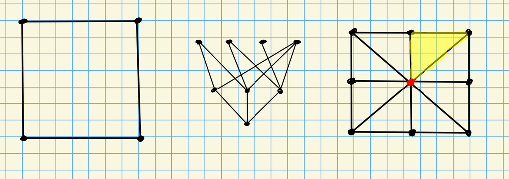

Note that one can take the geometric realization of a category by using the nerve to first produce a poset.

With the right choices, there exists a continuous map ${ {\left\lvert {I} \right\rvert} } \to I$ where $I$ is given the order topology. Pulling back sheaves on the latter yields constructible sheaves on convex objects, which are locally constant on the interior components.

A first version of the Zariski topology: let $k = \mkern 1.5mu\overline{\mkern-1.5muk\mkern-1.5mu}\mkern 1.5mu \in \mathsf{Field}$ and let $R\in{\mathsf{Alg}}^{\mathrm{fg}}_{/ {k}}$ be of the form $R = k[x_1, \cdots, x_{n}]/\left\langle{f_a}\right\rangle$. We can consider $X\mathrel{\vcenter{:}}=\operatorname{mSpec}R \subseteq {\mathbb{A}}^n_{/ {k}}$ as the points $\mathbf{x}\in k{ {}^{ \scriptscriptstyle\times^{n} } }$ such that $f_a(\mathbf{x}) = 0$. Recall Noether’s theorem – the $f_a$ can be replaced with a finite collection. The closed subsets are of the form $V(g_b)$. Note that this is $T_1$ since points are closed: given $\mathbf{p} = {\left[ {p_0,\cdots, p_n} \right]}$, take $f(\mathbf{p}) = \prod_{i\leq n} (x-p_i)$ so that $V(f) = \left\{{\mathbf{p}}\right\}$. These points biject with maximal ideals in $R$.

An improved version of the Zariski topology: $X = \operatorname{Spec}R$, including prime ideals. The points are as before, and additionally for every irreducible subvariety $Z \subseteq X$, there is a generic point $\eta_Z$. This adds new points which can’t be described in coordinates.

Note that this generalizes to arbitrary (associative, commutative) rings. For rings that aren’t finitely generated, one loses the coordinate interpretation. These generally won’t embed into ${\mathbb{A}}^n_{/ {k}}$ for any $n$, but can be embedded into (say) ${\mathbb{A}}^1_{/ {R}}$. Use that a closed embedding $X\hookrightarrow Y$ corresponds precisely to a surjection of associated rings $R_Y \twoheadrightarrow R_X$.

## 3.2 Sheaves

Let $U \subseteq \Omega \subseteq {\mathbb{C}}$ and consider $C^0(\Omega, {\mathbb{C}}) \mathrel{\vcenter{:}}=\mathop{\mathrm{Hom}}_{\mathsf{Top}}(\Omega, {\mathbb{C}})$ – this forms a sheaf of abelian groups, ${\mathbb{C}}{\hbox{-}}$algebras, rings, sets, etc.

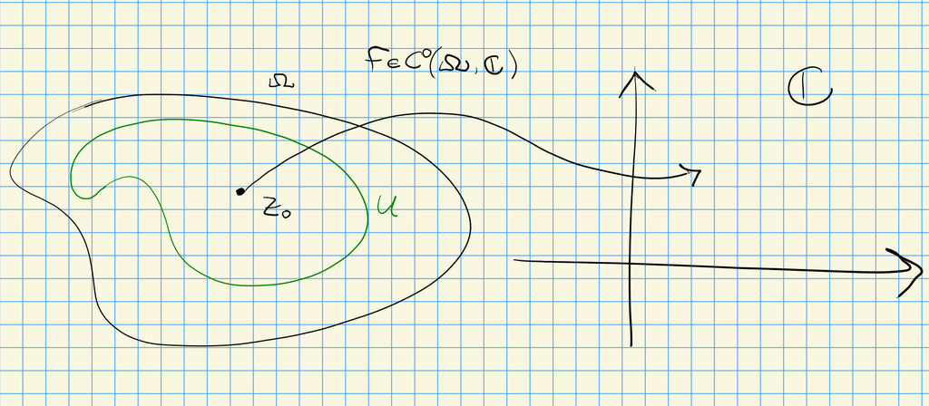

We’ll refer to this as ${\mathcal{O}}^\text{cts}_X$.

Some properties:

- For every $\iota: V \subseteq U \implies$ there is a restriction ma
  $$\begin{align*}
  {\mathcal{F}}(\iota): {\mathcal{F}}(U) &\to {\mathcal{F}}(V) \\
  f &\mapsto { \left.{{f}} \right|_{{V}} }
  .\end{align*}$$
- ${\mathcal{F}}({ \mathscr \emptyset^{\scriptscriptstyle \downarrow} }) = { \mathscr{1}_{\scriptscriptstyle \uparrow} }$, so e.g. for rings ${ \mathscr{1}_{\scriptscriptstyle \uparrow} }= \left\{{0}\right\}$ is the zero ring.
- (Sheaf 1, uniqueness): if ${\mathcal{U}}\rightrightarrows U$ and $s_1, s_2 \in {\mathcal{F}}({\mathcal{U}})$, then ${ \left.{{s_1}} \right|_{{U_i}} } = { \left.{{s_2}} \right|_{{U_i}} } \implies s_1 = s_2$.
- (Sheaf 2, existence): if $s_i\in {\mathcal{F}}(U_{ij})$ and ${ \left.{{s_1}} \right|_{{U_{ij}}} } = { \left.{{s_2}} \right|_{{U_{ij}}} }$, then there is a global section $s\in {\mathcal{F}}(U_1 \cup U_2)$.

Other examples of sheaves:

- ${\mathcal{O}}^\text{cts}_X$. One can check the sheaf properties directly.
- ${\mathcal{O}}^\text{hol}_X = {\mathcal{O}}^{\mathrm{an}}_X$ the holomorphic (complex differentiable) and thus analytic (locally equal to a convergent power series) functions on $X$.
- Given a fixed continuous map $f: Y\to X$, setting ${\mathcal{F}}(U) = \left\{{s: U\to Y}\right\}$ the set of continuous sections of $f$.

# 4 Wednesday, January 19

Some examples of sheaves:

- For $X \subseteq {\mathbb{C}}$ open, consider ${\operatorname{pr}}_1: X\times {\mathbb{C}}\to X$ and consider the space of continuous sections ${\mathcal{O}}_X^\text{cts}(U) \mathrel{\vcenter{:}}=\mathop{\mathrm{Hom}}_{\mathsf{Top}}(U, U\times {\mathbb{C}})$.

[figure not shown]

- Analytic functions ${\mathcal{O}}_X^{\mathrm{an}}$
- ${\mathcal{O}}_X^\text{cts}$ where ${\mathbb{C}}$ is given the discrete topology instead of the Euclidean topology. The opens in $U\times {\mathbb{C}}$ are of the form $U\times V$ for $V \subseteq {\mathbb{C}}$ any set at all:

[figure not shown]

- Constant sheaves $\underline{{\mathbb{C}}}(U)$ defined as the locally constant continuous ${\mathbb{C}}{\hbox{-}}$valued functions on $U$.

Recall the sheaf properties:

- $U\to F(U)$ and $\iota_{U, V} \mapsto \mathop{\mathrm{Res}}{F(V),F(U)}$.
- ${ \mathscr \emptyset^{\scriptscriptstyle \downarrow} }\mapsto F({ \mathscr \emptyset^{\scriptscriptstyle \downarrow} }) = { \mathscr{1}_{\scriptscriptstyle \uparrow} }$.
- Sheaf conditions:
  - Unique gluing: ${\mathcal{U}}\rightrightarrows X$ with $\mathop{\mathrm{Res}}_{X, U_i} s = \mathop{\mathrm{Res}}_{X, U_i} t \implies s=t\in F(X)$
  - Existence of gluing: $\left\{{s_i\in F(U_i)}\right\}$ with $\mathop{\mathrm{Res}}_{U_i, U_{ij}} s_i = \mathop{\mathrm{Res}}_{U_j, U_{ij}} s_j$ implies $\exists ! s\in F(X)$ with $\mathop{\mathrm{Res}}_{X, U_i} s = s_i$ for all $i$.

Recall that a **basis** of a topology is a collection $B_i$ where every $U \in \tau_X$ can be written as $\displaystyle\bigcup_{i\in I} B_i$ for some index set $I = I(X)$. Some examples:

- For $X\in {\mathsf{Alg}}{\mathsf{Var}}_{/ {k}}$, the distinguished opens $D(f) = \left\{{f\neq 0}\right\}$ and $Z(f) = \left\{{f=0}\right\}$.
- For $X =\operatorname{Spec}R \in {\mathsf{Aff}}{\mathsf{Sch}}_{/ {k}}$, take $D(f) = \left\{{{\mathfrak{p}}\in \operatorname{Spec}R {~\mathrel{\Big\vert}~}f\neq 0 \in R/{\mathfrak{p}}}\right\} = \left\{{{\mathfrak{p}}\in \operatorname{Spec}R {~\mathrel{\Big\vert}~}f\not\in {\mathfrak{p}}}\right\}$
  - Note that ${\mathcal{O}}_{\operatorname{Spec}R}(D(f)) = R \left[ { \scriptstyle { {f}^{-1}} } \right]$.

Formulate the sheaf condition with a basis instead of arbitrary opens.

> Hint: keep all of the same conditions, but since intersections may not be basic opens, write $B_\alpha \cap B_\beta = \cup_k B_k$.

Some upcoming standard notions:

- Stalks $F_x$
- Sheafification $F \mapsto F^+$

A less standard topic:

- The espace etale or “flat space” of $F$.

Recall that
$$\begin{align*}
F_x = \colim_{U\ni x} F(U) = \left\{{(U, s\in F(U))}\right\} / \sim && (U, s) \sim (V, t) \iff \exists W \supseteq U, V,\, \mathop{\mathrm{Res}}_{U, W}s = \mathop{\mathrm{Res}}_{V, W} t
.\end{align*}$$

Example: ${\mathcal{O}}_{X, p}^{\mathrm{an}}= \left\{{f(z) \mathrel{\vcenter{:}}=\sum c_k (z-p)^k {~\mathrel{\Big\vert}~}f\text{ has a positive radius of convergence} }\right\}$. Note that ${\mathcal{O}}_{X, p}^\text{cts}$ doesn’t have such a nice description, since continuous functions can be distinct while agreeing on a small neighborhood. Similarly, $\underline{{\mathbb{C}}}_p = {\mathbb{C}}$, since locally constant is actually constant on a small enough neighborhood.

Recall that morphisms of (pre)sheaves are natural transformations of functors. There is a forgetful functor $\mathop{\mathrm{Forget}}: {\mathsf{Sh}}(X) \to \underset{ \mathsf{pre} } {\mathsf{Sh} }(X)$, which has a left adjoint $({-})^+: \underset{ \mathsf{pre} } {\mathsf{Sh} }(X) \to {\mathsf{Sh}}(X)$. There is a description of $F^+(U)$ as collections of local compatible sections of $F$ modulo equivalence – compatibility here means that if ${\mathcal{U}}\rightrightarrows X$, then writing $U_{ij} = \cup V_k$ we have $\mathop{\mathrm{Res}}_{X, V_k}s_i = \mathop{\mathrm{Res}}_{X, V_k}s_j$ for all $i, j$.

# 5 Friday, January 21

Last time: definitions of presheaves and sheaves. There is an adjunction
$$\begin{align*}
\adjunction{({-})^+}{\mathop{\mathrm{Forget}}}{ \underset{ \mathsf{pre} } {\mathsf{Sh} }(X)}{{\mathsf{Sh}}(X)}
.\end{align*}$$

Recall that constant sheaves for $A\in \mathsf{D}$ are defined as $\underline{A}({-}) \mathrel{\vcenter{:}}=\mathop{\mathrm{Hom}}_{\mathsf{Top}}({-}, A)$ where $A$ is equipped with the discrete topology.

What is $\Gamma(\underline{A}, X)$ for $X\mathrel{\vcenter{:}}=\left\{{1/n}\right\}_{n\in {\mathbb{Z}}_{\geq 0}} \subseteq {\mathbb{R}}$? So $A(U) \neq A^{{\sharp}\pi_0 U}$ in general, since there may not be a notion of connected components for an arbitrary topological space.

Is it true that for any $X\in {\mathsf{Top}}$ there is a unique decomposition $X = {\textstyle\coprod}_{i\in I} U_i$ into connected components?

> Hint: form a poset of such decompositions ordered by refinement and apply Zorn’s lemma.

Consider the following poset with a prescribed topology, and applying some functor $F$:

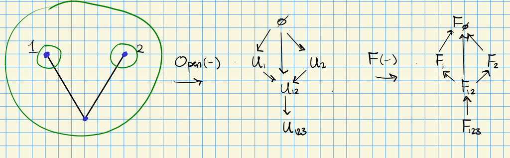

For this to be a sheaf, this forces

- $F(\emptyset) = { \mathscr{1}_{\scriptscriptstyle \uparrow} }$
- $F_{12} \cong F_1 \oplus F_2$ by the universal property of $\oplus$ if this is to be a sheaf.
- $F_3$ can be anything mapping to $F_{12}$.

What are the stalks?

- $F_x = F(X)$ for $x=3$, since $X$ is the smallest open set containing $3$.
- $F_{x_i} = F_i$ for $x_i = 1, 2$.

Consider now a poset in the order topology:

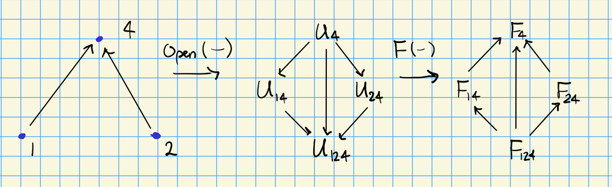

Now $F$ is a sheaf iff $F_{124}\cong F_1 { \underset{\scriptscriptstyle {F_4} }{\times} }F_2$ is the fiber product.

A map $\pi: Y\to X \in {\mathsf{Top}}$ is a **sheaf space** if it is a local homeomorphism, so every $y\in Y$ admits a neighborhood $U_y\ni y$ where ${ \left.{{\pi}} \right|_{{U_y}} }: U_y\to \pi(U_y)$ is a homeomorphism onto its image.

Some examples:

- $X\times A\to X$ for $A$ discrete.

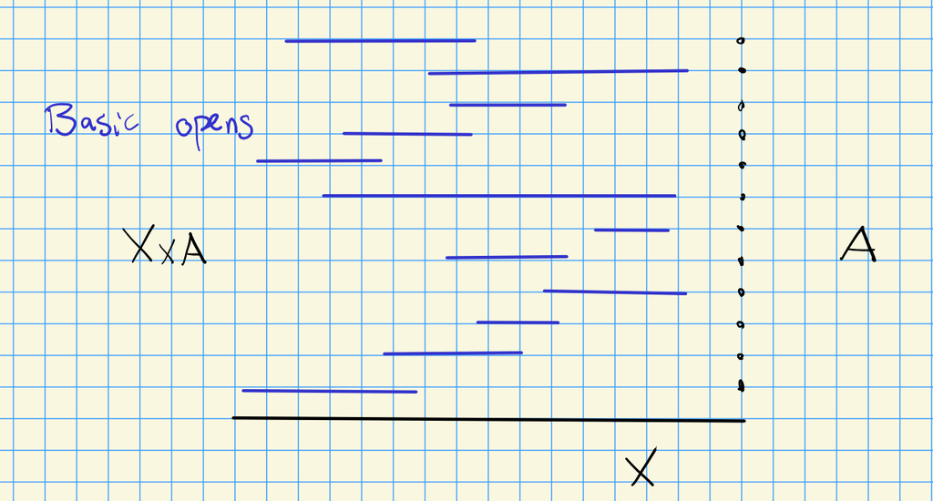

One possibility: “jumping.” Take $Y \mathrel{\vcenter{:}}= X\displaystyle\coprod_{X\setminus\left\{{0}\right\}} X$ for $X\subseteq {\mathbb{R}}$, which is a version of the line with two zeros. Then $Y\to X$ is a sheaf space, since it is a local homeomorphism.

The other possibility is “skipping”:

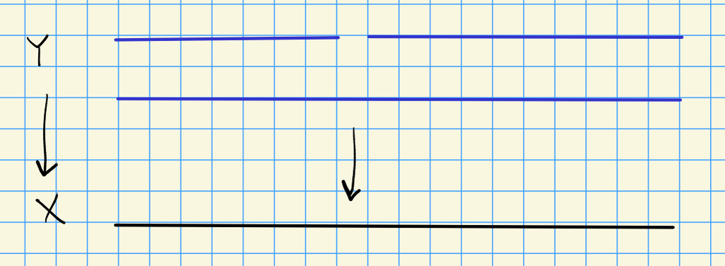

These two definitions of sheaf coincide: for new to old, given $Y \xrightarrow{\pi} X$ apply $\mathrm{ContSec}_\pi \subseteq \mathop{\mathrm{Hom}}_{\mathsf{Top}}(X, Y)$. In the other direction, define $Y\mathrel{\vcenter{:}}=\displaystyle\coprod_{x\in X} F_x$ and prove it is a local homeomorphism.

Next time: direct/inverse image, shriek functors, sheaves of modules.

# 6 Monday, January 24

Recall the definitions of presheaves and sheaves, and sheafification as an adjoint to $\mathop{\mathrm{Forget}}: {\mathsf{Sh}}(X)\to \underset{ \mathsf{pre} } {\mathsf{Sh} }(X)$. For $F\in \underset{ \mathsf{pre} } {\mathsf{Sh} }(X)$ we concretely construct its sheafification $F^+$ using the sheaf space $\pi: Y\mathrel{\vcenter{:}}=\displaystyle\coprod_{x\in X} F_x \to X$.

What are the sections of $\pi$? For a basic open $U \subseteq X \ni x$, the fiber is $\pi^{-1}(x) = F_x \mathrel{\vcenter{:}}=\colim_{V\ni x} F(V)$, which receives a map $\mathop{\mathrm{Res}}_{U, x}: F(U) \to F_x$. Writing $s\in F(U)$, define $s_x \mathrel{\vcenter{:}}=\mathop{\mathrm{Res}}_{U, x}(s)$, and set $W_{s, U} \mathrel{\vcenter{:}}=\left\{{s_x {~\mathrel{\Big\vert}~}x\in U}\right\}$ to be $\pi^{-1}(U)$. Then define $F^+$ to be the continuous sections of $Y \xrightarrow{\pi} X$. What does such a section look like? For $t:U\to \pi^{-1}(U)$ and $x\in U$, the vertical fiber is $F_x$. For a basic open $V\ni X$ in the base, there is a basic open $W_{s, V}$ in $Y$ for $s\in F(V)$:

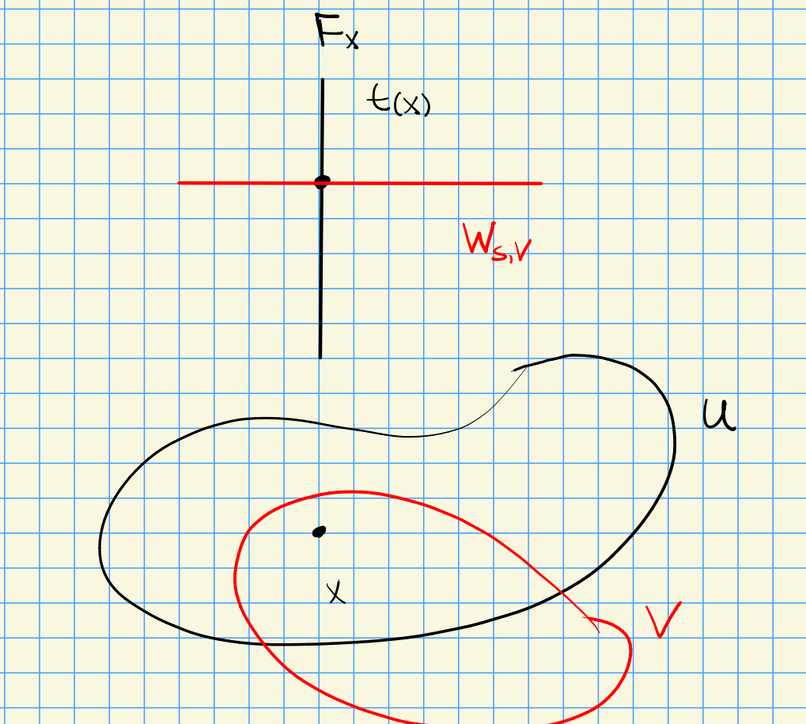

There are maps $s_{ij}: U_{ij}\to \pi^{-1}(U_{ij})$, but note that $\mathop{\mathrm{Res}}(U_i, U_{ij}) s_i$ does not necessarily equal $\mathop{\mathrm{Res}}(U_j,U_{ij}) s_j$ in $F(U_{ij})$ – instead, there is an open cover $U_{ij} = \displaystyle\bigcup V_{\alpha}$ with $\mathop{\mathrm{Res}}(U_i, V_\alpha) s_i = \mathop{\mathrm{Res}}(U_j, V_\alpha) s_j$ for each $\alpha$.

> Todo

For $f\in {\mathsf{Top}}(X, Y)$ we have the following constructions:

- The direct image $f_*: {\mathsf{Sh}}(X) \to {\mathsf{Sh}}(Y)$, which is easy with the sheaf definition, and
- The inverse image $f^{-1}: {\mathsf{Sh}}(Y)\to {\mathsf{Sh}}(X)$ which is easier with the sheaf space definition.

Recall the definition of a morphism of sheaves as a natural transformation.

For sheaves of abelian groups and $\phi: F\to G$ a morphism of sheaves, there are notions of $\ker \phi, \operatorname{coker}\phi, \operatorname{im}\phi$, and extension of a sheaf by zero.

To show these exist as presheaves, one only has to show existence of the following blue morphisms of abelian groups:

[figure not shown]

> Link to Diagram

Write $(\operatorname{coker}\phi)^-$ and $(\operatorname{im}\phi)^-$ for these presheaves.

$\ker \phi$ is a sheaf.

Axiom 1: use that $F$ is a sheaf and $\ker \phi_U \subseteq F(U)$ can be viewed as an inclusion. Axiom 2: write $s_i\in \ker \qty{F(U_i) \xrightarrow{\phi_{U_i}} F(U_j) }$, then there exists a unique $s\in F(U)$. Then check that $s\in \ker\qty{F(U) \to G(U)}$ by noting that if $s\mapsto t$ then ${ \left.{{t}} \right|_{{U_i}} } = 0$ for all $i$, making $t\equiv 0$ by the sheaf property of $G$.

Define
$$\begin{align*}
\operatorname{coker}\phi &\mathrel{\vcenter{:}}=( (\operatorname{coker}\phi)^-)^+ \\
\operatorname{im}\phi &\mathrel{\vcenter{:}}=( (\operatorname{im}\phi)^-)^+
.\end{align*}$$

Take $X = {\mathbb{C}}$ and consider $\exp: \mathop{\mathrm{Hol}}(X) \to G$ the sheaf of nowhere zero holomorphic functions. Then on $U_i \in {\mathbb{C}}\setminus\left\{{0}\right\}$, take $z\in G$. Then $z = \exp(f_i)$ in each $U_i$ with $f_i \in \mathop{\mathrm{Hol}}(X)$, so $f_i = \log(z)$ locally and $z = \exp(\log z)$, but there is no global $f\in \mathop{\mathrm{Hol}}(X)$ with $\exp(f) = z$. So $z\in \ker \phi_i(\mathop{\mathrm{Hol}}(U_i) \to G(U_i))$ but $z\not \in \ker \exp$. For the same reason, $z = 0$ in $\operatorname{coker}\phi_i$ since it’s locally in the image. but $z\neq 0 \in \operatorname{coker}\exp$ since it’s not globally in the image.

# 7 Wednesday, January 26

Recall last time: presheaf vs sheaf properties, images, kernel, cokernel. We can state the uniqueness sheaf axiom as the following: if $s\in F(U)$ with ${ \left.{{s}} \right|_{{U_i}} } = 0$ for ${\mathcal{U}}\rightrightarrows U$, then $s = 0$ in $F(U)$.

- ${\mathcal{F}}\mathrel{\vcenter{:}}=(\operatorname{im}\phi)^-$ satisfies uniqueness.
- ${\mathcal{G}}\mathrel{\vcenter{:}}=(\operatorname{coker}\phi)^-$ satisfies existence.
- ${\mathcal{F}}$ fails existence $\iff {\mathcal{G}}$ fails uniqueness
- ${\mathcal{F}}$ fails uniqueness iff ${\mathcal{G}}$ fails existence.

The presheaf image and cokernel can sometimes fail to be a sheaf: use $\mathop{\mathrm{Hol}}(X) \xrightarrow{\exp} \mathop{\mathrm{Hol}}(X)^{\times}$. The kernel presheaf $(\ker \phi)^-$ is already a sheaf.

Show the following:

- A sheaf ${\mathcal{F}}$ is the zero sheaf iff ${\mathcal{F}}_p =0$ for all $p$.
- $\ker(\phi)_p = \ker(\phi_p)$, which is $\ker({\mathcal{F}}_p \xrightarrow{\phi_p} {\mathcal{G}}_p)$ the kernel of the induced map.
- $\operatorname{coker}(\phi)_p = \operatorname{coker}(\phi_p) \mathrel{\vcenter{:}}=\operatorname{coker}({\mathcal{F}}_p \xrightarrow{\phi_p} {\mathcal{G}}_p)$.
- $\phi: {\mathcal{F}}\to {\mathcal{G}}$ is injective iff $\phi_p: {\mathcal{F}}_p \to {\mathcal{G}}_p$ is injective for all $p$.
- $\phi: {\mathcal{F}}\to {\mathcal{G}}$ is surjective iff $\phi_p: {\mathcal{F}}_p \to {\mathcal{G}}_p$ is surjective for all $p$.

Hints:

- Suppose $s\neq 0$ in $F(U)$, does there exist a $p$ with $s_p = 0$?
- Use that $s_p \in (\ker \phi)_p$ can be regarded as $s\in \ker(F(V) \to G(V))$ mod equivalence.

If there exists an injective morphism $\phi:{\mathcal{F}}\to {\mathcal{G}}$, we regard ${\mathcal{F}}\leq {\mathcal{G}}$ as a **subsheaf** and define the **quotient sheaf** ${\mathcal{F}}/{\mathcal{G}}\mathrel{\vcenter{:}}=\operatorname{coker}({\mathcal{F}}\xrightarrow{\phi} {\mathcal{G}})$.

Show by example that $({\mathcal{F}}/{\mathcal{G}})^-$ need not be a sheaf.

Note that for $\phi: {\mathcal{F}}\to {\mathcal{G}}$, the image $\operatorname{im}\phi$ is a secondary notion in additive categories, and can instead be defined as either

- $\operatorname{coker}(\ker \phi \to {\mathcal{F}})$
- $\ker({\mathcal{G}}\to \operatorname{coker}\phi)$

These need not coincide in general.

Defining the direct image: easier using the sheaf axioms. For $f\in {\mathsf{Top}}(X, Y)$, define $f_*: {\mathsf{Sh}}(X) \to {\mathsf{Sh}}(Y)$ by
$$\begin{align*}
f_* {\mathcal{F}}(U) \mathrel{\vcenter{:}}={\mathcal{F}}(f^{-1}(U)), \qquad \in {\mathsf{Sh}}(Y) \text{ for } {\mathcal{F}}\in {\mathsf{Sh}}(X)
.\end{align*}$$

For the preimage: easier to use the espace étalé. As a special case, consider $\iota: S \hookrightarrow Y$ where $S$ is a subspace of $Y$ (with the subspace topology). Then for ${\mathcal{F}}\in {\mathsf{Sh}}(Y)$, we can now define sections not only on open subsets $U$ but arbitrary subsets $S$ as
$$\begin{align*}
{\mathcal{F}}(S) \mathrel{\vcenter{:}}=(\iota^{-1}{\mathcal{F}})(S)
.\end{align*}$$

# 8 Friday, January 28

Last time:

- Morphisms of sheaves $\phi$,
- $\ker \phi$ (already a sheaf),
- $(\operatorname{im}\phi)^-, (\operatorname{coker}\phi)^-$ (need to sheafify),
  - All defined to commute with taking stalks: $(\ker \phi)_p = \ker(\phi_p)$, etc
- $(\operatorname{im}\phi)^-$ may fail the existence axioms for sheaves, using $\exp: {\mathcal{O}}^{\mathrm{an}}\to ({\mathcal{O}}^{\mathrm{an}})^{\times}$ for $X$ a complex analytic space,
- $(\operatorname{coker}\phi)^-$ may fail the uniqueness axioms for sheaves,
- $(\operatorname{im}\phi)^-$ satisfies existence $\iff (\operatorname{coker}\phi)^-$ satisfies uniqueness,
- For ${\mathcal{F}}\hookrightarrow{\mathcal{G}}$ injective, the presheaf quotient $({\mathcal{G}}/{\mathcal{F}})^-$ may fail to be a sheaf.

For $X\in {\mathsf{Alg}}{\mathsf{Var}}_{/ {k}}$ for $k= { \mkern 1.5mu\overline{\mkern-1.5muk\mkern-1.5mu}\mkern 1.5mu }$, let ${\mathcal{O}}_X$ be its regular algebraic functions. Take $X = {\mathbb{P}}^1$ and $U \mathrel{\vcenter{:}}={\mathbb{A}}^1\setminus\left\{{{\operatorname{pt}}}\right\} \subseteq {\mathbb{A}}^1 \subseteq {\mathbb{P}}^1\setminus\left\{{a_1,\cdots, a_k}\right\}$. Then ${\mathcal{O}}_X(U) = k[x] \left[ { \scriptstyle { {f}^{-1}} } \right]$ for $f(x) \mathrel{\vcenter{:}}=\prod (x-a_k)$, ${\mathcal{O}}_X(X) = k$, $K_X(U) = k(x)$, and $K_X^{\times}(U) = k(x)\setminus\left\{{0}\right\}$ if $U \neq \emptyset$. Define **Cartier divisors** as global sections of the sheaf $\mathop{\mathrm{Cart}}\operatorname{Div}\mathrel{\vcenter{:}}= K_X^{\times}/{\mathcal{O}}_X^{\times}$. Recall that Weil divisors are finite sums of codimension 1 subvarieties, and these notions coincide for nonsingular varieties.

For $p\in {\mathbb{A}}^1 \subseteq {\mathbb{P}}^1$, we have
$$\begin{align*}
(K_X^{\times}/{\mathcal{O}}_X^{\times})_p
= {K_{X, p} \over {\mathcal{O}}_{X, p}}
= {k(x) \over \left\{{f/g {~\mathrel{\Big\vert}~}f(p)\neq 0 , g(p) \neq 0}\right\}}
\cong {\mathbb{Z}}
,\end{align*}
using that any element in the quotient can be written as \(h(x) = (x-p)^n g(x)\) for some \(g\in {\mathcal{O}}_{X, p}^{\times}\). Here \(\mathop{\mathrm{Cart}}\operatorname{Div}(X) = \sum n_p P\) are all finite sums with \(n_p\in {\mathbb{Z}}\). The claim is that sheaf existence fails for this quotient – there are local sections that do not glue. Here$$

- $K^{\times}({\mathbb{P}}^1) = k(x)^{\times}$
- ${\mathcal{O}}^{\times}({\mathbb{P}}^1) = k^{\times}$
- $K^{\times}({\mathbb{P}}^1)/{\mathcal{O}}^{\times}({\mathbb{P}}^1) = {k(x)^{\times}\over k^{\times}}$

For any $s$ in the quotient, we can associated $(s)_0 - (s)_\infty = \sum n_p P$, but not every Cartier divisor is of this form – these are the *principal* divisors. This form a group ${\operatorname{Pic}}(X) = \mathop{\mathrm{Cart}}\operatorname{Div}(X) / \mathop{\mathrm{Prin}}\mathop{\mathrm{Cart}}\operatorname{Div}(X)$, which may not be trivial. This proof generalizes to locally Noetherian schemes, not necessarily reducible, with no embedded components.

Note that ${\operatorname{Pic}}(X)$ is also the group of invertible sheaves on $X$, and for irreducible algebraic varieties these coincide. Use the SES $0\to {\mathcal{O}}^{\times}\to K^{\times}\to K^{\times}/{\mathcal{O}}^{\times}\to 0$ to obtain
$$\begin{align*}
1 \to H^0({\mathcal{O}}^{\times}) \to H^0(K^{\times}) \to \mathop{\mathrm{Prin}}\mathop{\mathrm{Cart}}\operatorname{Div}(X) \to H^1({\mathcal{O}}^{\times})\cong \text{invertible sheaves}/\sim \to 0,
,\end{align*}
where \(H^1(K^{\times})\) vanishes since it’s a constant sheaf on an irreducible scheme in the Zariski topology.$$

$(\operatorname{im}\phi)^-$ satisfies existence $\iff (\operatorname{coker}\phi)^-$ satisfies uniqueness.

$\implies$: Let $s\in \operatorname{coker}(F(U) \to G(U))$ and write $U = \cup U_i$. We want to show that $s_{U_i}$ implies $s\in \operatorname{coker}(F(U_i) \to G(U_i))$ for all $i$. Note that $s = 0$ in $\operatorname{coker}(F(U) \to G(U))$ iff $s\in \operatorname{im}(F(U) \to G(U))$

# 9 Monday, January 31

Direct image sheaf: for ${\mathcal{F}}\in {\mathsf{Sh}}(X), {\mathcal{G}}\in {\mathsf{Sh}}(Y), f\in {\mathsf{Top}}(X, Y)$, the $f_* \in [{\mathsf{Sh}}(X), {\mathsf{Sh}}(Y)]$ is defined by $f_* {\mathcal{F}}(U) \mathrel{\vcenter{:}}={\mathcal{F}}(f^{-1}U)$. The inverse image functor $f^{-1}\in [{\mathsf{Sh}}(Y), {\mathsf{Sh}}(X)]$ is slightly more complicated. An easy case: if $\iota: S \hookrightarrow Y$ is a subspace, then it is just restriction: $(\iota^{-1}G)(S) \mathrel{\vcenter{:}}= G(S)$.

Idea for sheaf space: there are strictly horizontal neighborhoods as the homeomorphic preimages of small opens in the base. So for $\text{Ét}_{{\mathcal{G}}} \xrightarrow{\pi} Y$ the sheaf space of ${\mathcal{G}}$, define the inverse image as
$$\begin{align*}
\text{Ét}_{\iota^{-1}{\mathcal{G}}} \mathrel{\vcenter{:}}=\pi^{-1}(S) \subseteq \text{Ét}_{{\mathcal{G}}}
,\end{align*}
and define a basis of sections in the following way: for \(s\in {\mathcal{G}}(U)\), set \(t(U) \mathrel{\vcenter{:}}= s(U) \cap\pi^{-1}(S) \in \text{Ét}_{{\mathcal{G}}}\) to be sections of \(\text{Ét}_{\iota^{-1}{\mathcal{G}}}\). Declare these to be a basis of opens, i.e. take the subspace topology for \(\pi^{-1}(S) \subseteq \text{Ét}_{{\mathcal{G}}}\) in the sheaf topology on the total space. More generally, for \(f\in {\mathsf{Top}}(X, Y)\), set
\begin{align*}
\text{Ét}_{f^{-1}{\mathcal{G}}} \mathrel{\vcenter{:}}=\text{Ét}_{\mathcal{G}}{ \underset{\scriptscriptstyle {Y} }{\times} } X
.\end{align*}$$

The fibers are identical:

[figure not shown]

> Link to Diagram

The topology on $\text{Ét}_{f^{-1}{\mathcal{G}}}$ is the coarsest topology for which $\pi^*$ and $f^*$ are continuous. This is generated by $\qty{ f^{-1}(s)(f^{-1}U)} \cap(\pi^*)^{-1}(W)$ for $W \subseteq X$ open. Define $f^{-1}(s) \in f^{-1}{\mathcal{G}}(f^{-1}(U)) \mathrel{\vcenter{:}}=(f^{-1}U){ \underset{\scriptscriptstyle {U} }{\times} } s(U)$. This makes the pullback continuous both vertically and horizontally.

$$\begin{align*}
(f^{-1}{\mathcal{G}})_y = {\mathcal{G}}_{f(y)}
.\end{align*}$$

$$\begin{align*}
f^{-1}{\mathcal{G}}\mathrel{\vcenter{:}}=\qty{V\mapsto \colim_{U, V \subseteq f^{-1}(U)} {\mathcal{G}}(U)}^+
.\end{align*}$$

How to prove this coincides with the previous definition:

- Show the stalks are isomorphic,
- Show that there is a map of presheaves $(f^{-1}{\mathcal{G}}) \to f^{-1}{\mathcal{G}}$,
- Show that the map induces an isomorphism on stalks, and lift using the universal property of sheafification.

Try to prove this by commuting limits.

Recall that $K^{\times}/{\mathcal{O}}^{\times}\cong \bigoplus _{x\in X} (\iota_*)_* \iota_*^{-1}\underline{{\mathbb{Z}}}$ which had stalks ${\mathbb{Z}}$ but was not constant – check that the local sections differ.

For $S\hookrightarrow Y$, does every section of ${\mathcal{G}}$ over $S$ extend to $Y$?

# 10 Wednesday, February 02

Extending by zero: for $i: U \hookrightarrow X$ an open subspace and ${\mathcal{F}}\in {\mathsf{Sh}}(U)$, define $i_!{\mathcal{F}}\in {\mathsf{Sh}}(X)$. If the target category has a zero object, define this in the sheaf space by extending the zero section:

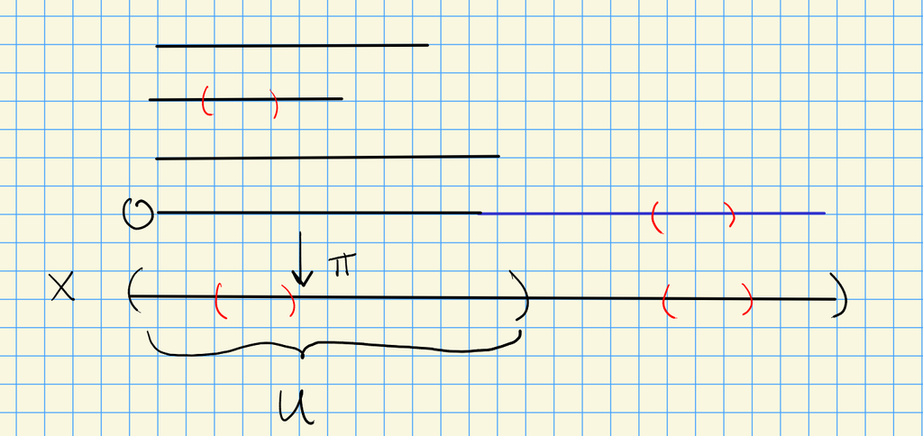

Thus $\text{Ét}_{i_! {\mathcal{F}}} = \text{Ét}_{{\mathcal{F}}} {\textstyle\coprod}\left\{{s_0}\right\}$ for $s_0$ the zero section.

Define a presheaf are given by
$$\begin{align*}
(i_! {\mathcal{F}})^-(V) =
\begin{cases}
F(V) & V \subseteq U
\\
0 & \text{else}.
\end{cases}
.\end{align*}$$

Sheafifying produces an equivalent sheaf, i.e. $(i_! {\mathcal{F}})^{-+} \cong i_! {\mathcal{F}}$.

Idea: produce a map $(i_! {\mathcal{F}})^- \to i_! {\mathcal{F}}$ and show it is an isomorphism on stalks. What are the stalks? By the sheaf space definition,
$$\begin{align*}
(i_! {\mathcal{F}})_p
=
\begin{cases}
{\mathcal{F}}_p & p\in U
\\
0 & \text{else}.
\end{cases}
.\end{align*}
On the other hand, \((i_! {\mathcal{F}})_p^- = \colim_{V\ni p} {\mathcal{F}}(V)\), but this limit can be taken over the system of open sets \(V \subseteq U\), so it yields \({\mathcal{F}}_p\).$$

Consider $X = U {\textstyle\coprod}Z$ with $U$ open and $Z$ closed. Let $U \xhookrightarrow{i} X$ and $Z\xhookrightarrow{j} X$, and consider $i_* { \left.{{{\mathcal{F}}}} \right|_{{U}} }$ and $j_* { \left.{{{\mathcal{F}}}} \right|_{{U}} }$. There is a SES
$$\begin{align*}
0 \to i_! { \left.{{{\mathcal{F}}}} \right|_{{U}} } \to {\mathcal{F}}\to j_* { \left.{{{\mathcal{F}}}} \right|_{{Z}} }\to 0
.\end{align*}$$

The sheaf $i_!{ \left.{{{\mathcal{F}}}} \right|_{{U}} }$ is a subsheaf of ${\mathcal{F}}$, and $j_*{ \left.{{{\mathcal{F}}}} \right|_{{Z}} }$ is a quotient.

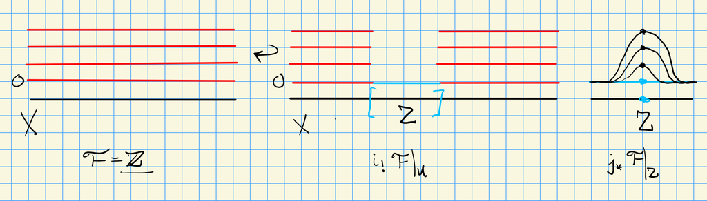

Here $\text{Ét}_{\underline{{\mathbb{Z}}}} = \displaystyle\coprod_{n\in {\mathbb{Z}}} X$, and $\text{Ét}_{j_* { \left.{{\underline{{\mathbb{Z}}}}} \right|_{{Z}} }} X$ glued along $X\setminus Z$. So $i_! { \left.{{{\mathcal{F}}}} \right|_{{U}} } \hookrightarrow{\mathcal{F}}$. It’s important that $Z$ is closed here to get a surjection, since then any point in its complement has a neighborhood $V$ missing $Z$ entirely and $(i_! {\mathcal{F}})^-(V) = 0$. Checking the stalks:

|  | ${\mathcal{F}}$ | $i_! { \left.{{{\mathcal{F}}}} \right\|_{{U}} }$ | $j_* { \left.{{{\mathcal{F}}}} \right\|_{{V}} }$ |
| --- | --- | --- | --- |
| $p\in U$ | ${\mathcal{F}}_p$ | ${\mathcal{F}}_p$ | 0 |
| $p\in Z$ | ${\mathcal{F}}_p$ | 0 | ${\mathcal{F}}_p$ |

Let $X\in {\mathsf{Alg}}{\mathsf{Var}}_{/ {k}}$, e.g. $X={\mathbb{P}}^1$, let $Z \subseteq X$ be closed, and let ${\mathcal{F}}\mathrel{\vcenter{:}}={\mathcal{O}}_X$. There is a SES $0\to I_Z \to {\mathcal{O}}_X\to {\mathcal{O}}_Z \to 0$.

Note that we have adjunctions
$$\begin{align*}
\adjunction{f^{-1}}{f_*}{{\mathsf{Sh}}X}{{\mathsf{Sh}}Y} \\
\adjunction{i_!}{{ \left.{{{-}}} \right|_{{U}} }}{{\mathsf{Sh}}?}{{\mathsf{Sh}}?} \\
\adjunction{j_*}{{ \left.{{{-}}} \right|_{{Z}} } }{{\mathsf{Sh}}?}{{\mathsf{Sh}}?}
.\end{align*}$$

# 11 Friday, February 04

Last time: extension by zero, inverse image, pushforward on closed sets and adjunctions.
$$\begin{align*}
f\in \mathop{\mathrm{Hom}}_{{\mathsf{Top}}}(X, Y) \leadsto \mathop{\mathrm{Hom}}_{{\mathsf{Sh}}(X)}(f^{-1}{\mathcal{G}}, {\mathcal{F}}) \cong \mathop{\mathrm{Hom}}_{{\mathsf{Sh}}(Y)}({\mathcal{G}}, f_* {\mathcal{F}})
.\end{align*}$$

Pushing forward open sets is not generally a good idea! Take $X = {\mathbb{R}}^{\mathrm{zar}}$, $Z = \left\{{{\operatorname{pt}}}\right\}, U = X\setminus Z$. Then $(i_* \underline{{\mathbb{Z}}_U})_p = {\mathbb{Z}}{ {}^{ \scriptscriptstyle\oplus^{2} } }$ if $p= {\operatorname{pt}}$, since any neighborhood of $p$ pulls back to two connected components.

Consider $U \xhookrightarrow{i} X$ with $U$ open and $Z \xhookrightarrow{j} X$ with $Z$ closed, then for ${\mathcal{F}}\in {\mathsf{Sh}}(X), {\mathcal{H}}\in {\mathsf{Sh}}(U), {\mathcal{G}}\in {\mathsf{Sh}}(Z)$,
$$\begin{align*}
\mathop{\mathrm{Hom}}_{{\mathsf{Sh}}(Z)}( { \left.{{{\mathcal{F}}}} \right|_{{Z}} }, {\mathcal{G}}) & { \, \xrightarrow{\sim}\, }\mathop{\mathrm{Hom}}_{{\mathsf{Sh}}(X)}({\mathcal{F}}, j_* {\mathcal{G}}) \\
\mathop{\mathrm{Hom}}_{{\mathsf{Sh}}(U)}({\mathcal{H}}, { \left.{{{\mathcal{F}}}} \right|_{{U}} } ) & { \, \xrightarrow{\sim}\, }\mathop{\mathrm{Hom}}_{{\mathsf{Sh}}(X)}(i_! {\mathcal{H}}, {\mathcal{F}})
.\end{align*}$$

We’ll consider $(X, {\mathcal{O}}_X) \in \mathsf{Loc}\mathsf{RingSp}_{/ {\mathsf{CRing}}}$ with sheaves of reduced commutative rings – note that noncommutative rings are also important, e.g. $\operatorname{GL}_n$ or ${\mathfrak{gl}}_n$.

Common examples of locally ringed spaces:

- $(X, \underline{R})$ any space with a constant sheaf.
- $(X, {\mathcal{F}})$ for ${\mathcal{F}}\mathrel{\vcenter{:}}={\mathcal{O}}_X^\text{cts}\mathrel{\vcenter{:}}=\mathop{\mathrm{Hom}}_{\mathsf{Top}}({-}, {\mathbb{R}})$.
- $(X, {\mathcal{O}}_X^{\mathrm{zar}})$ for $X\in {\mathsf{Aff}}{\mathsf{Alg}}{\mathsf{Var}}_{/ {k}}$ and ${\mathcal{O}}_X^{\mathrm{zar}}$ the sheaf of Zariski-regular functions. In this case, for $k= { \mkern 1.5mu\overline{\mkern-1.5muk\mkern-1.5mu}\mkern 1.5mu }$, these are of the form $\operatorname{mSpec}R \subseteq {\mathbb{A}}^n_{/ {k}}$ for $R\mathrel{\vcenter{:}}= k[x_1, \cdots, x_{n}]/\left\langle{f}\right\rangle$. Recall distinguished opens are $D(g) = \left\{{g\neq 0}\right\}$ for $g\in k[x_1, \cdots, x_{n}]$, and sections are ${\mathcal{O}}_X(D(g)) = R \left[ { \scriptstyle { {g}^{-1}} } \right]$ are functions $\rho: X\to k$ of the form $\rho = h/g^k$ for some regular function $h$. It’s a theorem that these assemble to a sheaf.

Define algebraic varieties as locally ringed spaces $(X, {\mathcal{O}}_X)$ that

1. $X$ is covered by finitely affine algebraic varieties, so $X = \cup U_i$ with $(U_i, {\mathcal{O}}_{U_i})$ affine algebraic, and
2. $X$ is separated, i.e. $X \xrightarrow{\Delta_X} X{ {}^{ \scriptscriptstyle{ \underset{\scriptscriptstyle {X} }{\times} }^{2} } }$ is closed.

Note that affine and even quasiprojective schemes are automatically separated. We require the separated condition here to rule out things like ${\mathbb{A}}^1$ with two origins, i.e. $X \mathrel{\vcenter{:}}={\mathbb{A}}^1{ \displaystyle\coprod_{{\mathbb{A}}^1\setminus\left\{{0}\right\}} }{\mathbb{A}}^1$.

Affine schemes: for $R\in \mathsf{CRing}$, take $X\mathrel{\vcenter{:}}=\operatorname{Spec}R$ with a basis $D(g)$ and define a presheaf by ${\mathcal{O}}_X(D(g)) = R \left[ { \scriptstyle { {g}^{-1}} } \right]$. It’s a theorem that this yields a sheaf.

For $(X, {\mathcal{O}}_X) \in \mathsf{Loc}\mathsf{RingSp}$, ${\mathcal{F}}$ is a **sheaf of ${\mathcal{O}}_X{\hbox{-}}$modules** iff every section $F(U)$ is an ${\mathcal{O}}_X(U){\hbox{-}}$module and restriction is compatible with the module structures in the sense that ${ \left.{{(rm)}} \right|_{{V}} } = { \left.{{r}} \right|_{{V}} } { \left.{{m}} \right|_{{V}} }$:

[figure not shown]

> [Link to Diagram](https://q.uiver.app/?q=WzAsNixbMSwwLCJcXG1jZihVKSJdLFsxLDIsIlxcbWNmKFYpIl0sWzMsMCwiXFxPT19YKFUpIl0sWzMsMiwiXFxPT19YKFYpIl0sWzAsMCwibVxcaW4iXSxbNCwwLCJcXG5pIHIiXSxbMCwxXSxbMCwyXSxbMSwzXSxbMiwzXV0=)

Any constant sheaf $\underline{M}$ for $M\in {\mathsf{R}{\hbox{-}}\mathsf{Mod}}$.

An ${\mathcal{O}}_X{\hbox{-}}$module is

- **Quasicoherent** if locally ${\mathcal{F}}\cong \underline{M}$ (there exists an open cover $X = \cup U_i$ with ${ \left.{{{\mathcal{F}}}} \right|_{{U_i}} } \cong \underline{M_{U_i}}$),
- **Coherent** iff ${\mathcal{F}}$ is quasicoherent and $M \in {\mathsf{R}{\hbox{-}}\mathsf{Mod}}^{\mathrm{fg}}$ and $X$ is locally Noetherian.

Of an ${\mathcal{O}}_X{\hbox{-}}$module for a constant sheaf: $M = R/p$ for ${\mathcal{O}}_X = \underline{R}$.

For complex analytic varieties, take $(X, {\mathcal{O}}_X^{\mathrm{an}})$ so ${\mathcal{O}}_X(U)$ are locally meromorphic functions regular on $U$, i.e. whose denominator does not vanish on $U$. This is the setting where Cartan, Serre, etc defined original notions of coherence, and e.g. Serre vanishing, and scheme theory is developed by analogy to this situation. Here, ${\mathcal{F}}$ is a **coherent** sheaf iff ${\mathcal{F}}$ is a sheaf of ${\mathcal{O}}_X^{\mathrm{an}}{\hbox{-}}$modules and admits a presentation
$$\begin{align*}
{\mathcal{O}}_X^{\mathrm{an}}{ {}^{ \scriptscriptstyle\oplus^{m} } } \to {\mathcal{O}}_X^{\mathrm{an}}{ {}^{ \scriptscriptstyle\oplus^{n} } } \to {\mathcal{F}}\to 0
.\end{align*}$$

Next time: locally free, invertible, tensor, and hom.

# 12 Monday, February 07

Examples of sheaves:

- ${\mathcal{O}}_X^\text{cts}$ for $X\in {\mathsf{Top}}$, where ${\mathcal{O}}_X^\text{cts}({-}) = {\mathsf{Top}}({-}, {\mathbb{R}})$
- ${\mathcal{O}}_X^{{\mathsf{sm}}}({-}) = C^\infty({-}, {\mathbb{R}})$.
- ${\mathcal{O}}_X^{\text{hol}}({-}) = \mathop{\mathrm{Hol}}({-}, {\mathbb{C}})$
- ${\mathcal{O}}_X^{{\mathrm{an}}}({-}) \subseteq {\mathsf{Top}}({-}, {\mathbb{R}})$ the sheaf of analytic functions, those locally equal to power series.
- For $X\in {\mathsf{Alg}}{\mathsf{Var}}_{/ {k}}$, ${\mathcal{O}}_X({-}) = {\mathsf{Top}}(({-})^{\mathrm{zar}}, k)$ the Zariski-regular $k{\hbox{-}}$valued functions.

In all cases, ${\mathcal{O}}_X$ can be regarded as sheaves of *regular* sections to $X\times {\mathbb{A}}^1_{/ {k}} \xrightarrow{\pi} X$. Note that this doesn’t necessarily coincide with sections of the espace etale, since e.g. the fibers are ${\mathbb{A}}^1$ and not necessarily the stalks. For ${\mathcal{O}}{ {}^{ \scriptscriptstyle\oplus^{d} } }$, one instead takes $X\times {\mathbb{A}}^d_{/ {k}} \to X$.

A sheaf ${\mathcal{F}}\in {\mathsf{Sh}}(X)$ is **locally free** iff there exists an open cover ${\mathcal{U}}\rightrightarrows X$ with ${ \left.{{{\mathcal{F}}}} \right|_{{U_i}} } \cong {\mathcal{O}}_{U_i}{ {}^{ \scriptscriptstyle\oplus^{n} } }$. The quantity $n$ is the **rank** of ${\mathcal{F}}$. If $\operatorname{rank}{\mathcal{F}}= 1$, then ${\mathcal{F}}$ is **invertible**.

A **vector bundle** over $X$ is $V \xrightarrow{\pi} X$ with $\pi^{-1}(U_i) \cong U_i \times {\mathbb{A}}^r$. For $r=1$, this is a **line bundle**.

Maps between bundles are linear in the second coordinate.

Note that there is a correspondence between vector bundles and locally free sheaves. Consider the rank 1 case, matching invertible sheaves and line bundles. The necessary data:

- An open cover ${\mathcal{U}}\rightrightarrows X$, where ${\mathcal{U}}= \left\{{U_i}\right\}_{i\in I}$
- For all $i, j\in I$, transition functions $\phi_{ij}\in {\mathcal{O}}^{\times}(U_{ij}) = \mathop{\mathrm{Aut}}_{{\mathsf{{\mathcal{O}}_X}{\hbox{-}}\mathsf{Mod}}}(U_{ij})$.
- A cocycle condition: $\phi_{ii} = \operatorname{id}, \phi_{ij} = \phi_{ji}^{-1}$, and $\phi_{ij} \phi_{jk} \phi_{ki} =\operatorname{id}\in {\mathcal{O}}^{\times}(U_{ijk})$

Note that any morphism of sheaves ${\mathcal{O}}_V \to {\mathcal{O}}_V$ induces a morphism of ${\mathcal{O}}_V{\hbox{-}}$modules on global sections
$$\begin{align*}
{\mathcal{O}}_V(V) & { \, \xrightarrow{\sim}\, }{\mathcal{O}}_V(V) \in {\mathsf{{\mathcal{O}}_V}{\hbox{-}}\mathsf{Mod}} \\
1 &\mapsto \phi
,\end{align*}
and this being an isomorphism manes \(\phi\) is invertible. Note that these are not isomorphic as rings.$$

Write $Z_1({\mathcal{U}}; {\mathcal{O}}^{\times}) = \left\{{\phi_{ij} \in {\mathcal{O}}^{\times}(U_{ij}) {~\mathrel{\Big\vert}~}\cdots }\right\}$ for those $\phi_{ij}$ satisfying the conditions above, and $B_1({\mathcal{U}}; {\mathcal{O}}^{\times}) = \left\{{\phi_{ij} \in {\mathcal{O}}^{\times}(U_{ij}) {~\mathrel{\Big\vert}~}\phi_{ij} \sim \phi_{ij}{\psi_j \over \psi_i} }\right\}$ for any ${\psi_i \over \psi_j} \in \operatorname{GL}_1({\mathcal{O}}) \cong {\mathcal{O}}^{\times}$. More generally, we let $\phi_{ij} = \psi_j \phi_{ij} \psi_i^{-1}$ for $\psi_i, \psi_j \in \operatorname{GL}_n({\mathcal{O}})$.

Recall that for a given space $X$, the open covers of $X$ form a poset under refinement, where ${\mathcal{U}}\geq {\mathcal{V}}$ iff for every $U_i\in {\mathcal{U}}$ there is some $V_j \in {\mathcal{V}}$ with $U_i \supseteq V_j$. This yields a system of maps $Z^1({\mathcal{U}}; {\mathcal{O}}^{\times}) \to Z^1({\mathcal{V}}; {\mathcal{O}}^{\times})$ compatible with transition maps, so we define
$$\begin{align*}
{\check{H}}^1(X; {\mathcal{O}}_X^{\times}) \mathrel{\vcenter{:}}=\colim_{{\mathcal{U}}\rightrightarrows X} {\check{H}}^1({\mathcal{U}}; {\mathcal{O}}^{\times})
.\end{align*}$$

Compute ${\check{H}}^1({\mathbb{P}}^1; {\mathcal{O}}_{{\mathbb{P}}^1}^{\times})$ using an open cover by two sets.

# 13 Wednesday, February 09

Plan:

- $\mathop{\mathrm{Hom}}_{{\mathsf{Sh}}(X)}({-}, {-})$
- $\mathop{\mathrm{Hom}}_{{\mathsf{ {\mathcal{O}}_X}{\hbox{-}}\mathsf{Mod}}}({-}, {-})$
- $({-}) \otimes_{{\mathcal{O}}_X}({-})$

For $(X, {\mathcal{O}}_X)\in \mathsf{Loc}\mathsf{RingSp}$ and ${\mathcal{F}}, {\mathcal{G}}\in {\mathsf{Sh}}(X; {\mathsf{Ab}}{\mathsf{Grp}})$, define $\mathop{\mathrm{Hom}}_{{\mathcal{O}}_X}({\mathcal{F}}, {\mathcal{G}})$ to be natural transformations which are ${\mathcal{O}}_X{\hbox{-}}$linear. This forms an abelian group under pointwise operations, and more generally an ${\mathcal{O}}_X{\hbox{-}}$module since one can act on morphisms by global sections. There is a sheaf version, the local hom $\underline{\mathop{\mathrm{Hom}}}_{{\mathcal{O}}_X}({\mathcal{F}}, {\mathcal{G}})(U) \mathrel{\vcenter{:}}=\mathop{\mathrm{Hom}}_{{\mathcal{O}}_U}({\mathcal{F}}_U, {\mathcal{G}}_U)$ where we write ${\mathcal{F}}_U \mathrel{\vcenter{:}}={ \left.{{{\mathcal{F}}}} \right|_{{U}} }$.

This forms a sheaf of ${\mathcal{O}}_X{\hbox{-}}$modules.

Let
$$\begin{align*}
f_i\in \mathop{\mathrm{Hom}}_{{\mathcal{O}}_{U_i}}({\mathcal{F}}_{U_i}, {\mathcal{G}}_{U_i}) \\
f_j\in \mathop{\mathrm{Hom}}_{{\mathcal{O}}_{U_j}}({\mathcal{F}}_{U_j}, {\mathcal{G}}_{U_j})
.\end{align*}
If \({ \left.{{f_i}} \right|_{{U_{ij}}} } = { \left.{{f_j}} \right|_{{U_{ij}}} }\), then the claim is that there exists a unique \(F\in \mathop{\mathrm{Hom}}_{{\mathcal{O}}_{U_{ij}}}({\mathcal{F}}_{U_{ij}}, {\mathcal{G}}_{U_{ij}} )\). For \(V \subseteq X\), decompose as \(V = \displaystyle\bigcup_i U_i\).$$

If ${\mathcal{F}}\in {\mathsf{{\mathcal{O}}_X}{\hbox{-}}\mathsf{Mod}}^{{\mathrm{lf}}, \operatorname{rank}=r}$ and ${\mathcal{G}}\in {\mathsf{{\mathcal{O}}_X}{\hbox{-}}\mathsf{Mod}}^{{\mathrm{lf}}, \operatorname{rank}=s}$ then $\underline{\mathop{\mathrm{Hom}}}_{{\mathcal{O}}_X}({\mathcal{F}}, {\mathcal{G}})\in {\mathsf{{\mathcal{O}}_X}{\hbox{-}}\mathsf{Mod}}^{{\mathrm{lf}}, \operatorname{rank}= rs}$.

Choose trivializations ${\mathcal{F}}_{U_i} { \, \xrightarrow{\sim}\, }{\mathcal{O}}_{U_i}{ {}^{ \scriptscriptstyle\oplus^{r} } }$ and ${\mathcal{G}}_{U_i} { \, \xrightarrow{\sim}\, }{\mathcal{O}}_{U_i}{ {}^{ \scriptscriptstyle\oplus^{s} } }$. The claim is that $\underline{\mathop{\mathrm{Hom}}}_{{\mathcal{O}}_U}({\mathcal{O}}_U, {\mathcal{O}}_U) = {\mathcal{O}}_U$ for any ${\mathcal{O}}_U$. Given this, $\mathop{\mathrm{Hom}}_{{\mathcal{O}}_X}({\mathcal{O}}_X{ {}^{ \scriptscriptstyle\oplus^{r} } }, {\mathcal{O}}_X{ {}^{ \scriptscriptstyle\oplus^{s} } }) \cong \operatorname{Mat}_{r\times s}({\mathcal{O}}_X)$ split out as matrices. To prove this, just check on global sections that $\underline{\mathop{\mathrm{Hom}}}_{{\mathcal{O}}_X}({\mathcal{O}}_X, {\mathcal{O}}_X) \cong \mathop{\mathrm{Hom}}_{{\mathsf{R}{\hbox{-}}\mathsf{Mod}}}(R, R)\cong R$ for $R\mathrel{\vcenter{:}}={{\Gamma}\qty{R} }$.

Recall that ${\mathsf{Sh}}(X)^{{\mathrm{lf}}, \operatorname{rank}=1} \cong {\mathsf{Bun}}_{\operatorname{GL}}^{\operatorname{rank}= 1}$, i.e. we identify rank 1 locally free sheaves with line bundles. We can write $\mathop{\mathrm{Hom}}_{\mathcal{O}}({\mathcal{F}},{\mathcal{G}}) = \left\{{ {\phi_{ij} \over \psi_{ij} } {~\mathrel{\Big\vert}~}\phi_{ij} \in {\mathcal{O}}_X^{\times}(U_{ij}) \text{ satisfies the cocycle condition} }\right\}$. What are the transition functions?

We also define $\mathop{\mathrm{Hom}}_{\mathcal{O}}({\mathcal{F}}, {\mathcal{O}}) \mathrel{\vcenter{:}}={\mathcal{F}} {}^{ \vee }$, and there is a relation to ${\operatorname{Pic}}(X)$.

Note also that $\underline{\mathop{\mathrm{Hom}}}_{{\mathcal{O}}}({\mathcal{O}}, {\mathcal{F}}) \cong {\mathcal{F}}$, so global sections coincide with homs. This will be useful later when defining $H^*$ in terms of derived functors.

Define the tensor product of ${\mathcal{F}},{\mathcal{G}}\in {\mathsf{{\mathcal{O}}_X}{\hbox{-}}\mathsf{Mod}}$ as the sheafification of
$$\begin{align*}
({\mathcal{F}}\otimes_{{\mathcal{O}}_X} {\mathcal{G}})^- \mathrel{\vcenter{:}}= U\mapsto {\mathcal{F}}(U) \otimes_{{\mathcal{O}}_U} {\mathcal{G}}(U)
.\end{align*}$$

Note that there is a formula for stalks:
$$\begin{align*}
({\mathcal{F}}\otimes_{{\mathcal{O}}_X} {\mathcal{G}})_x = {\mathcal{F}}_x \otimes_{{\mathcal{O}}_x} {\mathcal{G}}_x
.\end{align*}
Moreover \({\mathcal{F}}\otimes_{{\mathcal{O}}_X} {\mathcal{G}}\in {\mathsf{{\mathcal{O}}_X}{\hbox{-}}\mathsf{Mod}}^{{\mathrm{lf}}, \operatorname{rank}= rs}\). This endows \({\mathsf{{\mathcal{O}}_X}{\hbox{-}}\mathsf{Mod}}\) with a symmetric monoidal structure with duals, so$$

- ${\mathcal{F}}\otimes_{{\mathcal{O}}_X }{\mathcal{F}} {}^{ \vee }\cong {\mathcal{O}}_X$
- ${\mathcal{O}}_X \otimes_{{\mathcal{O}}_X} {\mathcal{F}}\cong {\mathcal{F}}$

Recall that $f\in {\mathsf{Top}}(X, Y)$ for $X, Y\in {\mathsf{Aff}}{\mathsf{Sch}}$ induces $f^{-1}\in {\mathsf{Sh}}(X)(f^{-1}{\mathcal{O}}_Y, {\mathcal{O}}_X)$. For varieties, this is just given by pullback of regular functions. More generally, for $X, Y\in \mathsf{Loc}\mathsf{RingSp}$, define the **full pullback** $f^*$ as
$$\begin{align*}
f^*{\mathcal{F}}= f^{-1}{\mathcal{F}}\otimes_{f^{-1}{\mathcal{O}}_Y} {\mathcal{O}}_X
.\end{align*}$$

For the full pullback,
$$\begin{align*}
f^* {\mathcal{O}}_Y \cong {\mathcal{O}}_X
,\end{align*}
which is not true for \(f^{-1}\). This essentially follows from \(R \otimes_R S \cong S\).$$

Consider $f\in {\mathsf{Alg}_{/k} }(S, R)$ for $k=\mkern 1.5mu\overline{\mkern-1.5muk\mkern-1.5mu}\mkern 1.5mu$ where we only consider reduced algebra (no nonzero nilpotents). This induces maps $\tilde f: \operatorname{Spec}R\to \operatorname{Spec}S$ and $\tilde f': \operatorname{mSpec}R\to \operatorname{mSpec}S$. If ${\mathcal{A}}\in {\mathsf{Sh}}(X; {{{\mathcal{O}}_X}{\hbox{-}}\mathsf{Alg}})$, there are induced maps ${\mathcal{O}}_X(U) \to {\mathcal{A}}(U)$ and thus affine morphism $\pi: \operatorname{Spec}{\mathcal{A}}(U) \to U$ covering the affine open $U$.

- ${\mathcal{A}}= {\mathcal{O}}_X[x_1,\cdots, x_n]$ yields a trivial vector bundle $\operatorname{Spec}{\mathcal{A}}= X\times {\mathbb{A}}^n \to X$.
- For ${\mathcal{F}}\in {\mathsf{Sh}}(X, {\mathsf{{\mathcal{O}}_X}{\hbox{-}}\mathsf{Mod}}^{{\mathrm{lf}}, \operatorname{rank}= n})$, set
  $$\begin{align*}
  {\mathcal{A}}= \operatorname{Sym}_{\mathcal{O}}^*({\mathcal{F}}) \mathrel{\vcenter{:}}={\mathcal{O}}_X \oplus {\mathcal{F}}\oplus \operatorname{Sym}^2({\mathcal{F}}) \oplus \cdots
  ,\end{align*}
  which yields a nontrivial vector bundle \(\operatorname{Spec}{\mathcal{A}}\to X\).$$
- For ${\mathcal{F}}$ rank 1, ${\mathcal{F}}{ {}^{ \scriptstyle\otimes_{{\mathcal{O}}_X}^{n} } } { \, \xrightarrow{\sim}\, }{\mathcal{O}}_X(-D)$, set
  $$\begin{align*}
  {\mathcal{A}}\mathrel{\vcenter{:}}= T_{{\mathcal{O}}}({\mathcal{A}}) \mathrel{\vcenter{:}}={\mathcal{O}}\oplus {\mathcal{F}}\oplus {\mathcal{F}}{ {}^{ \scriptstyle\otimes_{{\mathcal{O}}_X}^{2} } } \oplus \cdots
  ,\end{align*}
  then \(\operatorname{Spec}{\mathcal{A}}\to X\) is a cyclic Galois cover for \(G = \mu_n\).$$

# 14 Friday, February 11

Recall the definitions of:

- Cochain complexes,
- Boundaries,
- Cycles,
- Homology as cycles mod boundaries,
- Morphisms of chain complexes
- Chain homotopies
- Nullhomotopic morphisms
- Homotopic morphisms of chain complexes
- Short exact sequences of complexes:

[figure not shown]

> Link to Diagram
- Small categories
  - Sets of objects, sets of morphisms, a pairing $\mathop{\mathrm{Mor}}(A, B)\times \mathop{\mathrm{Mor}}(B, C)\to \mathop{\mathrm{Mor}}(A, C)$.
- Universes

Show that a morphism of chain complexes induces a morphism on homology.

Show that $f\simeq g \implies {{ {H}_{\scriptscriptstyle \bullet}} }(f) = {{ {H}_{\scriptscriptstyle \bullet}} }(g)$, i.e. homotopic chain morphisms induce equal maps on homology.

> Hint: reduce to showing that $f$ nullhomotopic implies ${{ {H}_{\scriptscriptstyle \bullet}} }(f) = 0$.

Show that a SES of complexes induces a LES in homology. Write a formula for the connecting morphism, and do the check that everything is well-defined! Use the grid diagram from above.

Examples of categories:

- ${\mathsf{Set}}$
- $\mathsf{R}{\hbox{-}}\mathsf{Mod}$
- $\mathsf{Mod}{\hbox{-}}\mathsf{R}$
- ${\mathsf{Top}}$
- $\mathsf{CRing}$, assumed to be unital
- ${\mathsf{Sch}}_{/ {k}}$
- ${\mathsf{Alg}}{\mathsf{Var}}_{/ {k}}$ for $k= { \mkern 1.5mu\overline{\mkern-1.5muk\mkern-1.5mu}\mkern 1.5mu }$
- ${\mathsf{Sh}}(X; {\mathbb{Z}{\hbox{-}}\mathsf{Mod}})$
- ${\mathsf{{\mathcal{O}}_X}{\hbox{-}}\mathsf{Mod}}$
- ${\mathsf{Top}}{\mathsf{Ab}}{\mathsf{Grp}}$
- $G\curvearrowright{\mathsf{R}{\hbox{-}}\mathsf{Mod}}$

Note that many of these are not abelian, since they are not even additive, or e.g. are not closed under kernels.

# 15 Monday, February 14

Recall the definitions of:

- Categories
- Functors
- Diagram/index categories
  - $\bullet \to \bullet \leftarrow\bullet$
  - $\bullet \leftarrow\bullet \to \bullet$
  - $\bullet \rightleftharpoons\bullet$
  - ${\mathbb{N}}: \bullet \to \bullet \to \cdots$
  - $\bullet \rightrightarrows\bullet$
- Sets and posets as categories
- Collections of objects $\mathsf{C}$ as functors $F\in [\mathsf{I}, \mathsf{C}]$ for $\mathsf{I}$ an index category
- Products and coproducts (via their universal properties). Useful mnemonic diagram:

[figure not shown]

> Link to Diagram
- Algebraic cats over sets (concrete categories) will be closed under products, i.e. $\prod A_i$ will admit the same algebraic structure by taking pointwise operations.
- Examples of (co)products in common categories:
  - ${\mathsf{Set}}$: direct cartesian product and disjoint union.
  - ${\mathsf{Ab}}{\mathsf{Grp}}$: direct cartesian product and direct sum $\oplus$.
  - $\mathsf{Ring}$: $\prod$ and $\otimes_{\mathbb{Z}}$
  - ${\mathsf{Top}}$: $\prod$ whose underlying set is the cartesian product with the product topology and $\coprod$ as the disjoint union with the union of topologies Note the difference between the box and product topologies.
- A diagram in $\mathsf{C}$ defined as a functor.
- (co)filtered diagram categories $\mathsf{I}$: for any pair $i,j$, ${\sharp}\mathop{\mathrm{Mor}}_{\mathsf{I}}(i, j) \leq 1$ and there exists a $k$ with $i, j \to k$. Reverse arrows for cofiltered.
  - This allows for distinct but isomorphic objects, useful e.g. in ${ \mathsf{Vect} }_{/ {k}}$ where abstractly $V\cong V {}^{ \vee }$ but it’s useful to distinguish.
- Limits (injective, cones that live above) and colimits (projective, cocones that live below):

[figure not shown]

> Link to Diagram
- Fiber products/pullbacks and pushouts
- Equalizers/difference kernels $K$ and coequalizers/difference cokernels $C$ fitting into $K \to A_1 \rightrightarrows A_2\to C$.
- Computing cofiltered colimits in ${\mathsf{Ab}}{\mathsf{Grp}}$: for the cofiltered set $\left\{{A_i, \phi_{ij}: A_i\to A_j}\right\}_{i, j}$, can construct as $\colim A_i = {\textstyle\coprod}A_i/\sim$ here $a_i \sim \phi_{ik}(a_i)$ for any $k$ with $i\to k$.
  - For filtered limits, one generally gets $\cocolim A_i = \bigoplus A_i/\sim$ where $a_i \sim \phi_{ik}(a_i)$
- Example: ${\textstyle\coprod}A_i \in {\mathsf{Ab}}{\mathsf{Grp}}$ is not a cofiltered colimit, since the diagram category is discrete.
  - Claim: the underlying set is not ${\textstyle\coprod}A_i$.
- For fixed objects $A\in \mathsf{C}$, the functors $\mathop{\mathrm{Mor}}_{\mathsf{C}}(A, {-}): \mathsf{C}\to {\mathsf{Set}}$ and $\mathop{\mathrm{Mor}}_{\mathsf{C}}({-}, A): \mathsf{C} \to { {{\mathsf{Set}}}^{\operatorname{op}}}$.
  - More generally the target can be ${\mathsf{Ab}}{\mathsf{Grp}}, \mathsf{CRing}$, etc.

Next time: additive and abelian categories, why ${\mathsf{Sh}}(X; {\mathsf{Ab}}{\mathsf{Grp}})$ is an abelian category.

# 16 Wednesday, February 16

The definition of equalizers and coequalizers:

[figure not shown]

> Link to Diagram

Notes:

- $\ker f \to A \rightrightarrows^f_0 B\to \operatorname{coker}f$.
- $B\xhookrightarrow{h} X$ is injective iff $A\rightrightarrows_g^f B \to X$
- $X \xrightarrow[]{h} { \mathrel{\mkern-16mu}\rightarrow }\, A$ is surjective iff $X \xrightarrow{h} A \rightrightarrows^f_g B$
- Iso = mono and epi

Show that if $\operatorname{eq}(f, g)\to A$ exists then $\operatorname{eq}(f, g) \hookrightarrow A$ is mono.

Iso implies bijective on underlying sets, but not conversely.

Take the subcategory of ${\mathsf{Top}}{\mathsf{Ab}}{\mathsf{Grp}}$ whose objects are ${\mathbb{R}}$ with various topologies, then take $\operatorname{id}: {\mathbb{R}}^{\mathrm{disc}}\to {\mathbb{R}}^{\mathrm{Euc}}$. Note that $\ker \operatorname{id}= \operatorname{coker}\operatorname{id}= 0$ but this is not an isomorphism. The issue: this is an additive category that isn’t abelian.

For $\mathsf{C} \in \mathsf{Cat}$,

- $\mathop{\mathrm{Hom}}_{\mathsf{C}}(A, B) \in {\mathsf{Ab}}{\mathsf{Grp}}$
- Composition is distributive, so $f(g+h) = fg+gh$ and $(g+h)f = gf + hf$.

For $\mathsf{C} \in \mathsf{Cat}$,

- Closed under all kernels and cokernels
- Closed under products $\prod A_i$
  - Equivalently, closed under coproducts $\bigoplus A_i$, and in fact $A\times B = A \oplus B$ in $\mathsf{C}$.
- There exists a zero object $0 = { \mathscr \emptyset^{\scriptscriptstyle \downarrow} }= { \mathscr{1}_{\scriptscriptstyle \uparrow} }$ with $\mathop{\mathrm{Hom}}(0, X) = \mathop{\mathrm{Hom}}(X, 0) = 0$.
- Images are uniquely isomorphic to coimages:

[figure not shown]

> Link to Diagram

For $\mathsf{C} = {\mathsf{Ab}}{\mathsf{Grp}}$, $\mathop{\mathrm{Hom}}_{\mathsf{C}}$ form abelian groups under pointwise operations. For morphisms $\mathsf{C} = {\mathsf{Sh}}(X; {\mathsf{Ab}}{\mathsf{Grp}})$ and $f,g\in \mathsf{C}({\mathcal{F}}, {\mathcal{G}})$, writing $f = \left\{{f_U}\right\}, g = \left\{{g_U}\right\}$ in components, one can set $f+g = \left\{{f_U + g_U}\right\}$ to make $\mathop{\mathrm{Hom}}_{\mathsf{C}}$ an abelian group. Images will be isomorphic to coimages in $\mathsf{C}$ since the induced maps will be isomorphisms on stalks, using that ${\mathsf{Ab}}{\mathsf{Grp}}$ is abelian.

If ${\mathcal{A}}\in {\mathsf{Ab}}\mathsf{Cat}$, then ${\mathsf{Sh}}(X; {\mathcal{A}})\in {\mathsf{Ab}}\mathsf{Cat}$.

Show that $A_1\times A_2 = A_1 \oplus A_2$ in an abelian category using the universal properties.

See course notes.

# 17 Friday, February 18

Last time: abelian categories $\mathsf{C}$.

1. Existence of kernels, cokernels, and biproducts: $\exists A\times B \iff \exists A \oplus B$.
2. Existence of isomorphisms $\operatorname{coim}\phi \to \operatorname{im}\phi$ for all $\phi\in \mathsf{C}(A, B)$

For $A\in {\mathsf{Ab}}\mathsf{Cat}$, every morphism has a mono-epi factorization:

[figure not shown]

> Link to Diagram

The main technical tool: every SES induces a LES in cohomology. The proof used for $\mathsf{C} = {\mathsf{Ab}}{\mathsf{Grp}}$ works nearly identically in an arbitrary abelian category using either

- *generalized elements*, c/o MacLane, or
- the full Freyd-Mitchell embedding.

MacLane’s idea: define a functor
$$\begin{align*}
F: \mathsf{A} \to {\mathsf{Set}}_{{\operatorname{pt}}} \\
A &\mapsto \left\{{X\in \mathsf{A} {~\mathrel{\Big\vert}~}X\hookrightarrow A}\right\}/\sim
,\end{align*}
sending \(A\) to the set of its subobjects (equivalence classes of monomorphisms), and on morphisms \(A \xrightarrow{f} B\) sending \(X\hookrightarrow A\) to its image \(f(X)\hookrightarrow B\), so \(F(f)(X) = \operatorname{im}_B(X)\). The point in the pointed set is the subobject \(0_A \to A\). One then proves$$

- $f = 0 \iff F(f) = 0$,
- $f$ is mono/epi $\iff F(f)$ is mono/epi,
- Thus $F$ is exact.

So one can reduce checking exactness of $f$ (where $\mathsf{A}$ may not have sets of elements) to checking exactness of $F(f)$, where the source/target are sets.

For $\mathsf{A} \in {\mathsf{Ab}}\mathsf{Cat}$, there is a fully faithful embedding $\mathsf{C} \xhookrightarrow{F} {\mathsf{R}{\hbox{-}}\mathsf{Mod}}$ for some ring $R$. Here *full* means that $\hom_{\mathsf{A}}(A, B) \cong \hom_{{\mathsf{R}{\hbox{-}}\mathsf{Mod}}}(FA, FB)$.

- Use the Yoneda/functor of points embedding, which is fully faithful:
  $$\begin{align*}
  \mathsf{A} &\to [\mathsf{A}, {\mathsf{Set}}] \\
  X &\mapsto h^X({-}) \mathrel{\vcenter{:}}=\mathop{\mathrm{Mor}}_{\mathsf{A}}(X, {-})
  .\end{align*}$$
- Identify $[A, {\mathsf{Set}}] \simeq{\mathsf{R}{\hbox{-}}\mathsf{Mod}}$ where $R = \mathop{\mathrm{Mor}}_{\mathsf{A}}(I, I)$ for $I$ an injective generator of this category, so every object comes from a subobject or quotient of $I$. Then every $M = \mathop{\mathrm{Mor}}_{\mathsf{A}}(I, M)$ becomes an $R{\hbox{-}}$module.

Some observations about abelian categories:

- ${\mathsf{Ab}}\mathsf{Cat}$ is closed under ${ {({-})}^{\operatorname{op}}}$, i.e. $\mathsf{A} \in {\mathsf{Ab}}\mathsf{Cat}\iff { {\mathsf{A}}^{\operatorname{op}}} \in {\mathsf{Ab}}\mathsf{Cat}$
- $\mathsf{A} \in {\mathsf{Ab}}\mathsf{Cat}\implies \mathsf{Ch}\mathsf{A} \in {\mathsf{Ab}}\mathsf{Cat}$.
- If $\mathsf{I}$ is any index category, $\mathsf{A}^{\mathsf{I}} = [\mathsf{I}, \mathsf{A}] \in {\mathsf{Ab}}\mathsf{Cat}$.
  - E.g. ${\mathbb{Z}}$ with $i\to j\iff i\leq j$ yields $\mathsf{A}^{{\mathbb{Z}}}$ the category of sequences of elements of $\mathsf{A}$, i.e. $\cdots \to A_{-1}\to A_0 \to A_1\to \cdots$.
  - E.g. for $I = \bullet \to \bullet \leftarrow\bullet$, $\mathsf{A}^{\mathsf{I}}$ is the category of pushouts in $\mathsf{A}$ whose morphisms are commuting diagrams:

[figure not shown]

> Link to Diagram

Some additional axioms that hold in ${\mathsf{Ab}}{\mathsf{Grp}}$ which we could ask $\mathsf{A}\in {\mathsf{Ab}}\mathsf{Cat}$ to have:

- AB3: existence of arbitrary sums $\bigoplus_i A_i$.
- AB4: AB3 and if $A_i\hookrightarrow B_i$ for all $i$, then $\bigoplus _i A_i \hookrightarrow\bigoplus _i B_i$ is again injective.
- The dual of AB4, with products replaced by coproducts and injectives replaced by surjections.
- AB5: AB3 and for all filtered system of subobjects $A_i \subseteq A$ and a subobject $B \subseteq A$,
  $$\begin{align*}
  (\sum A_i) \cap B \cong \sum (A_i \cap B)
  .\end{align*}$$
- AB6: AB3 and for all filtered systems $B_{i}^j \subseteq B^j \subseteq A$,
  $$\begin{align*}
  \cap_{j\in J} \qty{ \sum_{i\in I_j} B_i^j } = \sum_{i\in {\textstyle\coprod}I_j}\qty{\cap_{j\in J} B_i^j }
  .\end{align*}$$
- AB: AB6 and AB4${}^{ \vee }$, the dual conditions for AB4.

The categories ${\mathsf{Sh}}_X({\mathsf{Ab}}{\mathsf{Grp}})$ and ${\mathsf{Sh}}_X({\mathsf{{\mathcal{O}}_X}{\hbox{-}}\mathsf{Mod}})$ satisfy AB5 and AB3${}^{ \vee }$

# 18 Monday, February 21

Recall the definitions of $\cocolim F$ and $\colim F$ for $F \in [\mathsf{I}, \mathsf{C}] = \mathsf{C}^{\mathsf{I}}$ with $\mathsf{I}$ a small index category. Note that if $\mathsf{N} \mathrel{\vcenter{:}}={ { {\mathsf{Open}}(X)}^{\operatorname{op}}}$, the functor category $\mathsf{C}^{\mathsf{N}} = \underset{ \mathsf{pre} } {\mathsf{Sh} }(X; \mathsf{C})$ consists of presheaves on $X$.

If any of the following exist in $\mathsf{C}$:

- $\prod A_i$
- $\coprod A_i$
- $\cocolim F$
- $\colim F$

Then the same is true in $\mathsf{C}^{\mathsf{N}}$.

[figure not shown]

> Link to Diagram

If $\mathsf{C}$ has coproducts or colimits, then so does ${\mathsf{Sh}}(X; \mathsf{C})$.

Factor through the sheafification:

[figure not shown]

> Link to Diagram

In ${\mathsf{Ab}}{\mathsf{Grp}}$, we have $\prod,\coprod = \bigoplus, \colim, \cocolim$.

[figure not shown]

> Link to Diagram

Note that the inner diamond doesn’t necessarily commute. The same diagram holds in ${\mathsf{R}{\hbox{-}}\mathsf{Mod}}$.

In ${\mathsf{Sh}}(X, {\mathsf{Ab}}{\mathsf{Grp}})$ and ${\mathsf{Sh}}(X, {\mathsf{{\mathcal{O}}_X}{\hbox{-}}\mathsf{Mod}})$, both $\oplus$ and $\colim$ exist.

In ${\mathsf{Sh}}(X, {\mathsf{Ab}}{\mathsf{Grp}})$ and ${\mathsf{Sh}}(X, {\mathsf{{\mathcal{O}}_X}{\hbox{-}}\mathsf{Mod}})$, both $\prod$ and $\cocolim$ exist.

In $\underset{ \mathsf{pre} } {\mathsf{Sh} }(X,{\mathsf{Ab}}{\mathsf{Grp}})$, there exist $\prod, \cocolim$ where $(\prod F_i)(U) = \prod F_i(U)$, but this already forms a sheaf. Check that if $U = \displaystyle\bigcup U_\alpha$, then a collection of sections $F_i(U_\alpha)$ agreeing on intersections is the same as an element of the product.

Luckily we don’t need to sheafify here, since the arrow for sheafification goes the wrong way. However, the presheaf $U \mapsto \oplus_i F_i(U)$ is not necessarily a sheaf. Take $X = {\mathbb{Z}}$ with the discrete topology, then any global section has infinitely many nonzero components. Note that $(\oplus F_i)^{-+} \subseteq \prod F_i$ is the subsheaf of the product where every local section has all but finitely many entries zero.

$$\begin{align*}
\qty{\bigoplus F_i}^{-+}_p =_? \oplus (F_i)_p
,\end{align*}
i.e. is the stalk given as \(\left\{{ (a_i) \in (F_i)_p {~\mathrel{\Big\vert}~}\text{ all but finitely many entries are zero}}\right\}\). Idea: each \(a_n\) might only lift to a disc of radius \(1/n\), which intersect to \(\left\{{p}\right\}\). For example, take \({\mathcal{F}}= C^\infty\) and take smooth compactly supported functions on \([-1/n, 1/n]\) converging to \(\chi_{x=0}\).$$

# 19 Wednesday, February 23

Recall the definition of an additive category:

- $\mathop{\mathrm{Mor}}_{\mathsf{C}}({-}, {-})$ are abelian groups,
- Compositions distribute
- A zero object
- Finite products $A\times B \iff$ finite coproducts $A \oplus B \iff$ finite biproducts:

[figure not shown]

> Link to Diagram

where we require

- $p_j i_j = \operatorname{id}$
- $p_j i_k = 0$ for $i\neq j$
- $i_1 p_1 + i_2 p_2 = \operatorname{id}_{A \oplus B}$.
- Abelian cats: additive, plus existence of kernels, cokernels, images.

A functor $F\in [\mathsf{A}, \mathsf{B}]$ is **additive** iff the induced map $F_*: \mathop{\mathrm{Mor}}_{\mathsf{A}}(A, B) \to \mathop{\mathrm{Mor}}_{\mathsf{B}}(FA, FB) \in {\mathsf{Ab}}{\mathsf{Grp}}$ is a morphism of groups.

Additive functors preserve

- polynomial identities in morphisms,
- biproducts, so $F(A \oplus B) \cong FA \oplus FB$,
- complexes, so $d_{n+1} d_n = 0$,
- chain homotopy equivalences of complexes, which is a polynomial identity of the form $ds + sd = h$.
- For $A\in \mathsf{A} \in {\mathsf{Add}}\mathsf{Cat}$, the functors $\mathop{\mathrm{Mor}}_{\mathsf{A}}(A, {-}): \mathsf{A}\to {\mathsf{Ab}}{\mathsf{Grp}}$ and $\mathop{\mathrm{Mor}}_{\mathsf{A}}({-}, A):\mathsf{A}\to { {{\mathsf{Ab}}{\mathsf{Grp}}}^{\operatorname{op}}}$.
- For $A\in {\mathsf{R}{\hbox{-}}\mathsf{Mod}}$, $F_A({-}) \mathrel{\vcenter{:}}= A\otimes_R({-}): {\mathsf{R}{\hbox{-}}\mathsf{Mod}}\to{\mathsf{Ab}}{\mathsf{Grp}}$.
  - If $R \in \mathsf{CRing}$, is commutative $F_A({-}): {\mathsf{R}{\hbox{-}}\mathsf{Mod}}\to{\mathsf{R}{\hbox{-}}\mathsf{Mod}}$.
- For $\mathsf{I}$ and index category, recalling $\mathsf{A}^{\mathsf{I}} = [\mathsf{I}, \mathsf{A}]$, the functors $\cocolim \mathsf{A}^{\mathsf{I}} \to \mathsf{A}$ and $\colim: \mathsf{A}^{\mathsf{I}} \to \mathsf{A}$ when they exist.
- For ${\mathsf{Sh}}(X; {\mathsf{Ab}}{\mathsf{Grp}})$, the global sections functor ${{\Gamma}\qty{X; {-}} }: {\mathsf{Sh}}(X, {\mathsf{Ab}}{\mathsf{Grp}}) \to {\mathsf{Ab}}{\mathsf{Grp}}$.
  - For $f\in {\mathsf{Top}}(X, Y)$, pushforward $f_*: {\mathsf{Sh}}(X) \to {\mathsf{Sh}}(Y)$ (which includes inclusion of a point, i.e. taking stalks at a point) and $f^{-1}: {\mathsf{Sh}}(Y)\to {\mathsf{Sh}}(X)$ (which includes restriction).
- Local homs $\mathop{\mathrm{Hom}}({\mathcal{F}}, {-}): {\mathsf{Sh}}(X; {\mathsf{{\mathcal{O}}_X}{\hbox{-}}\mathsf{Mod}}) \to {\mathsf{Sh}}(X; {\mathsf{{\mathcal{O}}_X}{\hbox{-}}\mathsf{Mod}})$.
- ${~\mathrel{\Big\vert}~}_x: {\mathsf{Sh}}(X; {\mathsf{Ab}}{\mathsf{Grp}})\to {\mathsf{Ab}}{\mathsf{Grp}}$ where ${\mathcal{F}}\mapsto {\mathcal{F}}_x$.

Recall the definition of exactness for chain complexes over abelian categories: $\operatorname{im}d^{n-1} = \ker d^n$. Note that one can use epi-mono factorization to **splice**:

[figure not shown]

> Link to Diagram

This yields collections of SESs,
$$\begin{align*}
0\to Z^{n-1} \to C^n\to Z^{n}\to 0
.\end{align*}$$

Recall the definition of right/left/middle exactness: for $0\to A\to B\to C\to 0$ and covariant functors $F$:

- Right exact: $FA \to FB \to FC\to 0$,
- Long exact: $0\to FA \to FB \to FC$,
- Middle exact: $FA \to FB \to FC$.

For contravariant functors, e.g. left exactness means $0\to FC\to FB \to FA$, so injectivity is preserved. Equivalently, $F: \mathsf{A}\to \mathsf{B}$ is left exact iff the covariant $F: { {\mathsf{A}}^{\operatorname{op}}} \to \mathsf{B}$ is left-exact.

Of exactness:

- ${{\Gamma}\qty{{-}} }$ is left-exact,
- ${~\mathrel{\Big\vert}~}_x$ is fully exact,
- $f_*$ is left exact,
- $f^{-1}$ is fully exact, since this preserves stalks,
- $A\otimes_R({-})$ is right exact,
- $\mathop{\mathrm{Hom}}_{{\mathsf{R}{\hbox{-}}\mathsf{Mod}}}(A, {-}), \mathop{\mathrm{Hom}}_{{\mathsf{R}{\hbox{-}}\mathsf{Mod}}}({-}, A)$ are both left exact, which we’ll prove.

$\mathop{\mathrm{Hom}}_{{\mathsf{R}{\hbox{-}}\mathsf{Mod}}}(A, {-}), \mathop{\mathrm{Hom}}_{{\mathsf{R}{\hbox{-}}\mathsf{Mod}}}({-}, A)$ are both left exact.

Use that kernels are monomorphisms:

[figure not shown]

> Link to Diagram

Then show $if=0 \implies f=0$, using that $B'\to B$ is mono. Similarly $pf=0\implies f=ig$ for some $g$.

A nice proof that ${{\Gamma}\qty{{-}} }$ is left-exact: realize ${{\Gamma}\qty{X; {-}} } \cong \mathop{\mathrm{Hom}}_{{\mathsf{Sh}}(X)}(\underline{{\mathbb{Z}}}, {-})$, which is left-exact for free. Use that the map $\underline{{\mathbb{Z}}} \to {\mathcal{F}}(X)$ is determined by $1\mapsto s$ and extend using $n = n\cdot 1$.

# 20 Friday, February 25

## 20.1 Adjoint Functors, Exactness

Consider the setup: \begin{align*} \adjunction F G { \mathsf{A}}{ \mathsf{B} } .\end{align*} We say $F$ is a **left adjoint** and $G$ is a **right adjoint**, so $F$ *has* a right adjoint and $G$ *has* a left adjoint, if there are natural isomorphisms
$$\begin{align*}
[FA, B]_{\mathsf{B}} { \, \xrightarrow{\sim}\, }[A, GB]_{\mathsf{A}}
,\end{align*}
i.e. there is a natural isomorphism of functors \([A, G({-})] { \, \xrightarrow{\sim}\, }[FA, ({-})]\). For a fixed object \(B\), there is a natural transformation \({\varepsilon}_B: FG\to \operatorname{id}_B\) which we call the counit and \(\eta_A: \operatorname{id}_A\to GF\) called the unit:$$

[figure not shown]

> Link to Diagram

If $\mathsf{A}, \mathsf{B} \in {\mathsf{Ab}}\mathsf{Cat}$, then

- If $F$ is a right adjoint, $F$ is left exact.
- If $G$ is a left adjoint, $G$ is right exact.

Note that the following lift exists iff $\ker(A\to A'') = (A'\to A)$:

[figure not shown]

> Link to Diagram

Given $0\to B'\to B\to B''$, we want to show $0\to GB'\to GB\to GB''$ is exact. Given $A\to B''$ factoring through zero, we can use adjointness to flip diagrams:

[figure not shown]

> Link to Diagram

There is an adjunction between global sections and constant sheaves:
$$\begin{align*}
\adjunction{ {{\Gamma}\qty{X; {-}} } }{ \underline{({-}) } }{{\mathsf{Sh}}(X; {\mathsf{Ab}}{\mathsf{Grp}}) }{{\mathsf{Ab}}{\mathsf{Grp}}}
.\end{align*}$$

One can define the map explicitly:
$$\begin{align*}
[A, {{\Gamma}\qty{X; {\mathcal{F}}} } ]_{{\mathsf{Ab}}{\mathsf{Grp}}} &\to [\underline{A}, {\mathcal{F}}]_{{\mathsf{Sh}}(X; {\mathsf{Ab}}{\mathsf{Grp}})} \\
(a\mapsto s_a) &\mapsto (a_U \mapsto { \left.{{s_a}} \right|_{{U}} } )
.\end{align*}
It suffices to check this locally. Use that \({{\Gamma}\qty{X; \underline{A}} }\) contains a copy of \(A\) to define the reverse map, and check they are mutually inverse.$$

Define the map
$$\begin{align*}
[{\mathcal{G}}, f_* {\mathcal{F}}]_{{\mathsf{Sh}}_Y} \to [f^{-1}{\mathcal{G}}, {\mathcal{F}}]_{{\mathsf{Sh}}_X}
.\end{align*}$$

$$\begin{align*}
\adjunction{({-})^+}{\mathop{\mathrm{Forget}}}{ \underset{ \mathsf{pre} } {\mathsf{Sh} }(X; {\mathsf{Ab}}{\mathsf{Grp}})}{{\mathsf{Sh}}(X; {\mathsf{Ab}}{\mathsf{Grp}})}
,\end{align*}
so sheafification is right exact and the forgetful functor is left exact. In fact, \(({-})^+\) is fully exact since it preserves stalks.$$

For $j\in [U, X]_{{\mathsf{Top}}}$ with $U$ open in $X$,
$$\begin{align*}
\adjunction{j_!}{j^{-1}}{{\mathsf{Sh}}(U; {\mathsf{Ab}}{\mathsf{Grp}}) }{{\mathsf{Sh}}(X; {\mathsf{Ab}}{\mathsf{Grp}}) }
.\end{align*}
In general there is a SES
\begin{align*}
0 \to j_! { \left.{{{\mathcal{F}}}} \right|_{{U}} } \to {\mathcal{F}}\to i_* { \left.{{{\mathcal{F}}}} \right|_{{X\setminus U}} } \to 0
.\end{align*}$$

$$\begin{align*}
\adjunction{({-})\otimes_R ({-}) }{[{-}, {-}]_{{\mathsf{R}{\hbox{-}}\mathsf{Mod}}}}{{\mathsf{R}{\hbox{-}}\mathsf{Mod}}}{{\mathsf{R}{\hbox{-}}\mathsf{Mod}}}
,\end{align*}
so tensoring is right exact when an object is fixed. Note the isomorphism
\begin{align*}
[A\otimes_R B]_{{\mathsf{R}{\hbox{-}}\mathsf{Mod}}} { \, \xrightarrow{\sim}\, }[A, [B,C]_{{\mathsf{R}{\hbox{-}}\mathsf{Mod}}}]_{{\mathsf{R}{\hbox{-}}\mathsf{Mod}}}
.\end{align*}$$

# 21 Monday, February 28

## 21.1 Tensors

Recall $\mathsf{R}{\hbox{-}}\mathsf{Mod} = \mathsf{Mod}{\hbox{-}}\mathsf{R} = ({R}, {R}){\hbox{-}}\mathsf{biMod}$ for $R \in \mathsf{CRing}$ associative, but for noncommutative rings these may differ.

- The tensor product is a bifunctor
  $$\begin{align*}
  ({-})\otimes_R ({-}): \mathsf{Mod}{\hbox{-}}\mathsf{R} \times \mathsf{R}{\hbox{-}}\mathsf{Mod} &\to {\mathsf{Ab}}{\mathsf{Grp}}\\
  M_R \times _{R}N &\mapsto M_R \otimes_R {}_R N = { F(M\times N) \over (m_1 + m_2) \otimes n - m_1 \otimes n - m_2\otimes n, ma\otimes n - m\otimes an, \cdots}
  ,\end{align*}
  satisfying the usual universal property.$$
- This generalizes:
  $$\begin{align*}
  ({-})\otimes_R ({-}): ({R}, {R}){\hbox{-}}\mathsf{biMod} \times \mathsf{R}{\hbox{-}}\mathsf{Mod} &\to \mathsf{R}{\hbox{-}}\mathsf{Mod}
  .\end{align*}$$
- If $\phi\in \mathsf{CRing}(R, S)$, then
  $$\begin{align*}
  ({-})\otimes_R S: \mathsf{Mod}{\hbox{-}}\mathsf{R} \to \mathsf{S}{\hbox{-}}\mathsf{Mod}
  .\end{align*}$$
- This extends to algebras:
  $$\begin{align*}
  ({-})\otimes_R ({-}): \mathsf{Alg}{R}\times \mathsf{Alg}{R} \to \mathsf{Alg}{R}
  ,\end{align*}
  with multiplication given by \((s_1\otimes s_2)\cdot(t_1\otimes t_2) \mathrel{\vcenter{:}}=(s_1t_1)\otimes(s_2t_2)\).$$
- There is an adjunction:
  $$\begin{align*}
  [A\otimes_R C, B]_{{\mathsf{R}{\hbox{-}}\mathsf{Mod}}} { \, \xrightarrow{\sim}\, }[A, B^C]_{{\mathsf{R}{\hbox{-}}\mathsf{Mod}}}
  .\end{align*}$$

Since $A\otimes_R ({-})$ is a left adjoint, it is right exact. Thus presentations $R^J\to R^I \to M \to 0$ yield presentations $M^J \to M^I \to M\otimes_R N \to 0$.

$$\begin{align*}
{\mathbb{C}}\otimes_RR {\mathbb{C}}\cong {\mathbb{C}}\oplus {\mathbb{C}}
,\end{align*}
writing \({\mathbb{C}}= {\mathbb{R}}[x]/\left\langle{x^2+1}\right\rangle\), so
\begin{align*}
{\mathbb{C}}\otimes_{\mathbb{R}}{ {\mathbb{R}}[x] \over \left\langle{x^2+1}\right\rangle} \cong { {\mathbb{C}}[x] \over \left\langle{x^2+1}\right\rangle} \cong {{\mathbb{C}}[x] \over \left\langle{x-i}\right\rangle} \oplus {{\mathbb{C}}[x] \over \left\langle{x+i}\right\rangle}
.\end{align*}
Geometrically, this corresponds to \(\colim(\operatorname{Spec}{\mathbb{C}}\to \operatorname{Spec}{\mathbb{R}}\leftarrow\operatorname{Spec}{\mathbb{C}})\cong X\mathrel{\vcenter{:}}=\operatorname{Spec}{\mathbb{C}}\otimes_{\mathbb{R}}{\mathbb{C}}\), where point \(\left\langle{x^2+1}\right\rangle\) splits geometrically and \(X\to \operatorname{Spec}{\mathbb{R}}\) is a 2-to-1 cover over this point.$$

[figure not shown]

> Link to Diagram

Conclusion:
$$\begin{align*}
S\otimes_R k = {k[x_1,\cdots, x_m] \over \left\langle{q_j(a, x) }\right\rangle }
.\end{align*}$$

In the previous example, the fiber over $a$ is $\operatorname{Spec}k[x]/\left\langle{x^2-a}\right\rangle$ and the covering map looks like the following:

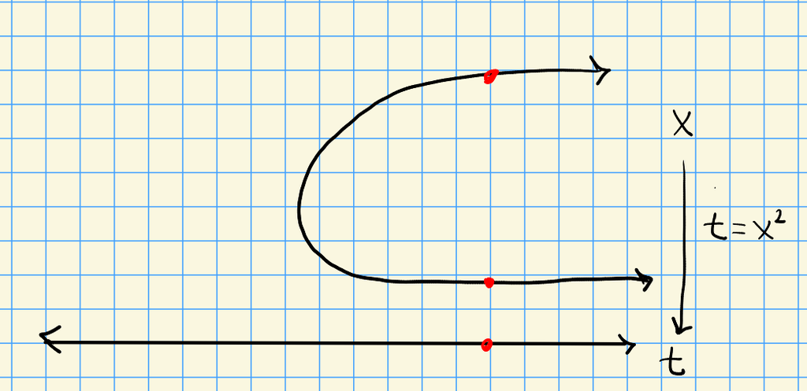

Is direct sum exact as a functor $\mathsf{A}{ {}^{ \scriptscriptstyle\times^{2} } }\to \mathsf{A}$? Regard $\mathsf{A}{ {}^{ \scriptscriptstyle\times^{2} } } = \mathsf{A}^{\mathsf{I}}$ where $I = \left\{{\bullet, \bullet}\right\}$ is the discrete 2-object diagram category. The map $(A_1, A_2)\to A_1 \oplus A_2$ is exact by just summing SESs.

## 21.2 Cohomology

Recall that one can compute $H_*(S^2; {\mathbb{Z}})$ in several ways.

Method 1: triangulation.

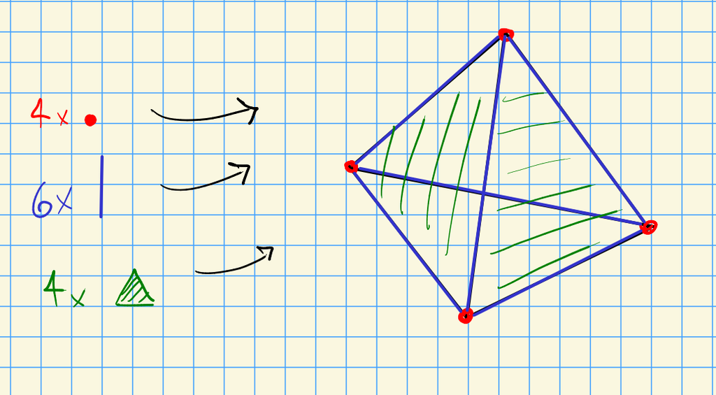

This yields
$$\begin{align*}
0 \leftarrow{\mathbb{Z}}{ {}^{ \scriptscriptstyle\times^{4} } } \leftarrow{\mathbb{Z}}{ {}^{ \scriptscriptstyle\times^{6} } }\leftarrow{\mathbb{Z}}{ {}^{ \scriptscriptstyle\times^{4} } } \leftarrow 0 \leadsto 0\leftarrow{\mathbb{Z}}\leftarrow 0 \leftarrow{\mathbb{Z}}\leftarrow 0
.\end{align*}$$

Method 2: cell complexes.

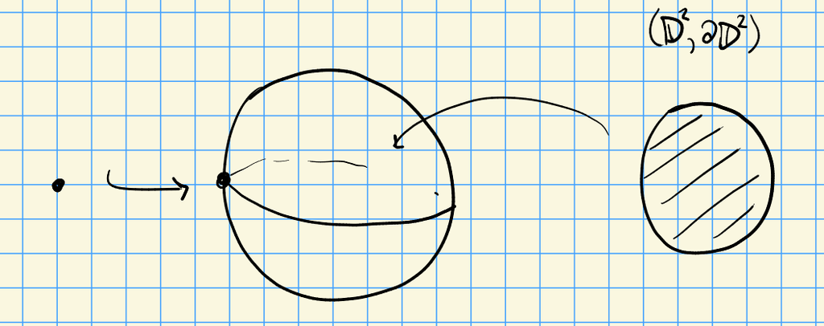

This directly yields
$$\begin{align*}
0\leftarrow{\mathbb{Z}}\leftarrow 0 \leftarrow{\mathbb{Z}}\leftarrow 0
.\end{align*}$$

Why are simplices $\Delta_n$ or discs $D^n$ the right things?

They are contractible, but more importantly do not themselves have higher homology and are thus *acyclic*.

More generally, for $F\in {\mathsf{Ab}}\mathsf{Cat}(\mathsf{A},\mathsf{B})$, we’ll want to resolve by acyclic objects. Injectives and projectives will be universal such objects, but are often hard to work with, so we’ll work on finding more economical acyclic resolutions. Next time: injectives/projectives and derived functors.

# 22 Wednesday, March 02

For $F\in {\mathsf{Ab}}\mathsf{Cat}(\mathsf{A}, \mathsf{B})$ left exact, assuming $\mathsf{A}$ has enough injectives, there is a right derived functor ${\mathbb{R}}F$ so that a SES $0\to A\to B\to C\to 0$ admits a LES with a connecting morphism $\delta$:
$$\begin{align*}
0\to {\mathbb{R}}FA\to {\mathbb{R}}F B\to {\mathbb{R}}F C \xrightarrow{\delta} \Sigma^1 {\mathbb{R}}F A \to \cdots
.\end{align*}
Note that \(\delta\) depends on the triple appearing in the SES.$$

${\mathbb{R}}F$ and $\delta$ are universal among $\delta{\hbox{-}}$functors.

Injectives will be acyclic and homology will measure how things are glued. Analogy: simplicial or cellular homology uses contractible objects (with trivial homology) to measure how spaces are glued from simplices or spheres.

Recall the definitions of projective and injective objects, which require existence (but not uniqueness) of certain lifts. In ${\mathsf{R}{\hbox{-}}\mathsf{Mod}}$, free implies projective, so free resolutions usually suffice and one can study generators, relations, syzygies, etc.

We’ll show that $\mathsf{A} \mathrel{\vcenter{:}}={\mathsf{Sh}}(X; {\mathsf{Ab}}{\mathsf{Grp}})$ has enough injectives, but usually won’t have enough projectives. Recall that this means that every $A\in \mathsf{A}$ admits a monomorphism $A\hookrightarrow I$ for $I$ an injective object. If there are enough injectives, every object admits an injective resolution, and any two such resolutions are homotopy equivalent.

Recall that
$$\begin{align*}
{ {{\mathbb{R}}}^{\scriptscriptstyle \bullet}} F(X) = { {H}_{\scriptscriptstyle \bullet}} ( F( X \leftleftarrows { {I}^{\scriptscriptstyle \bullet}} ))
\end{align*}
and \({\mathbb{R}}^{i\geq 1} F(I) = 0\) if \(I\) is itself injective.$$

Recall the Horseshoe lemma:

[figure not shown]

> Link to Diagram

Note that the complex in the middle is not the direct sum of the two outer complexes, just the terms – the differential $d_B$ on ${ {I}^{\scriptscriptstyle \bullet}} _B$ will be of the form
$$\begin{align*}
d_B = {
\begin{bmatrix}
{d_A} & {*}
\\
{0} & {d_C}
\end{bmatrix}
}
.\end{align*}$$

Prove this, using that additive functors preserve direct sums. Conclude using that this construction yields a SES of complexes $0\to F { {I}^{\scriptscriptstyle \bullet}} _A \to F { {I}^{\scriptscriptstyle \bullet}} _B\to F { {I}^{\scriptscriptstyle \bullet}} _C\to 0$.

Prove that if $I$ is injective then $0\to I\to B\to C\to 0$ splits by explicitly constructing a left and right splitting to show that $B$ satisfies the universal property of the biproduct. Show also that the same conclusion holds for $0\to A\to B\to P\to 0$ with $P$ projective.

# 23 Friday, March 04

Idea: regard $A$ as a chain complex supported in degree zero and $A\underset{\leftleftarrows}{\eta} { {I}^{\scriptscriptstyle \bullet}}$ an injective resolution, then the induced map $\eta^*: H^*(A)\to H^*( { {I}^{\scriptscriptstyle \bullet}} )$ is an isomorphism, so $A$ and ${ {I}^{\scriptscriptstyle \bullet}}$ are quasi-isomorphic.

Show that if $A\leftleftarrows { {I}^{\scriptscriptstyle \bullet}} , { {J}^{\scriptscriptstyle \bullet}}$, then there exists a chain homotopy $f: I \simeq J$.

Hints:

[figure not shown]

> Link to Diagram

Given
$$\begin{align*}
f^{n-1} - g^{n-1} = h^n d^{n-1} - d^{n-2} h^{n-1}
,\end{align*}
construct \(h^{n+1} d_I^n\) such that
\begin{align*}
(f^n - g^n) d_I^n = ( h^{n+1} d_I^n + d_J^{n-1} h^n ) d_I^n
\end{align*}
and extend arbitrarily to \(h^{n+1}: I^{n+1} \to J^n\).$$

Prove the Horseshoe lemma.

# 24 Monday, March 14

Call the definition of the derived functor ${\mathbb{R}}F$ for a left-exact functor $F\in{\mathsf{Ab}}\mathsf{Cat}(\mathsf{C}, \mathsf{D})$ where $\mathsf{A}$ has enough injectives. These satisfy ${\mathbb{R}}^0 F = F$, and for a SES $0\to A\to B\to C\to 0$ there is an induced LES ${\mathbb{R}}F A\to {\mathbb{R}}F B \to {\mathbb{R}}F C \to {\mathbb{R}}F A[1]$ which is functorial in the triple $(A,B,C)$. Next: Grothendieck’s universality theorem.

A $\delta{\hbox{-}}$functor is a sequence of functors $\left\{{S^i: \mathsf{A}\to \mathsf{B}}\right\}_{i\geq 0}$ such that for all SESs $0\to A\to B\to C\to 0$ there is a (not necessarily exact) complex:

[figure not shown]

> Link to Diagram

A **morphism** of $\delta{\hbox{-}}$functors is a collection $\left\{{f^i: S^i\to T^i}\right\}_{i\geq 0}$ such that for all such SESs, there is a commutative diagram:

[figure not shown]

> Link to Diagram

Note that the first 2 square are commutative by functoriality, and the content here is that the map commutes with the connecting morphisms.

An additive functor $G: \mathsf{A}\to \mathsf{B}$ is **effaceable** iff for all $A\in \mathsf{A}$ there is a monomorphism $A\xhookrightarrow{f} M$ such that $GA \xrightarrow{Gf} GM$ is the zero map.

Effaceable functors are those which erase some monomorphism.

A delta functor $(S_i, \phi_S)$ is *exact* iff the induced complex is a LES, and is **universal** iff for any other delta functor $(T_i, \phi_T)$ and any natural transformation $\eta: S^0\to T^0$, there is a unique morphism $(S_i, \phi_S) \to (T_i, \phi_T)$ extending $\eta$.

When $F\in {\mathsf{Ab}}\mathsf{Cat}(\mathsf{A}, \mathsf{B})$ where $\mathsf{A}$ has enough injectives, $({\mathbb{R}}^i F, \phi)$ is universal and there is a unique such delta functor with ${\mathbb{R}}^0 F = F$.

Embed $A\hookrightarrow I$ into an injective object, which is $F{\hbox{-}}$acyclic, and thus ${\mathbb{R}}^i F A \xrightarrow{0} {\mathbb{R}}^i F I = 0$.

Proceed by induction. Let $0\to A \to M \to Q \to 0$ be arbitrary, and use a diagram chase to define a map $f^i(\iota)$:

[figure not shown]

> Link to Diagram

One needs to show:

1. $f^i(\iota)$ does not depend on $\iota$
2. It is a ? for all $A\to B$
3. This map commutes with $\phi_S, \phi_T$.

# 25 Wednesday, March 16

## 25.1 Grothendieck’s Universal Theorem

Setup from last time: $F\in {\mathsf{Add}}\mathsf{Cat}(\mathsf{A}, \mathsf{B})$ left-exact, $\left\{{(S^n, \phi_S^n)}\right\}_{n\geq 0}$ exact $\delta{\hbox{-}}$functors where for $n > 0$ the $S^n$ are effaceable. Then it is universal: for all $\delta{\hbox{-}}$functors $\left\{{(T^n, \phi_T^n)}\right\}_{n\geq 0}$ with a natural transformation $S^0 \to T^0$ there exist unique morphisms $(S^n, \phi_S^n) \to (T^n, \phi_T^n)$, i.e. natural transformations $S^n\to T^n$ commuting with the $\phi^n$.

### 25.1.1 Proof of Universality

Take an effacement $0\to A \xhookrightarrow{i} M$ for $S^{n+1}$ and extend to a SES $0\to A\to M\to Q\to 0$. We’ll define the ladder of morphisms inductively using the following commutative diagram:

[figure not shown]

> Link to Diagram

We need to show

- $f^{n+1}(A, i)$ only depends on $A$
- $f^{n+1}$ is functorial in $A$
- $f^{n+1}$ commutes with $\phi_S, \phi_T$.

Assume that given two effacements of two delta functors, there exist morphisms:

[figure not shown]

> [Link to Diagram](https://q.uiver.app/?q=WzAsNixbMCwwLCIwIl0sWzIsMCwiQV8xIl0sWzQsMCwiTV8xIl0sWzAsMiwiMCJdLFsyLDIsIkFfMiJdLFs0LDIsIk1fMiJdLFswLDFdLFsxLDIsImlfMSJdLFszLDRdLFsxLDRdLFs0LDUsImlfMiJdLFsyLDVdXQ==)

Then there is a commuting square

[figure not shown]

> [Link to Diagram](https://q.uiver.app/?q=WzAsNCxbMCwwLCJTXntuKzF9QV8xIl0sWzIsMCwiU157bisxfUFfMiJdLFswLDIsIlRee24rMX1BXzEiXSxbMiwyLCJUXntuKzF9QV8yIl0sWzAsMSwiU157bisxfShnKSJdLFsyLDMsIlRee24rMX0oZykiXSxbMSwzXSxbMCwyXV0=)

There is a cube:

[figure not shown]

> Link to Diagram

Here all faces but the front form commuting squares.

Show that one can move the red path to the blue through the other commuting faces.

$f^{n+1}(A, i)$ only depends on $A$. Take two effacements, and assume there is a commuting diagram:

[figure not shown]

> Link to Diagram

By the lemma:

[figure not shown]

> Link to Diagram

[figure not shown]

> Link to Diagram

> See notes for finished proof.

# 26 Friday, March 18

Given effacements:

[figure not shown]

> [Link to Diagram](https://q.uiver.app/?q=WzAsNixbMCwwLCIwIl0sWzIsMCwiQV8xIl0sWzQsMCwiTV8xIl0sWzQsMiwiTV8yIl0sWzIsMiwiQV8yIl0sWzAsMiwiMCJdLFswLDFdLFsxLDJdLFs1LDRdLFs0LDNdLFsxLDQsImciXV0=)

There exists an effacement extending $g$. Use

[figure not shown]

> Link to Diagram

There is a factorization:

[figure not shown]

> Link to Diagram

> ?? Concludes theorem from last time.z

Recall that $\mathop{\mathrm{Hom}}(C, {-})$ is left exact covariant and $\mathop{\mathrm{Hom}}({-}, C)$ is left exact contravariant. For left exact functors,

- Right derived functors are computed with injective resolutions.
- $\mathsf{C}$ needs enough injectives

For right exact functors,

- Left derived functors are computed with projective resolutions.
- $\mathsf{C}$ needs enough projectives

Projective sheaves are locally free.

Show:

- Injectives are closed under $\prod$,
- Projectives are closed under $\bigoplus$.

[figure not shown]

> Link to Diagram

Show that in ${\mathsf{R}{\hbox{-}}\mathsf{Mod}}$, $M$ is projective $\iff M$ is a direct summand of a free module iff $M$ is locally free.

Some hints:

[figure not shown]

> Link to Diagram

Show

- ${\mathbb{R}}\mathop{\mathrm{Hom}}_{{\mathbb{Z}{\hbox{-}}\mathsf{Mod}}}(C_n, M) = M[n] \oplus \Sigma^1(M/nM)$ using $0\to {\mathbb{Z}}\xrightarrow{\times n} {\mathbb{Z}}\to {\mathbb{Z}}/n{\mathbb{Z}}\to 0$.
  - Conclude that divisible module has vanishing $\operatorname{Ext} ^1(C_n, {-})$.
- If $R$ is a PID, then $M\in {\mathsf{R}{\hbox{-}}\mathsf{Mod}}$ is injective $\iff M$ is divisible.
- For all rings $R$, $R$ is injective iff

[figure not shown]

> [Link to Diagram](https://q.uiver.app/?q=WzAsNCxbMCwwLCIwIl0sWzIsMCwiTiJdLFs0LDAsIlIiXSxbNCwyLCJJIl0sWzAsMV0sWzEsMl0sWzEsM10sWzIsMywiIiwxLHsic3R5bGUiOnsiYm9keSI6eyJuYW1lIjoiZGFzaGVkIn19fV1d)

# 27 Monday, March 21

Recall free $\implies$ projective and ${\mathsf{R}{\hbox{-}}\mathsf{Mod}}$ has enough projectives and enough injectives.

Show $I$ is injective iff

[figure not shown]

> [Link to Diagram](https://q.uiver.app/?q=WzAsNCxbMCwwLCIwIl0sWzIsMCwiSiJdLFs0LDAsIlIiXSxbNCwyLCJJIl0sWzAsMV0sWzEsMl0sWzIsMywiXFxleGlzdHMiLDAseyJzdHlsZSI6eyJib2R5Ijp7Im5hbWUiOiJkYXNoZWQifX19XSxbMSwzXV0=)

Hint:

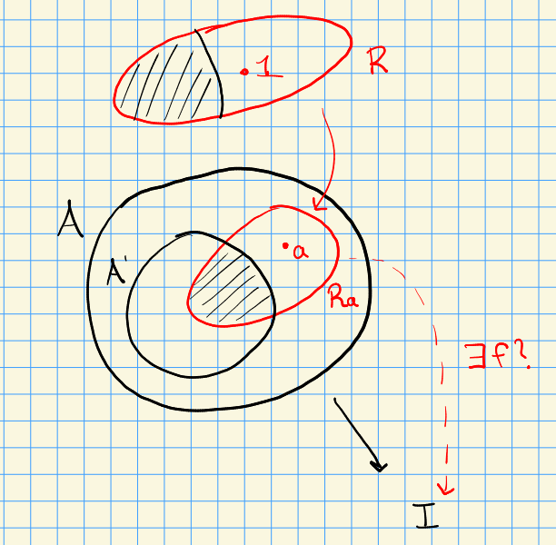

Extend to $A' + Ra$ using $1\mapsto a \mapsto i\in I$ under $R\to Ra\to I$. Take a poset of all $B \subseteq A$ with $g:B\to I$ extending $A'\to I$ and apply Zorn’s lemma.

Show that for $R$ a PID, $M\in {\mathsf{R}{\hbox{-}}\mathsf{Mod}}$ is injective iff divisible.

Show that ${\mathbb{Z}{\hbox{-}}\mathsf{Mod}}$ has enough innjectives.

> Hint: write $A = \bigoplus {\mathbb{Z}}/K \hookrightarrow\bigoplus {\mathbb{Q}}/K$.

On adjoint functors:
$$\begin{align*}
\adjunction F G {\mathsf{A}} {\mathsf{B}} \implies \mathsf{B}(FX, Y) { \, \xrightarrow{\sim}\, }\mathsf{A}(X, GY)
.\end{align*}
Here \(F\) is a left adjoint hence right exact, and \(G\) is a right adjoint and is left exact.$$

Show that if $F$ is left exact then $G$ preserves in injectives, and if $F$ is right exact then $G$ preserves projectives.

Hint:

[figure not shown]

> Link to Diagram

For $f\in \mathsf{CRing}(S\to R)$, there is an adjunction \begin{align*} \adjunction {M_R\mapsto M_S} { {\mathsf{S}{\hbox{-}}\mathsf{Mod}}(R, {-}) } {{\mathsf{R}{\hbox{-}}\mathsf{Mod}}}{{\mathsf{S}{\hbox{-}}\mathsf{Mod}}} \end{align*} where ${\mathsf{S}{\hbox{-}}\mathsf{Mod}}(R, N) \in {\mathsf{R}{\hbox{-}}\mathsf{Mod}}$ via the action $(rf)(x) \mathrel{\vcenter{:}}= f(rx)$, sometimes called the *induced $R{\hbox{-}}$module*. Note that ${\mathsf{R}{\hbox{-}}\mathsf{Mod}}(R, N) { \, \xrightarrow{\sim}\, }N$ by $1_R \mapsto n$, and there is an iso
$$\begin{align*}
{\mathsf{S}{\hbox{-}}\mathsf{Mod}}(M_S, N) &\rightleftharpoons{\mathsf{R}{\hbox{-}}\mathsf{Mod}}(M_R, {\mathsf{S}{\hbox{-}}\mathsf{Mod}}(R, N)) \\
\qty{ m\mapsto \psi(m)(1) } &\mapsfrom \psi \\
\phi &\mapsto \qty{m \mapsto \psi(m)(i) \mathrel{\vcenter{:}}=\psi(im) \mathrel{\vcenter{:}}=\phi(im) }
.\end{align*}$$

Proving ${\mathsf{R}{\hbox{-}}\mathsf{Mod}}$ has enough injectives if ${\mathsf{S}{\hbox{-}}\mathsf{Mod}}$ has enough injectives: use $M_R \cong {\mathsf{R}{\hbox{-}}\mathsf{Mod}}(R, M)\hookrightarrow{\mathsf{S}{\hbox{-}}\mathsf{Mod}}(R, M_S) \hookrightarrow{\mathsf{S}{\hbox{-}}\mathsf{Mod}}(R, I)$ where $M_S \hookrightarrow I$ embeds into some injective. Take $R$ arbitrary and $S={\mathbb{Z}}$ to conclude any ${\mathsf{R}{\hbox{-}}\mathsf{Mod}}$ has enough injectives.

This is a theoretical tool and not particularly practical. Consider $S\to R \mathrel{\vcenter{:}}={\mathbb{Q}}\to {\mathbb{C}}$ and $M = {\mathbb{C}}$. Then ${\mathsf{{\mathbb{Q}}}{\hbox{-}}\mathsf{Mod}}({\mathbb{C}}, {\mathbb{C}}_{\mathbb{Q}}) = G{\mathbb{C}}_{\mathbb{Q}}$.

Any $M\in {\mathsf{R}{\hbox{-}}\mathsf{Mod}}$ admits a minimal injective hull $M\hookrightarrow I$.

${\mathsf{Sh}}(X \to {\mathsf{Ab}}{\mathsf{Grp}})$ and ${\mathsf{{\mathcal{O}}_X}{\hbox{-}}\mathsf{Mod}}$ have enough injectives.

Take
$$\begin{align*}
{\mathcal{F}}\hookrightarrow\prod_{x\in X} (\iota_x)_* {\mathcal{F}}_x \hookrightarrow\prod_{x\in X} I_x
.\end{align*}
The claim is that the last term is an injective sheaf. Using that products of injective are injective, it STS \(I_x\) is injective. For \(\iota_x: \left\{{x}\right\} \hookrightarrow X\), use that modules on a point are \({\mathbb{Z}{\hbox{-}}\mathsf{Mod}}\) and obtain an adjunction
\begin{align*}
\adjunction {(\iota_x)_*} {(\iota_x)^{-1}} {{\mathbb{Z}{\hbox{-}}\mathsf{Mod}}}{{\mathsf{Sh}}(X\to {\mathsf{Ab}}{\mathsf{Grp}})}
.\end{align*}
Finally use that \({\mathbb{Z}{\hbox{-}}\mathsf{Mod}}\) has enough injectives.$$

# 28 Wednesday, March 23

Induced and coinduced modules:

[figure not shown]

> Link to Diagram

Note that coinduction sends injective to injectives, and induction sends projectives to projectives. Recall that ${\mathsf{Sh}}(X; {\mathsf{Ab}}{\mathsf{Grp}})$ and ${\mathsf{{\mathcal{O}}_X}{\hbox{-}}\mathsf{Mod}}$ have enough injectives, so left exact covariant functors $F$ admit right-derived functors ${\mathbb{R}}F$, and similarly right exact contravariant functors $F$ admit left-derived functors ${\mathbb{L}}F$.

Important functors:

- Global sections ${{\Gamma}\qty{{-}} }: {\mathsf{Sh}}(X; \mathsf{C}) \to \mathsf{C}$ where ${\mathcal{F}}\mapsto {\mathcal{F}}(X)$, e.g. for $\mathsf{C} = {\mathsf{Ab}}{\mathsf{Grp}}$. ${\mathbb{R}}{{\Gamma}\qty{{\mathcal{F}}} } = H^i(X; {\mathcal{F}})$ is sheaf cohomology.
- For $f\in {\mathsf{Top}}(X, Y)$, the pushforwards $f_*: {\mathsf{Sh}}(X; \mathsf{C}) \to {\mathsf{Sh}}(Y; \mathsf{C})$ where ${\mathcal{F}}\mapsto (U\mapsto {\mathcal{F}}(f^{-1}U))$. ${\mathbb{R}}f_* {\mathcal{F}}$ are *derived pushforwards*.
- Inverse image, which is exact.
- $({-})\otimes_{{\mathcal{O}}_X} {\mathcal{F}}$
- $\mathop{\mathrm{Hom}}_{{\mathcal{O}}_X}({-}, {\mathcal{F}})$.

If $F \in [\mathsf{A}, \mathsf{B}]$ is left exact covariant and $\mathsf{A}$ has enough injectives, then for every $A\in \mathsf{A}$ there exists an acyclic resolution $0\to A \leftleftarrows { {J}^{\scriptscriptstyle \bullet}}$ whose homology computes ${\mathbb{R}}R$.

Why this homology computes the derived functors: let $A = A^0$ and take an injective resolution $A \leftleftarrows { {J}^{\scriptscriptstyle \bullet}}$. Break this into SESs, letting $Z_i$ denote images:

- $0 \to Z^0 \to J^0\to Z^1\to 0$
- $0 \to Z^1\to J^1 \to Z^2\to 0$
- $\cdots$

Note that $Z^n \leftleftarrows\Sigma^n { {J}^{\scriptscriptstyle \bullet}} = (J^n\to J^{n+1}\to\cdots)$ is an injective resolution. Splice to obtain
$$\begin{align*}
0 \to FA \to FJ^0 \to FZ^1\to {\mathbb{R}}^1 FA \to 0, \qquad {\mathbb{R}}^n F Z^1 { \, \xrightarrow{\sim}\, }{\mathbb{R}}^{n+1} FA \\
0 \to \ker(FJ^0\to FJ^1) \to FJ^0 \to \ker(FJ^1\to FJ^2) \to {\mathbb{R}}^1 FA \to 0
.\end{align*}
Proceed by induction.$$

Consider $F = \mathsf{A}(A, {-})$ (covariant) or $\mathsf{A}({-}, A)$ (contravariant), so $F\in \mathsf{Cat}(\mathsf{A}, {\mathsf{Ab}}{\mathsf{Grp}})$. Note that acyclic objects for $F$ are exactly injectives: take $0\to A\to B\to C\to 0$ to obtain $0\to [C, I] \to [B, I]\to [A, I] \to \operatorname{Ext} ^1(C, I) = 0$ by acyclicity of $I$, meaning that $[B,I] \twoheadrightarrow[A, I]$ and thus there exist lifts:

[figure not shown]

> Link to Diagram

A sheaf ${\mathcal{F}}\in {\mathsf{Sh}}(X; {\mathbb{Z}{\hbox{-}}\mathsf{Mod}})$ is **flasque** iff for all $U \subseteq X$ open, $F(X) \twoheadrightarrow F(U)$. It is **soft** iff the same holds for all *closed* sets instead, and **fine** if ${\mathcal{F}}$ has a partition of unity property.

Note that fine $\implies$ soft and flasque $\implies$ soft. Fine sheaves are best for paracompact Hausdorff spaces, and flasque are better for e.g. the order topology.

# 29 Friday, March 25

## 29.1 Flasque Sheaves

Important classes of sheaves:

- Universal: flasque or flabby.
- Classical topologies (Hausdorff, paracompact): fine $\implies$ soft.
- AG: quasicoherent sheaves on affine sets and covers.

Suppose $\mathsf{A}\in {\mathsf{Ab}}\mathsf{Cat}$ has enough injectives and ${\mathcal{F}}\in \mathsf{Cat}(\mathsf{A},\mathsf{B})$ is left exact. Suppose ${\mathcal{C}}\subseteq {\operatorname{Ob}}\mathsf{A}$ satisfies

- Any $A\in \mathsf{A}$ admits an embedding $A\hookrightarrow C$ for some $C\in {\mathcal{C}}$.
- If $A_1 \bigoplus A_2 \in {\mathcal{C}}$ then $A_1, A_2\in {\mathcal{C}}$.
- Given a SES $0\to A\to B\to C\to 0$ with $A, B\in {\mathcal{C}}$, $C\in {\mathcal{C}}$ and $0\to FA\to FB\to FC\to 0$ is exact.

Then every $C\in {\mathcal{C}}$ is $F{\hbox{-}}$acyclic.

Use this to show that flasque implies $F{\hbox{-}}$acyclic for $F({-}) \mathrel{\vcenter{:}}={{\Gamma}\qty{{-}} }$.

Recall $U \subseteq X$ open $\implies F(X) \twoheadrightarrow F(U)$.

- Take an embedding $0\to F\to \prod_{x\in X} (\iota_x)_* F_x$ where $\iota_x: \left\{{x}\right\} \hookrightarrow X$. Use that for any group $A$, ${\mathcal{G}}\mathrel{\vcenter{:}}=(\iota_x)_* A$ satisfies ${\mathcal{G}}(X) \twoheadrightarrow{\mathcal{G}}(S)$ for any $S \subseteq X$ since ${\mathcal{G}}$ is flasque and soft and this is preserved under products.
- Apply the lifting property to direct sums.
- Use that restrictions of flasque sheaves to opens are again flasque to prove that there is a surjection:

[figure not shown]

> Link to Diagram

Any injective is in ${\mathcal{C}}$ by assumption: since $J\hookrightarrow C$ splits for any injective $J$, one has $C\cong J \oplus J'$, making $J$ a direct summand and thus in ${\mathcal{C}}$ by the 2nd property.

Since there are enough injectives, form $0\to C\to I \to C''\to 0$. Take the LES, using that ${\mathbb{R}}^{>0 } FI = 0$ to obtain

[figure not shown]

> Link to Diagram

There is a canonical flasque resolution:

[figure not shown]

> Link to Diagram

This is useful e.g. for finite sets with the order topology, but less useful if ${\left\lvert {X} \right\rvert}$ is infinite and there are non-closed points.

Show that if $X$ is Hausdorff paracompact, flasque implies soft. As a corollary, soft sheaves are acyclic for such spaces.

See notes.

## 29.2 Fine Sheaves

Recall that a sheaf is fine iff it satisfies the POU property.

- Classically: there is an open cover ${\mathcal{U}}\rightrightarrows X$ and $\phi_i: U_i \to {\mathbb{R}}$ with $\mathop{\mathrm{supp}}\phi_i \subseteq U_i$ where $\sum \phi_i = 1$ and locally there are only finitely many nonzero $\phi$.
- For sheaves: there is an open cover ${\mathcal{U}}\rightrightarrows X$ and $\phi_i: {\mathcal{F}}\to {\mathcal{F}}$ with $\mathop{\mathrm{supp}}\phi$ a closed set $Z_i$ where $\sum \phi_i = \operatorname{id}_{\mathcal{F}}$ and locally there are only finitely many $i$ with $\phi({\mathcal{F}})\neq 0$.

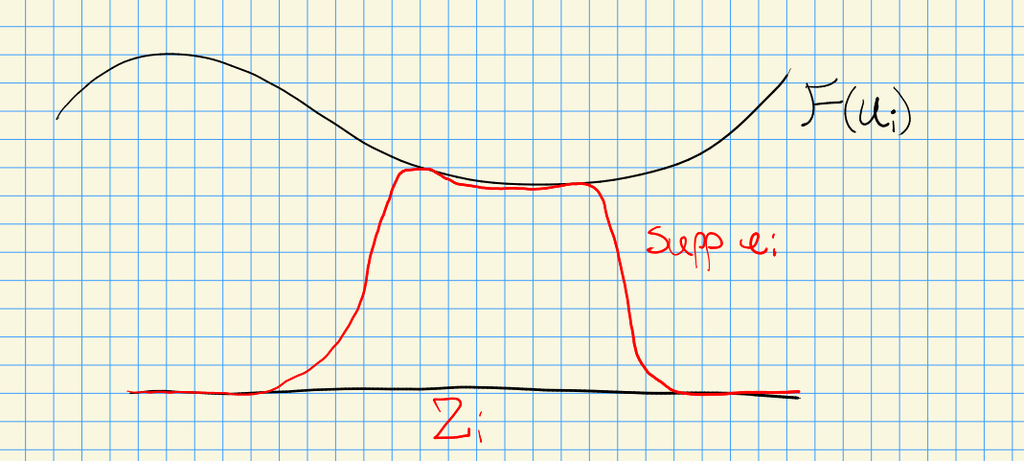

Suppose $X$ is Hausdorff paracompact, set ${\mathcal{F}}\mathrel{\vcenter{:}}={\mathcal{O}}_X^\text{cts}$. Thus ${\mathcal{O}}_X$ has a POU property, as does any ${\mathcal{O}}_X{\hbox{-}}$module. Take a usual POU $\left\{{f_i}\right\}$ and define
$$\begin{align*}
\phi: {\mathcal{F}}&\to {\mathcal{F}}\\
s &\mapsto f_i s
.\end{align*}
So any \({\mathcal{F}}\in {\mathsf{{\mathcal{O}}_X^\text{cts}}{\hbox{-}}\mathsf{Mod}}\) is soft.$$

In this case, fine implies soft.

## 29.3 de Rham and Dolbeaut cohomology

Let $X$ be a smooth manifold over ${\mathbb{R}}$. Note that $\underline{{\mathbb{R}}}$ is not fine and not soft, and not even an ${\mathcal{O}}_X{\hbox{-}}$module. However it admits a resolution $0 \leftarrow\underline{{\mathbb{R}}} \leftleftarrows { {\Omega_{X}}^{\scriptscriptstyle \bullet}}$ where $\Omega^0_{X} \mathrel{\vcenter{:}}={\mathcal{O}}_X^{{\mathsf{sm}}}$, and this resolution computes the sheaf cohomology ${ {H}^{\scriptscriptstyle \bullet}} (X; \underline{{\mathbb{R}}})$.

Similarly, $0 \to \underline{{\mathbb{C}}} \leftleftarrows_{{ \mkern 1.5mu\overline{\mkern-1.5mu{\partial}\mkern-1.5mu}\mkern 1.5mu}} \Omega^{0, \bullet}$ where ${ \mkern 1.5mu\overline{\mkern-1.5mu{\partial}\mkern-1.5mu}\mkern 1.5mu}= \sum {\frac{\partial }{\partial \mkern 1.5mu\overline{\mkern-1.5muz\mkern-1.5mu}\mkern 1.5mu_i }\,} dz_i$.

# 30 Computing Cohomology (Monday, March 28)

Upcoming topics related to ${ {H}^{\scriptscriptstyle \bullet}} (X; {\mathcal{F}})$:

- General vanishing theorems
- Čech cohomology
- Riemann-Roch

## 30.1 Vanishing Theorems

If $X$ is a Noetherian space, then $\tau_{\geq n+1} { {H}^{\scriptscriptstyle \bullet}} (X; {\mathcal{F}}) = 0$ for $n\mathrel{\vcenter{:}}=\dim X$.

A sheaf ${\mathcal{F}}\in {\mathsf{Sh}}(X, {\mathsf{{\mathcal{O}}_X}{\hbox{-}}\mathsf{Mod}})$ is **quasicoherent** if for all $U = \operatorname{Spec}R \subseteq X$, the restrictions ${ \left.{{{\mathcal{F}}}} \right|_{{U}} } \cong \tilde M$ for $M\in {\mathsf{R}{\hbox{-}}\mathsf{Mod}}$. Recall that ${\mathcal{O}}_X(D(f)) = R{ \left[ { \scriptstyle \frac{1}{f} } \right] }$, and we define $\tilde M(D(f)) \mathrel{\vcenter{:}}= M{ \left[ { \scriptstyle \frac{1}{f} } \right] }$, so e.g. $\tilde R = {\mathcal{O}}_X$.

A sheaf ${\mathcal{F}}\in {\mathsf{Sh}}(X, {\mathsf{{\mathcal{O}}_X}{\hbox{-}}\mathsf{Mod}})$ is quasicoherent iff
$$\begin{align*}
{\mathcal{O}}_X { {}^{ \scriptscriptstyle\oplus^{J} } } \to {\mathcal{O}}_X{ {}^{ \scriptscriptstyle\oplus^{I} } } \to {\mathcal{F}}\to 0
.\end{align*}$$

Analogy:

- Quasicoherent: arbitrary modules $M$
- Coherent: finitely presented modules $M$.

Examples of coherent sheaves

- For $X \subseteq {\mathbb{P}}^N$ projective (or quasiprojective, i.e. open in a projective), the **twisting sheaves** ${\mathcal{O}}_X(d)$ whose local sections are $p(\mathbf{x})/q(\mathbf{x})$ for $p,q$ homogeneous where $\deg p - \deg q = d$.
- For any $Z \subseteq X$ as above, the **ideal sheaf** ${\mathcal{I}}_Z \subseteq {\mathcal{O}}_Z$ and their twists ${\mathcal{I}}_Z(d) \mathrel{\vcenter{:}}={\mathcal{I}}_Z \otimes_{{\mathcal{O}}_X} {\mathcal{O}}(d)$.
- Tangent sheaves ${\mathbf{T}}_X$ and cotangent sheaves ${\mathbf{T}} {}^{ \vee }_X$, and their tensor powers, e.g. $\Omega^n_X$.

$$\begin{align*}
{\mathcal{F}}\in {\mathsf{QCoh}}(X), \, X\in {\mathsf{Aff}}{\mathsf{Sch}}_{/ {k}} \implies
\tau_{\geq 1} { {H}^{\scriptscriptstyle \bullet}} (X; {\mathcal{F}}) = 0
.\end{align*}$$

$$\begin{align*}
{\mathcal{F}}\in {\mathsf{Coh}}(X),\, X\in \mathop{\mathrm{Proj}}{\mathsf{Sch}}_{/ {k}} \implies
\tau_{\geq 1} { {H}^{\scriptscriptstyle \bullet}} (X; {\mathcal{F}}(n) ) = 0 \text{ for some } n\gg 0
.\end{align*}$$

Affine schemes correspond to general rings, and projective schemes correspond to graded rings. In the second statement, coherence is used as a kind of finiteness.

## 30.2 Čech Cohomology

For open covers, write ${\mathcal{U}}\rightrightarrows X$ iff $X = \cup_i U_i$. Define $U_{i_0, i_1,\cdots, i_p} \mathrel{\vcenter{:}}= U_{i_1} \cap U_{i_1} \cap\cdots \cap U_{i_p}$. Define a complex
$$\begin{align*}
0 \to {\check{C}}^0({\mathcal{U}}; {\mathcal{F}}) = \bigoplus_{i_0\in I} {{\Gamma}\qty{{\mathcal{F}}; U_{i_0}} } \xrightarrow{{\partial}_1} \bigoplus _{i_1 < i_2} {{\Gamma}\qty{{\mathcal{F}}; U_{i_0, i_1}} } \xrightarrow{{\partial}_2} \cdots
.\end{align*}
where we specify where elements land componentwise:
\begin{align*}
{ \left.{{{\partial}_i}} \right|_{{i_1 < \cdots < i_{p+1}}} }: \bigoplus _{i_0 < \cdots < i_p} {\mathcal{F}}(U_{i_0, \cdots , i_p}) \\
f &\mapsto \sum_{0\leq k \leq p+1} (-1)^k { \left.{{f}} \right|_{{i_0 < \cdots \widehat{k} < i_{p+1} }} }\mathrel{\Big|}_{U_{i_0, \cdots, i_{p+1}}}
.\end{align*}$$

Why ${\partial}^2 = 0$: if $k < \ell$, forget $\ell$ first and then $k$ to get a sign $(-1)^\ell (-1)^k$, or forget $k$ first then $\ell$ to get $(-1)^k (-1)^{\ell - 1}$ due to the shift. So these contributions cancel.

Suppose that for all inclusions $j_{i_0, \cdots, i_p}: U_{i_0, \cdots, i_p} \to X$, the pushforwards of ${\mathcal{F}}$
$$\begin{align*}
{ \left.{{ (j_{i_0, \cdots, i_p})_* {\mathcal{F}}}} \right|_{{U_{i_0, \cdots, i_p}}} }
\end{align*}
have vanishing cohomology in degrees \(p\geq 1\). Then
\begin{align*}
{ {H}^{\scriptscriptstyle \bullet}} (X; {\mathcal{F}}) { \, \xrightarrow{\sim}\, } { {{\check{H}}}^{\scriptscriptstyle \bullet}} ({\mathcal{U}}; {\mathcal{F}})
.\end{align*}$$

This is true for all affine schemes if ${\mathcal{F}}\in {\mathsf{QCoh}}(X)$, e.g. for algebraic varieties or separated schemes.

# 31 Wednesday, March 30

Topics:

- General vanishing (Serre 1 and 2)
- Čech cohomology
- Riemann-Roch and Serre duality
- Advanced vanishing (e.g. Kodaira vanishing)

## 31.1 Čech Cohomology

Setup: $X$ and ${\mathcal{F}}\in {\mathsf{Sh}}(X; {\mathsf{Ab}}{\mathsf{Grp}})$, an open cover ${\mathcal{U}}\rightrightarrows X$. We defined the Čech complex:
$$\begin{align*}
{\check{C}}^p({\mathcal{U}}; {\mathcal{F}}) = \bigoplus _{i_1 < \cdots < i_p} {\mathcal{F}}(U_{i_1, \cdots, i_p})
,\end{align*}
which had certain differentials.$$

Suppose $X\in {\mathsf{Alg}}{\mathsf{Var}}$ or $X\in {\mathsf{Sch}}$ is separated (e.g. a quasiprojective scheme), $F\in {\mathsf{QCoh}}(X)$ an ${\mathcal{O}}_X{\hbox{-}}$module, and let ${\mathcal{U}}\rightrightarrows X$ be an affine open cover. Then
$$\begin{align*}
{\check{H}}({\mathcal{U}}; F) = {\mathbb{R}}\Gamma(X; F)
.\end{align*}$$

More generally, we can just assume that all intersections of affines are affine, and instead there is a spectral sequence. This can fail if $X$ is not separated, e.g. $X \mathrel{\vcenter{:}}={\mathbb{A}}^2 { \displaystyle\coprod_{{\mathbb{A}}^2\setminus\left\{{0}\right\}} } {\mathbb{A}}^2$ where the intersection ${\mathbb{A}}^2\setminus\left\{{0}\right\}$ is not affine. Recall that $X$ is separated iff $X \xhookrightarrow{\Delta_X} X{ {}^{ \scriptscriptstyle{ \underset{\scriptscriptstyle {X} }{\times} }^{2} } }$ is closed.

Consider $X={\mathbb{P}}^1$ and $F = \bigoplus _{d\in {\mathbb{Z}}} {\mathcal{O}}_X(d)$, we can compute ${\check{H}}(X; {\mathcal{O}}(d))$ for all $d$. Take a cover $U_i = \left\{{x_i\neq 0}\right\}$ where $U_0$ has coordinate $x \mathrel{\vcenter{:}}= x_1/x_0$ and $U_1$ has coordinate $y= x_0/x_1$ which intersect at $U_{01} = \left\{{x,y\neq 0}\right\}$ and are glued by $y=1/x$. The Čech resolution is
$$\begin{align*}
0\to F(U_0) \oplus F(U_1) \xrightarrow{f} F(U_{01}) \to 0
,\end{align*}
so \(H^0 = \ker f\) and \(H^1 = \operatorname{coker}f\). Recall that sections of \({\mathcal{O}}(d)\) are locally ratios of polynomials with valuation \(d\). We have \({ \left.{{{\mathcal{O}}_{{\mathbb{P}}^1}(d)}} \right|_{{{\mathbb{A}}_1}} } = x_0^d {\mathcal{O}}_{{\mathbb{P}}^1}\) by rewriting \(p/q = x_0^d p'/q'\). We can thus write this sequence as
\begin{align*}
0 \to \bigoplus _{d\in {\mathbb{Z}}} x_0^d k { \left[ \scriptstyle {x= {x_1\over x_0}} \right] } =
\bigoplus_d \left\langle{\text{degree $d$ monomials in } x_0^{\pm 1}, x_1}\right\rangle \oplus \bigoplus _{d} \left\langle{\text{degree $d$ monomials in } x_0, x_1^{\pm 1}}\right\rangle
\to \bigoplus_d \left\langle{\text{degree $d$ monomials in } x_0^{\pm 1}, x_1^{\pm 1}}\right\rangle
\to 0
.\end{align*}$$

$$\begin{align*}
H^0(X; F) = k[x_0, x_1], \qquad H^1 = {1\over x_0 x_1} k { \left[ \scriptstyle {{1\over x_0}, {1\over x_1}} \right] }
.\end{align*}$$

Being in the kernel means $v_{x_0}(f)>0$ and $v_{x_1}(f) > 0$, which yields monomials $x_0^n x_1^m$ where $d=n+m$. For the cokernel, note $(p, 1) \mapsto p-q$, what’s missing? Monomials where both powers are negative.

Similar computations work for $X={\mathbb{P}}^n$ and yield
$$\begin{align*}
{H}^0\qty{X; \bigoplus _{d\in {\mathbb{Z}}} {\mathcal{O}}_{{\mathbb{P}}^n}(d) } = k[x_1, \cdots, x_{n}], \quad
{H}^n\qty{X; \bigoplus _{d\in {\mathbb{Z}}} {\mathcal{O}}_{{\mathbb{P}}^n}(d) } = {1\over \prod x_i} k { \left[ \scriptstyle {{1\over x_0}, \cdots, {1\over x_n}} \right] }
.\end{align*}
Note that both sides are graded by degree. This can be done in affine opens \(U_i = \left\{{x_i\neq 0}\right\} \cong {\mathbb{A}}^n\), \({ \left.{{{\mathcal{O}}_X(d)}} \right|_{{=}} } x_i^d {\mathcal{O}}_X\), and similarly
\begin{align*}
0 \to
\bigoplus_d \left\langle{\text{degree $d$ monomials in } x_0^{\pm 1}, x_1, \cdots, x_n}\right\rangle \oplus
\bigoplus _d \left\langle{\text{degree $d$ monomials in} x_0, x_1^{\pm 1}, \cdots, x_n}\right\rangle
\oplus \cdots
\to \cdots \to 0
.\end{align*}
The kernel is again spanned by monomials \(f\) with \(v_{x_i}(f) \geq 0\) for all \(i\). Which monomials don’t come from the middle step? Those where \(v_{x_i}(f) < 0\) for all \(i\).$$

A combinatorial device to keep track of monomials: let $X={\mathbb{P}}^2$, and build simplices which track which monomials are allowed to be negative.

See Hartshorne for a description of how to encode this as a simplicial set:

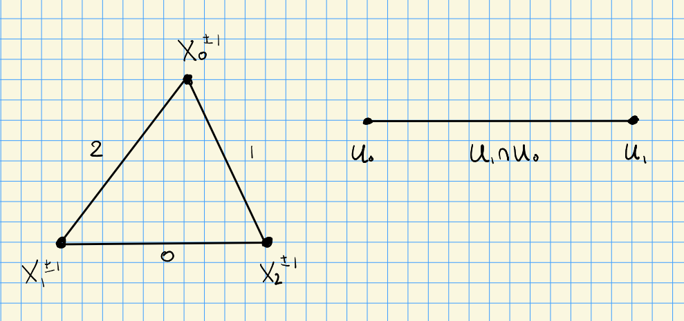

# 32 Friday, April 01

> Reference for toric geometry: Fulton’s Toric Varieties, Oda’s *Convex bodies in algebraic geometry*.

Claim from last time:
$$\begin{align*}
{ {H}^{\scriptscriptstyle \bullet}} ({\mathbb{P}}^n; {\mathcal{O}}(d)) \mathrel{\vcenter{:}}={\mathbb{R}}\Gamma({\mathbb{P}}^n; {\mathcal{O}}_{{\mathbb{P}}^n}(d)) \cong {\check{H}}({\mathcal{U}}; {\mathcal{O}}_{{\mathbb{P}}^n}(d))
,\end{align*}
where this isomorphism is of graded vector spaces. We also saw
\begin{align*}
\bigoplus _{d\in {\mathbb{Z}}} H^0({\mathbb{P}}^n; {\mathcal{O}}(d)) \cong k[x_1, \cdots, x_{n}]= \bigoplus _{\mathbf{d} \geq 0} k \prod x_i^{d_i}
,\end{align*}
and in top degree,
\begin{align*}
\bigoplus _{d\in {\mathbb{Z}}} H^n({\mathbb{P}}^n; {\mathcal{O}}(d)) \cong \prod x_i^{-1}k { \left[ \scriptstyle {x_0^{-1}, \cdots, x_n^{-1}} \right] }
,\end{align*}
with all intermediate degrees vanishing. There is a nondegenerate pairing
\begin{align*}
H^0({\mathbb{P}}^n; {\mathcal{O}}(d)) \times H^n({\mathbb{P}}^n; {\mathcal{O}}(-n-1-d)) \to k\cdot \prod x_i^{-1}\cong k
\end{align*}
which is concretely realized by multiplying monomials and projecting onto the span of \(\prod x_i^{-1}\) (so setting all other monomials to zero). This is an instance of Serre duality, but this example is in fact used in the proof.$$

Compute $\oplus_d {\check{H}}({\mathcal{U}}; {\mathcal{O}}(d))$ by first writing ${\mathbb{P}}^n = {\mathbb{A}}^n_{x_0\neq 0} \cup{\mathbb{A}}^n_{x_1\neq 0}$ and look at global sections:
$$\begin{align*}
0 \to k[x_0^{\pm 1}, x_1, \cdots, x_n] \oplus
k[x_0, x_1^{\pm 1}, x_2,\cdots, x_n] \oplus \cdots
\to k[x_0^{\pm 1}, x_1^{\pm 1}, x_2, \cdots ] \oplus \cdots
\to \cdots \to
\to k[x_0^{\pm 1}, x_1^{\pm 1}, \cdots, x_n^{\pm 1}] \to 0
,\end{align*}
where we choose 1 coordinate to invert at the 1st stage, 2 coordinate to invert at the 2nd stage, and so on. Note that this is not only \({\mathbb{Z}}{\hbox{-}}\)graded, but \({\mathbb{Z}}{ {}^{ \scriptscriptstyle\times^{n+1} } }{\hbox{-}}\) graded by monomials. The claim is that the contribution of a monomial \(\prod x_i^{d_i}\) to cohomology will only depend on the pattern of signs, i.e. \(I\mathrel{\vcenter{:}}=\left\{{k{~\mathrel{\Big\vert}~}d_k < 0}\right\} \subseteq [n]\).$$

Consider $I = \emptyset$, and the contribution of $\prod x_i^{d_i}$ with $d_i \geq 0$ for all $i$. Form a simplicial complex $X$:

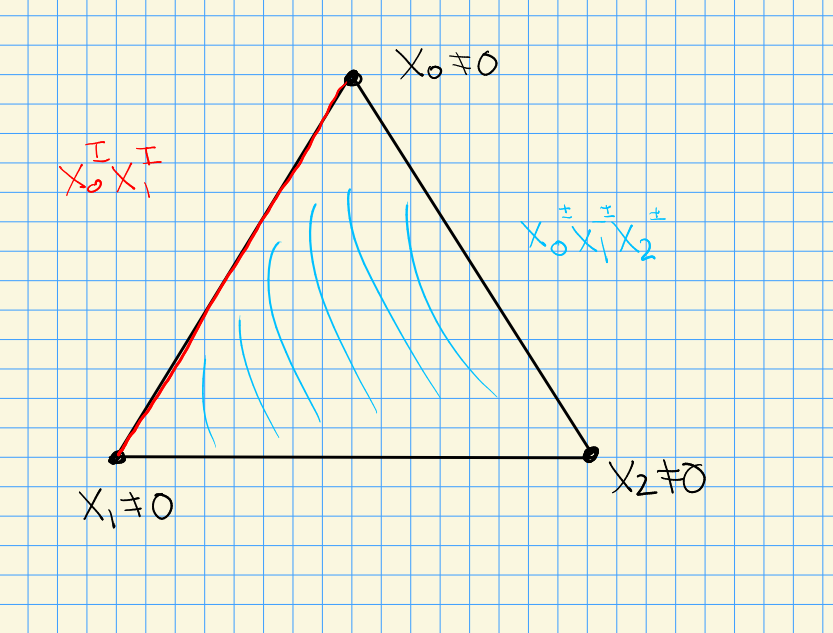

The cohomology computes ${ {H}^{\scriptscriptstyle \bullet}} _{\Delta}(X; {\mathbb{Z}}) \cong {\mathbb{Z}}$ since $X$ is contractible.

For $I = [n]$, so all $d_i < 0$, one obtains just the faces of the complex with the boundaries deleted.

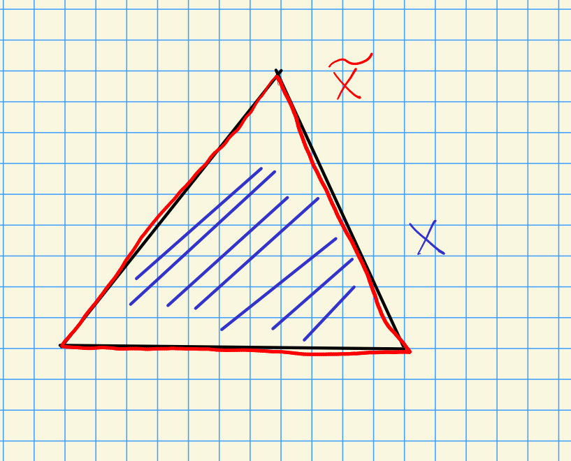

This computes ${ {H}^{\scriptscriptstyle \bullet}} _{\Delta}(X, \tilde X; {\mathbb{Z}}) \cong \tilde { {H}^{\scriptscriptstyle \bullet}} _{\Delta}(\tilde X)$ by the LES of a pair:

Recall that this LES arises from
$$\begin{align*}
0 \to C^n(\tilde X) \to C^n(X)\to C^n(X, \tilde X)\to 0
.\end{align*}$$

For $I = \left\{{0}\right\}$, so $I = \left\{{0}\right\}$ with $d_0 < 0$ and $d_i \geq 0$ for $i\geq 1$.

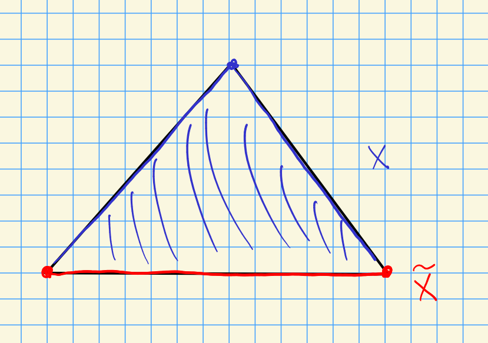

This computes ${ {H}^{\scriptscriptstyle \bullet}} _{\Delta}(X, \tilde X; {\mathbb{Z}}) \cong \tilde { {H}^{\scriptscriptstyle \bullet}} _{\Delta}(\tilde X) = 0$.

When does this trick work? For any pair $(X, L)$ with $L\in {\operatorname{Pic}}X$ where the sections are ${\mathbb{Z}}^{n+1}{\hbox{-}}$graded where each graded piece is dimension at most 1. These are referred to as **multiplicity-free**. Examples: toric varieties:

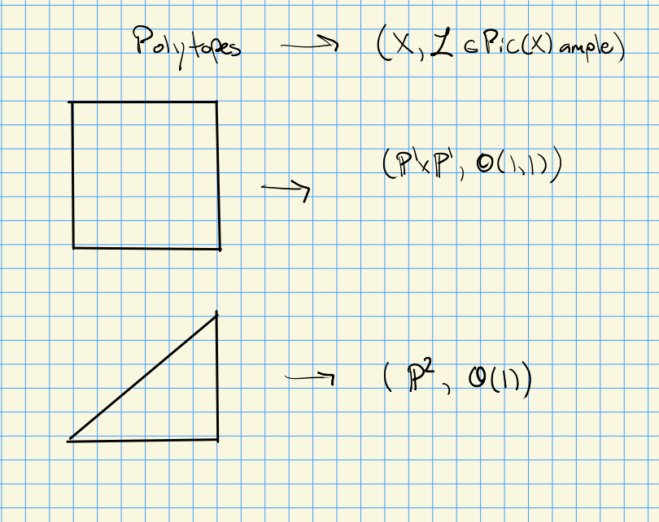

# 33 Monday, April 04

## 33.1 Riemann-Roch and Serre Duality

Let $X\in \mathop{\mathrm{Proj}}{\mathsf{Var}}_{/ {k}}$ and $F \in {\mathsf{Coh}}({\mathsf{{\mathcal{O}}_X}{\hbox{-}}\mathsf{Mod}})$. By Grothendieck, ${ {H}^{\scriptscriptstyle \bullet}} (X; F)$ is supported in degrees $0 \leq d \leq \dim X$ and $h^i = \dim_k H^d(X; F) < \infty$ for all $d$.

If $X\in {\mathsf{sm}}\mathop{\mathrm{Proj}}{\mathsf{Var}}_{/ {k}}$,
$$\begin{align*}
\chi(X; F) \mathrel{\vcenter{:}}=\sum_{0\leq i \leq \dim X} (-1)^i h^i(F) = \int_X {\mathrm{ch}}(F) \operatorname{Td} ({\mathbf{T}}_X)
.\end{align*}$$

What this formula means: for $X$ smooth projective, there is a Chow ring $A^*(X) = \bigoplus _{0\leq i \leq \dim X} A^i(X)$ where $A^i$ is analogous to $H^{2i}_{\mathrm{sing}}(X; {\mathbb{C}})$. These are often different, but sometimes coincide (which can only happen if odd cohomology vanishes). For curves, these differ, and $A^1(X) \cong {\operatorname{Pic}}(X)$ which breaks up as a discrete part (degree) and continuous part (Jacobian). Define $A^i(X) \mathrel{\vcenter{:}}={\mathbb{Z}}[C_i]\sim$ where $C_i$ are codimension $i$ algebraic cycles (subvarieties) and we quotient by linear equivalence. Recall that for divisors, $D_1\sim D_2$ if $D_1-D_2$ is the divisor of zeros/poles of a rational functions. More generally, for $Z$ of codimension $i$ and $Z \xrightarrow{f} X$, consider $f_* D_1 \sim f_* D_2$ in order to define linear equivalence.

Consider $X_4 \subseteq {\mathbb{P}}^3$ a quartic, the easiest example of a K3 surface. Then $A^0[X] = {\mathbb{Z}}[X]$, $A^1(X) = {\operatorname{Pic}}(X)$, so what is $A^2(X)$? These are linear equivalence classes of points, and any two points are equivalent if they are equivalent in the image of a curve. It’s a fact that K3s are not covered by rational curves – instead these form a countable discrete set, with finitely many in each degree. There is a formula which says that the generating function of curve counts is modular, and \begin{align*} \sum n_d x^d = {1\over x} {1\over \prod_{1\leq n\leq \infty} (1-x^n)^{24} } ,\end{align*} where $n_d$ is the number of rational curves of degree $2d$. So $A^2(X)$ is not obvious! A theorem of Mumford says that it’s torsionfree and infinitely generated. Note that $n_d = p_{24}(d+1)$ where $p_\ell({-})$ is the numbered of *colored* integer partitions

The integration map:
$$\begin{align*}
\int_X: A^{\dim X}(X) &\to {\mathbb{Z}}\\
\sum n_i p_i &\to \sum n_i
.\end{align*}$$

There are two non-homogeneous polynomials ${\mathrm{ch}}(F)$ and $\operatorname{Td} ({\mathbf{T}}_X)$ in $A^*(X)\otimes_{\mathbb{Z}}{\mathbb{Q}}$, and the formula for Riemann-Roch says to multiply and extract only the top-dimensional component, i.e. take $\deg({\mathrm{ch}}(F) \operatorname{Td} ({\mathbf{T}}_X))_{\dim X}$. This is very computable!

A Chern class: if $F = {\mathcal{O}}_X(D)$, then
$$\begin{align*}
{\mathrm{ch}}(F) = e^D = \sum_{1\leq i\leq n} D^i/i!
\end{align*}
where
\begin{align*}
{\mathcal{O}}_X(D)(U) = \left\{{ f\in {\mathcal{O}}_X(U) {~\mathrel{\Big\vert}~}(f) + D \geq 0}\right\}
\end{align*}
and \(D^n = D \smile D \smile\cdots \smile D\) is the \(n{\hbox{-}}\)fold self-intersection of \(D\). Note that \(c_1(F) = D\).$$

The Chern character of $F$ is additive on SESs, i.e. $0\to A\to B\to C\to 0$ yields ${\mathrm{ch}}(B) = {\mathrm{ch}}(A) + {\mathrm{ch}}(C)$.

If $X$ is a smooth projective curve,
$$\begin{align*}
h^0(X) - h^1(X) = \deg D - g(X) + 1
.\end{align*}
In this case, \({\mathrm{ch}}(F) = 1+D\) and \(\operatorname{Td} ({\mathbf{T}}_X) = 1 + (1-g)[{\operatorname{pt}}]\) where \([{\operatorname{pt}}]\) is a certain well-defined divisor in \(A^1(X)\). One can rewrite this as \(\operatorname{Td} _X = 1 + {1\over 2}c_1 = 1 - {1\over 2} K_X\) (the canonical class, where \(\deg K_X = 2g-2\)). This uses that
\begin{align*}
c_1 = c_1({\mathbf{T}}_X) = -c_1(\Omega_X) = -K_X
.\end{align*}$$

For $X$ a smooth surface,

- ${\mathrm{ch}}(F) = 1 + D + {D\over 2}$
- $\operatorname{Td} ({\mathbf{T}}_X) = 1 - {1\over 2}c_1 + {1\over 12}(c_1^2 + c_2)$,

thus
$$\begin{align*}
\chi(X; {\mathcal{O}}_X(D)) = {D(D-2) \over K} + \chi(X; {\mathcal{O}}_X)
.\end{align*}$$

For $X = {\mathbb{P}}^2$ with $F = {\mathcal{O}}(d)$, note

- $K_X = {\mathcal{O}}(-3)$
- $h^0({\mathcal{O}}_X) = 1, h^1({\mathcal{O}}_X) = h^2({\mathcal{O}}_X) = 0$

So
$$\begin{align*}
\chi(X; {\mathcal{O}}(d)) = {d(d+3) \over 2} +1 = {d+2\choose 2}
.\end{align*}
As a corollary, for \(d\geq 0\),
\begin{align*}
h^0({\mathcal{O}}_{{\mathbb{P}}^n}(d)) = {d+n\choose n}
.\end{align*}$$

# 34 Friday, April 08

## 34.1 Vanishing theorems

Setup: $X\in \mathop{\mathrm{Proj}}{\mathsf{Var}}_{/ {k}} , {\mathcal{F}}\in {\mathsf{Sh}}(X; {\mathsf{Ab}}{\mathsf{Grp}})$. What is $H^0(X; {\mathcal{F}})$? Note that if
$$\begin{align*}
\chi(X; {\mathcal{F}}) \mathrel{\vcenter{:}}=\sum_k (-1)^k h^k(X; {\mathcal{F}})
,\end{align*}
if \(\tau_{\geq 1} { {H}^{\scriptscriptstyle \bullet}} (X;{\mathcal{F}}) = 0\) then this \(\chi(X;{\mathcal{F}}) = h^0(X; {\mathcal{F}})\). By Serre duality, \(h^n(X;{\mathcal{F}}) = h^0(\omega_X \otimes{\mathcal{F}}^{-1})\) which holds if \(X\) is Gorenstein, e.g. a locally complete intersection.$$

Recall that ${\mathcal{O}}_X(D)(U) = \left\{{\phi {~\mathrel{\Big\vert}~}(\phi) + D \geq 0}\right\}$. Note that if ${\mathcal{F}}= {\mathcal{O}}(D)$ then $h^0(X;{\mathcal{F}})\neq 0 \iff D\sim D'$ where $D' > 0$ is effective.

If $D\sim D'$ where $-D' > 0$ is effective, then $h^0(X; {\mathcal{O}}(D)) = 0$. Note that if $D \subseteq X \subseteq {\mathbb{P}}^N$ is projective, take $H \subseteq {\mathbb{P}}^N$ and ${\mathcal{O}}_{{\mathbb{P}}^N}(1) = {\mathcal{O}}_{{\mathbb{P}}^N}(H)$ and intersect to obtain $D \cdot H^{n-1} = \deg D$.

If $X$ is a smooth projective curve and ${\mathcal{F}}= {\mathcal{O}}_X(D)$ is a line bundle. Riemann-Roch yields
$$\begin{align*}
h^0(X;{\mathcal{F}}) - h^1(X;{\mathcal{F}}) = \deg D -g + 1
\end{align*}
and
\begin{align*}
\deg D = h^0(D) - h^0(K_X - D)
\implies \deg(K_X - D) = 2g-2 - \deg D
.\end{align*}$$

If $X$ is a smooth projective curve,

- ${\mathcal{O}}_X(D)$ is ample $\iff D > 0$ (some large multiple is a hyperplane section).
- ${\mathcal{O}}_X(D)$ is very ample $\impliedby \deg D \geq 2g-2+3$ (very ample: some multiple is ample).

There exists an embedding $X\hookrightarrow{\mathbb{P}}^N$, and ${\mathcal{O}}_X(D) = {\mathcal{O}}_X(1) = {\mathcal{O}}_{{\mathbb{P}}^N}(1)\mathrel{\Big|}_X$. One can show $h^0(D - {\operatorname{pt}}) < h^0(D)$.

An effective but not ample divisor: take two lines in ${\mathbb{P}}^1\times {\mathbb{P}}^1$ which do not intersect.

Suppose $X\in{\mathsf{sm}}\mathop{\mathrm{Proj}}{\mathsf{Var}}_{/ {k}}$ where $k={\mathbb{C}}$ or $\operatorname{ch}k = 0$ with $k= { \mkern 1.5mu\overline{\mkern-1.5muk\mkern-1.5mu}\mkern 1.5mu }$ and let ${\mathcal{F}}= \omega_X(L)$ with $L$ ample. Then
$$\begin{align*}
\tau_{\geq 1} { {h}^{\scriptscriptstyle \bullet}} (X;{\mathcal{F}}) = 0
.\end{align*}$$

A note on the proof: uses Deligne-Illusie and liftability from Witt vectors. This liftability holds for all curves, all K3s, and some Calabi-Yau threefolds.

For curves, $h^1(X; \omega_X(L)) = h^0(-L)$.

Let $X \in {\mathsf{sm}}\mathop{\mathrm{Proj}}{\mathsf{Var}}_{/ {{\mathbb{C}}}}$ with $D = \cup_k D_K$ normal crossing union of smooth divisors and write its formal boundary as $\Delta \mathrel{\vcenter{:}}=\sum a_i D_i$ with $0 < a_i < 1$ and $a_i \in {\mathbb{Q}}$. Suppose ${\mathcal{F}}\equiv K_X + \Delta + A$ for $A$ ample, then
$$\begin{align*}
\tau_{\geq 1} { {h}^{\scriptscriptstyle \bullet}} (X; {\mathcal{F}}) = 0
.\end{align*}$$

Say $X$ has **klt singularities** (Kawamata log terminal) iff there exists a projective morphism $Y \xrightarrow{f} X$ with $Y\supseteq\cup_i D_i$ with each $D_i$ snc, and $f^* K_X = K_Y + \Delta$. Generally $Y$ is smooth and $f$ is a resolution.

A note on the MMP: take $X_0$ a variety, produce a variety $X$ with $K_X$ nice, e.g. $-K_X > 0$ or $K_X \geq 0$ numerically. At each stage, contract a curve (the result is a $-1$ curve) are perform a **flip**. So if $C \in X_0$, produce $X_0 \to X_1$ with $CK_X < 0$.

# 35 Monday, April 11

## 35.1 Spectral sequences

If $f\in {\mathsf{Top}}(X, Y)$ and ${\mathcal{F}}\in {\mathsf{Sh}}(X; {\mathsf{Ab}}{\mathsf{Grp}})$, there is a spectral sequence
$$\begin{align*}
E_2^{p, q} = H^p(X; {\mathbb{R}}^{q} f_* {\mathcal{F}}) \Rightarrow H^{p+q}(X; {\mathcal{F}})
.\end{align*}$$

If $0 \to A\leftleftarrows { {J}^{\scriptscriptstyle \bullet}}$ is an injective resolution of a sheaf $A$, then $E_1^{p, q} = H^p(J^q) \Rightarrow H^{p+q}(A)$. More generally, for any functor $F \in \mathsf{Cat}(\mathsf{A}, \mathsf{B})$,
$$\begin{align*}
E_1^{p, q} = {\mathbb{R}}^p F(J^q) \Rightarrow{\mathbb{R}}^{p+q} F(A)
.\end{align*}$$

So if $J^q$ are $F{\hbox{-}}$acyclic, then $\tau_{\geq 1} { {{\mathbb{R}}}^{\scriptscriptstyle \bullet}} F(J^q) = 0$ and thus ${\mathbb{R}}^n F(A)$ is the homology of the complex $F { {J}^{\scriptscriptstyle \bullet}}$.

If

- $\mathsf{A} \xrightarrow{F} \mathsf{B} \xrightarrow{G} \mathsf{C}$ are left-exact functors between abelian categories
- $\mathsf{A}, \mathsf{B}$ have enough injectives, and
- $F(I)$ for $I$ injective in $\mathsf{A}$ yields a $G{\hbox{-}}$acyclic object in $\mathsf{B}$,

then there is a first-quadrant spectral sequence

[figure not shown]

> [Link to Diagram](https://q.uiver.app/?q=WzAsNCxbMCwwLCIwIl0sWzIsMCwial8hXFxyb3sgXFxPT19YIH17VX0iXSxbNCwwLCJcXE9PX1giXSxbMiwyLCJJIl0sWzAsMV0sWzEsMl0sWzIsMywiIiwwLHsic3R5bGUiOnsiYm9keSI6eyJuYW1lIjoiZGFzaGVkIn19fV0sWzEsM11d)

Recall that cohomology vanishes above the dimension of a Noetherian space. The analog for pushforward involves the relative dimension.

General setup:

- $d_r: E_r^{p, q} \to E_r^{p+r, q-r+1}$ (down and to the right) moves between diagonals.
  - For a fixed $p, q$, all differentials out of $E_{p, q}$ land on the same diagonal.
- $E_{r+1} = H(E_r, d_r)$.
- Letting $E_n = \bigoplus_{p+q=n} E_\infty^{p, q}$, there is a descending filtration ${ {{\operatorname{Fil}}}_{\scriptscriptstyle \bullet}} E_n$ such that ${\mathsf{gr}\,}_p { {{\operatorname{Fil}}}_{\scriptscriptstyle \bullet}} E_n \mathrel{\vcenter{:}}={\operatorname{Fil}}_p E_n/ {\operatorname{Fil}}_{p+1} E_n = E_\infty^{p, n-p}$.
- Extension problem: ${\mathbb{Z}}\supseteq 2{\mathbb{Z}}\supseteq 0$ where ${\mathsf{gr}\,}_1 = C_2$ and ${\mathsf{gr}\,}_1 \cong {\mathbb{Z}}$, but another group and filtration may have the same associated graded, e.g. ${\mathbb{Z}}\oplus C_2 \supseteq{\mathbb{Z}}\supseteq 0$.
- Double complexes naturally arise by taking an injective resolution $A \leftleftarrows { {J}^{\scriptscriptstyle \bullet}}$ and individually resolving the pieces by $J^n \leftleftarrows C^{n, \bullet}$. Writing ${ \operatorname{Tot} }(C^{p, q})_n \mathrel{\vcenter{:}}=\oplus_{p+q=n} C^{p, q}$, there are maps $A\to C^{0,0} \to (C^{0,1} \oplus C^{1, 0}) \to \cdots$ by summing horizontal and vertical differentials. Using the sign trick makes this a differential (multiply the vertical differentials in every even column by $-1$).
- There are spectral sequences
  $$\begin{align*}
  E_1{p, q} &= H^p(C^{\bullet, q}, d_h) \Rightarrow H^{p+q}( { \operatorname{Tot} }( C^{\bullet, \bullet} ) ) \\
  E_1{p, q} &= H^q(C^{p, \bullet}, d_v) \Rightarrow H^{p+q}( { \operatorname{Tot} }( C^{\bullet, \bullet} ) )
  .\end{align*}$$
  - Why this is useful: resolve $A$ by $J$ which are not necessarily injective, and resolve each $J^n$ by injectives, then ${ \operatorname{Tot} }$ is now an injective resolution.

# 36 Wednesday, April 13

## 36.1 Spectral sequences continued

Recall that for spectral sequences, the diagonal entries $p+q=n$ are the successive quotients in a filtration on $E^n\mathrel{\vcenter{:}}={ \operatorname{Tot} }(E_\infty^{\bullet, \bullet})_n$. Kodaira vanishing: for the original argument, go to characteristic $p$ and look at liftability.

We’ll have some spectral sequence which we’ll want to degenerate at $E_2$. It STS that $d_r = 0$ for $r\geq 1$, which in fact forces $(E, d)$ to degenerate at $E_1$. Strategy: find another spectral sequence $(E', d')$ with the same $E_1' \cong E_1$ and a differential $d\neq d'$ which converges to the same thing and more patently stabilizes at $E_1'$. It then follows that $E$ stabilizes at $E_1$. Note the $\dim_k E_r^{p, q} \leq \dim_{k} E_{r-1}^{p, q}$ since we’re taking kernels mod images.

Suppose $E_2^{p, q} \Rightarrow E^n$ for $n=p+q$ is first quadrant. Then

- $E_2^{0, 0} = E^{\infty}_{0,0}$ and $E_2^{1,0} = E_\infty^{1, 0}$.
- $E_3^{0, 1} = E_\infty^{0, 1}$ and $E_3^{2, 0} = E_\infty^{2, 0}$
- There is a 5-term exact sequence
  $$\begin{align*}
  0\to E_2^{1,0} \to E^1\to E_2^{0, 1} \to E_2^{2, 0} \to E^2
  .\end{align*}$$

The Leray spectral sequence: for $f\in {\mathsf{Top}}(X, Y)$ and ${\mathcal{F}}\in {\mathsf{Sh}}(X; { \mathsf{Vect}_{/ {k}} })$,
$$\begin{align*}
E_2^{p, q} = H^p(Y; {\mathbb{R}}^q f_* {\mathcal{F}}) \Rightarrow H^{p+q}(X; {\mathcal{F}})
.\end{align*}
This yields
\begin{align*}
0 \to H^1(X; f_* {\mathcal{F}}) \to H^1(X;{\mathcal{F}}) \to H^0(X; {\mathbb{R}}^1 f_* {\mathcal{F}}) \to H^2(X; f_*{\mathcal{F}}) \to H^2(F)
.\end{align*}$$

Consider the filtration on $E_\infty$:

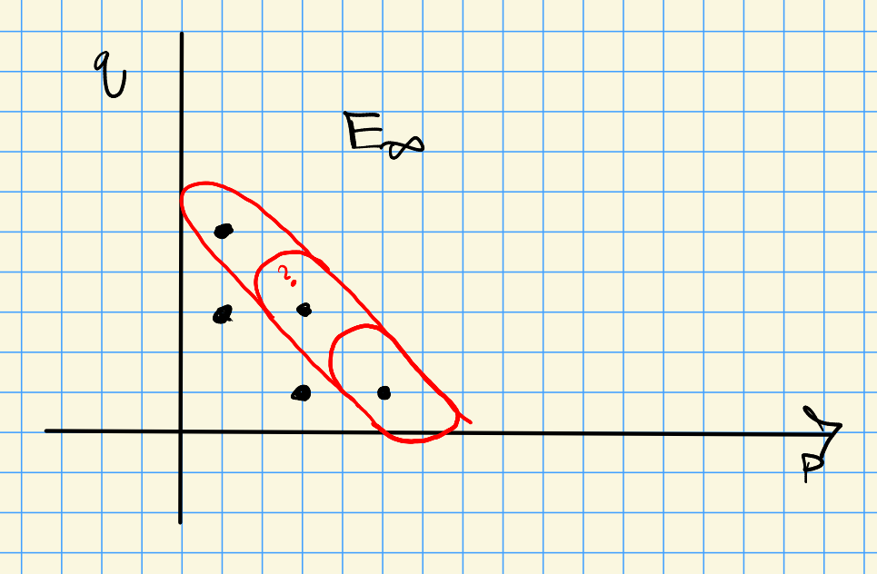

This yields exact sequences

- $0 \to E_\infty^{1, 0} \to E^1\to E_\infty^{0, 1} \to 0$
- $0\to E_\infty^{2, 0} \to ? \to E_\infty^{1, 1} \to 0$
- $0\to ? \to E^2\to E_\infty^{0, 2}\to 0$.

Recall the definition of a double complex: $(C^{\bullet, \bullet}, d_h, d_v)$ where each row is a complex for $d_h$ and each column for $d_v$, and each square skew-commutes. Note that the sign trick does not change the cohomology. The totalized complex is is $({ \operatorname{Tot} }(C), {{\partial}})$ where $C^n \mathrel{\vcenter{:}}=\bigoplus _{p+q=n} C^{p, q} \xrightarrow{{{\partial}}} C^{n+1} \mathrel{\vcenter{:}}=\bigoplus_{p+q=n+1} C^{p, q}$ and the differential is constructed from $C^{p, q} \xrightarrow{d_h \oplus d_v} C^{p+1, q} \oplus C^{p, q+1}$. There is a descending filtration ${ {{\operatorname{Fil}}}_{\scriptscriptstyle \bullet}} { \operatorname{Tot} }(C)$ where ${\operatorname{Fil}}_n { \operatorname{Tot} }(C) = \tau_{\geq n, \bullet} { \operatorname{Tot} }(C) = \bigoplus _{p\geq n} C^{p, q}$, which is the double complex obtained by truncating all columns to the left of column $n$.

# 37 Friday, April 15

## 37.1 Filtrations and Gradings

Given ${\operatorname{Fil}}A$ a descending filtration, define ${\mathsf{gr}\,}_i A \mathrel{\vcenter{:}}={\operatorname{Fil}}_i A/ {\operatorname{Fil}}_{i+1} A$. Convention: everywhere we’ll set $p+q\mathrel{\vcenter{:}}= n, p = n-q$, etc.

This results in a collection of short exact sequences:
$$\begin{align*}
0 \to {\operatorname{Fil}}_{i+1} A\to {\operatorname{Fil}}_i A \to {\mathsf{gr}\,}_i A \to 0
.\end{align*}$$

Our main example: a double complex ${ {C}^{\scriptscriptstyle \bullet, \bullet}}$ with ${ {A}^{\scriptscriptstyle \bullet}} \mathrel{\vcenter{:}}= { {{ \operatorname{Tot} }}^{\scriptscriptstyle \bullet}} { {C}^{\scriptscriptstyle \bullet, \bullet}}$ with $A^n \mathrel{\vcenter{:}}=\oplus _{p+q=n} C^{p ,q}$ and differentials ${{\partial}}= (d_v, d_h)$ producing skew-commuting squares. The main question is computing $H^*(A)$.

Each $A^n$ is a filtration ${\operatorname{Fil}}A^n$ where ${{\partial}}{\operatorname{Fil}}^i A^n \subseteq {\operatorname{Fil}}^{i+1} A^n$. The filtration is defined by
$$\begin{align*}
{\operatorname{Fil}}^{p_0} A^n = \bigoplus _{p+q=n, p\geq p_0} C^{p, q}
,\end{align*}
taking everything to the right of column \(p_0\). The claim is that this induces a filtrations on \(Z^n(A), B^n(A), H^n(A)\) (cycles, boundaries, and homology). One can restrict the differential on \({ {A}^{\scriptscriptstyle \bullet}}\) to \({\operatorname{Fil}} { {A}^{\scriptscriptstyle \bullet}}\); note that cycles \(Z_n\mapsto 0\) and boundaries are the image and we’re taking cycles mod boundaries. Writing \({\operatorname{Fil}}^p Z^n \mathrel{\vcenter{:}}={\operatorname{Fil}}^p A^n \cap Z_n\) and similarly for \(B^n, H^n\), one gets a filtration \({\operatorname{Fil}}H({\operatorname{Fil}}^p A)\) on \(H({\operatorname{Fil}}^p A)\). This yields
\begin{align*}
E_\infty^{p, q} = {\mathsf{gr}\,}_p H^n = {\operatorname{Fil}}^p H^n / {\operatorname{Fil}}^{p+1} H^n
.\end{align*}
If all of the SESs split, then \(H^n = \bigoplus _{p+q=n} E^{p, q}_\infty\).$$

Set

- $E_0^{p, q} \mathrel{\vcenter{:}}= C^{p, q}$
- $E_1^{p, q} = H^n( C^{p, \bullet}, d_v )$.
- $E_2^{p, q} = H^n( E_1^{p, q}, d_v) = H^*(\cdots\to H^{n-1}C^{p, \bullet} \to H^n(C^{p, \bullet}) \to H^{n+1} C^{p+1,\bullet}\to \cdots )$.

What are the cycles in $E_0$? To map to zero under the total differential ${\partial}$, things emanating from column $p$ must go to zero, and for the columns $p+k$, images under $d_h^{p+k, \ell}$ must cancel with images under $d_h^{p+k+1, \ell-1}$. Define the *approximate homology* \begin{align*} {\operatorname{Fil}}^p H^{\approx}_{p \pm r} = {{\partial}^{-1}({\operatorname{Fil}}^{p+r} A^{n+1} ) \over {\partial}({\operatorname{Fil}}^{p-r+1} A^{n-1} ) } .\end{align*} Note that this *increases* the number of allowed cycles and *decreases* the number of allowed boundaries. Then $E_r^{p, q} = {\mathsf{gr}\,}_p H^n_{p \pm r}$.

Note that the statement is not the $E_r$ is computed as $H^*(E_{r-1})$; instead there is a formula for $E_r^{p, q}$ for all $r,p,q$ a priori, and it is a property that taking homology of pages computes this.

Claim: ${\mathsf{gr}\,}_p H^n_{p\pm 0} = C^{p, q}$. Check that
$$\begin{align*}
{\operatorname{Fil}}^{p_0} H^n_{p\pm 0} = {\bigoplus _{p+q=n, p\geq p_0} C^{p, q} \over d\qty{ \bigoplus _{p+q=n-1, p\geq p_0 + 1} C^{p, q} } }
.\end{align*}$$

# 38 Monday, April 18

## 38.1 Spectral Sequences

A filtered complex:

[figure not shown]

> Link to Diagram

This yields
$$\begin{align*}
H^n_{p\pm r} &= {A^n \cap d^{-1}({\operatorname{Fil}}^{p+r} A^{n+1} ) \over A^n \cap d({\operatorname{Fil}}^{p-r+1} A^{n+1} ) } \\ \\
H^n_{p \pm \infty} &= {A^n \cap d^{-1}(0) \over A^n \cap d(A^{n+1}) }
.\end{align*}$$

Notation: write
$$\begin{align*}
{}^n E^p_r \mathrel{\vcenter{:}}= E_{r}^{p, q} = {\mathsf{gr}\,}^p H^n_{p\pm r} =
{
{\operatorname{Fil}}^p A^{n} \cap d^{-1}\qty{ {\operatorname{Fil}}^{p+r} A^{n+1} }
\over
{\operatorname{Fil}}^{p+1} A^n \cap d^{-1}({\operatorname{Fil}}^{p+r} A^{n+1} ) + {\operatorname{Fil}}^p A^{n} \cap d^{-1}\qty{{\operatorname{Fil}}^{p-r+1} A^{n-1} }
}
.\end{align*}$$

The main properties:

- $d_r: E_r^{p, q} \to E_r^{p+r, q-r+1}$
- $H( { {E_r}^{\scriptscriptstyle \bullet, \bullet}} , d_r) = { {E_{r+1}}^{\scriptscriptstyle \bullet, \bullet}}$.

Note that ${}^n E^p_r \xrightarrow{ d_r} {}^{n+1}E^{p+r}_r$, so
$$\begin{align*}
{
{\operatorname{Fil}}^p A^{n} \cap d^{-1}\qty{ {\operatorname{Fil}}^{p+r} A^{n+1} }
\over
{\operatorname{Fil}}^{p+1} A^n \cap d^{-1}({\operatorname{Fil}}^{p+r} A^{n+1} ) + {\operatorname{Fil}}^p A^{n} \cap d^{-1}\qty{{\operatorname{Fil}}^{p-r+1} A^{n-1} }
}
\xrightarrow{d_r}
{
{\operatorname{Fil}}^{p+r} A^{n+1} \cap d^{-1}\qty{ {\operatorname{Fil}}^{p+2r} A^{n+2} }
\over
{\operatorname{Fil}}^{p+r+1} A^{n+1} \cap d^{-1}({\operatorname{Fil}}^{p+2r} A^{n+2} ) + \cdots
}
,\end{align*}
and \(d_r^2 = 0\) since the first denominator above appears as the next numerator.$$

## 38.2 Applications

An application: consider a 2-step resolution $0 \to A \to J^0 \to J^1$, and take injective resolutions of each $J^i$ to form an $E_0$:

[figure not shown]

> Link to Diagram

Then $0 \to A\to { {{ \operatorname{Tot} }}^{\scriptscriptstyle \bullet}} ( { {A}^{\scriptscriptstyle \bullet, \bullet}} )$ is exact, i.e. this is an injective resolution of $A$. Take vertical cohomology to get $E_1$:

[figure not shown]

> Link to Diagram

Since no functor has been applied, we obtain the follow $E_2$ after taking horizontal cohomology:

[figure not shown]

> Link to Diagram

So $H^n({ \operatorname{Tot} }I) = A[0]$.

Let $F\in \mathsf{Cat}(A, B)$ be additive left-exact, then ${\mathbb{R}}^n FA = H^n(F{ \operatorname{Tot} } { {I}^{\scriptscriptstyle \bullet, \bullet}} )$ for $0\to A\to I$ a biresolution as above. Define $E_0 = FI$, then $E_1^{p, q} = {\mathbb{R}}^q F J^p$.

If $J^p$ are $F{\hbox{-}}$acyclic, then $E_1$ has the form

[figure not shown]

> Link to Diagram

So $E_2^{p, q} = H^q(FJ^p)$, i.e. ${\mathbb{R}}F A$ can be compute using the resolution $0\to A\to { {J}^{\scriptscriptstyle \bullet, \bullet}} \to \cdots$. For example, for $F({-}) = {{\Gamma}\qty{X; {-}} }$, we can resolve by flasque, soft, or fine sheaves.

Using two spectral sequences for a single bicomplex: given ${ {C}_{\scriptscriptstyle \bullet, \bullet}}$,
$$\begin{align*}
E_2^{p, q} = H_h^{p} H_v^q C^{p, { \scriptscriptstyle \bullet} } &\Rightarrow H^n({ {{ \operatorname{Tot} }}_{\scriptscriptstyle \bullet}} { {C}_{\scriptscriptstyle \bullet, \bullet}} ) \\
E_2^{p, q} = H^q_v H^p_h C^{{ \scriptscriptstyle \bullet}, q} &\Rightarrow H^n({ {{ \operatorname{Tot} }}_{\scriptscriptstyle \bullet}} { {C}_{\scriptscriptstyle \bullet, \bullet}} )
.\end{align*}$$

Grothendieck spectral sequences: for $\mathsf{A} \xrightarrow{F} \mathsf{B} \xrightarrow{G} \mathsf{C}$, form the composite $\mathsf{A} \xrightarrow{GF} \mathsf{C}$ to obtain
$$\begin{align*}
E_2^{p, q} = {\mathbb{R}}^p G {\mathbb{R}}^q F A \Rightarrow{\mathbb{R}}^{p+q} GFA
,\end{align*}
provided \(F\) sends injectives to \(G{\hbox{-}}\)acyclics. This comes from running the two spectral sequences above, where one collapses onto a single row.$$

# 39 Wednesday, April 20

## 39.1 Derived Categories

Recall how to construct derived functors. It is advantageous to embed $\mathsf{C} \hookrightarrow\mathsf{Ch}\mathsf{C}$ and resolve by nicer objects. A complex contains strictly more information than homology: e.g. $0\to {\mathbb{Z}}\xrightarrow{\cdot 2} {\mathbb{Z}}\to 0$ and $0 \to {\mathbb{Z}}\hookrightarrow{\mathbb{Z}}\oplus {{\mathbb{Z}}\over 2{\mathbb{Z}}}\to 0$ have isomorphic homology but aren’t isomorphic as complexes.

A morphism $f\in \mathsf{Ch}\mathsf{C}(A, B)$ is a **quasi-isomorphism** iff the induced map $f^*\in \mathsf{Ch}\mathsf{C}( { {H}^{\scriptscriptstyle \bullet}} A, { {H}^{\scriptscriptstyle \bullet}} B)$ is an isomorphism.

There is a category ${\mathbb{D}}\mathsf{C}$ and a functor $\mathsf{Ch}\mathsf{C}\to {\mathbb{D}}\mathsf{C}$ with the following universal property: if $\mathsf{Ch}\mathsf{C} \to \mathsf{B}$ is any functor sending quasi-isomorphisms to isomorphisms, there is a unique functor ${\mathbb{D}}\mathsf{C} \to B$ factoring it. We call ${\mathbb{D}}\mathsf{C}$ the **derived category** of $\mathsf{C}$.

The basic morphisms in ${\mathbb{D}}\mathsf{C}$ are given by usual chain maps $f:A\to B$, and if $f$ is a quasi-isomorphism we formally add inverses $X_f: B\to A$. A general morphism is a sequence of morphisms $\bullet \to \bullet \to \cdots \to \bullet$ where we quotient by

- $\bullet \xrightarrow{f} \bullet \xrightarrow{g} \bullet \sim \bullet \xrightarrow{g f} \bullet$
- $A \xrightarrow{f} B \xrightarrow{X_f} A \sim A \xrightarrow{\operatorname{id}} A$
- $B \xrightarrow{X_f} A \xrightarrow{f} B \sim B \xrightarrow{\operatorname{id}} B$.

One would like a calculus of fractions, so define:

Given $\mathsf{C}\in \mathsf{Cat}$, and subset $S \subseteq \mathop{\mathrm{Mor}}(\mathsf{ C})$ of morphisms is **localizing** iff

- $\operatorname{id}_A \in S$ for all objects $A$
- $S$ is closed under compositions
- For every roof with $f$ arbitrary and $s\in S$, there exist arrows:

[figure not shown]

> Link to Diagram

As a corollary, arrows in $\mathsf{C}{ \left[ { \scriptstyle \frac{1}{S} } \right] }$ are roofs modulo equivalence.

The set $S$ of quasi-isomorphisms in $\mathsf{Ch}\mathsf{A}$ is localizing.

Note that we can take

- $\mathsf{Ch}\mathsf{C}:$ all complexes,
- $\mathsf{Ch}^+\mathsf{C}:$ complexes bounded from below,
- $\mathsf{Ch}^-\mathsf{C}:$ complexes from above,
- $\mathsf{Ch}^b\mathsf{C}:$ complexes from above and below.

These yield derived categories ${\mathbb{D}}\mathsf{C}, {\mathbb{D}}^+\mathsf{C}, {\mathbb{D}}^-\mathsf{C}, {\mathbb{D}}^b\mathsf{C}$. Note: frequently ${\mathbb{D}}\mathsf{C}$ actually means ${\mathbb{D}}^+\mathsf{C}$ in the literature. When ${\mathbb{D}}^b\mathsf{C}$ is used: if ${\mathcal{F}}\in {\mathsf{Coh}}(X)$ and $X$ is projective, which corresponds to a graded module which (by Hilbert) has a finite resolution.

One can similarly define homotopy categories ${\mathsf{ho}}\mathsf{Ch}\mathsf{C}, {\mathsf{ho}}\mathsf{Ch}^+\mathsf{C}, {\mathsf{ho}}\mathsf{Ch}^-\mathsf{C}, {\mathsf{ho}}\mathsf{Ch}^b\mathsf{C}$ with ${\operatorname{Ob}}( {\mathsf{ho}}\mathsf{Ch}\mathsf{C} ) \mathrel{\vcenter{:}}={\operatorname{Ob}}(\mathsf{Ch}\mathsf{C})$ and $\mathop{\mathrm{Mor}}({\mathsf{ho}}\mathsf{Ch}\mathsf{C}) \mathrel{\vcenter{:}}=\mathop{\mathrm{Mor}}({\mathsf{ho}}\mathsf{Cat}{C})/\sim$ where $\sim$ denotes chain homotopy equivalence.

${\mathbb{D}}^+\mathsf{A} \cong {\mathsf{ho}}\mathsf{Ch}^+\mathsf{\mathsf{ I_A} }$ where $\mathsf{I_A}$ is the homotopy category of complexes of injective objects in $\mathsf{Ch}\mathsf{A}$.

Generally there is a functor ${\mathsf{ho}}\mathsf{Ch}\mathsf{A} \hookrightarrow{\mathbb{D}}\mathsf{A}$ since chain homotopy equivalences induce isomorphisms on homology (where we apply the universal property of ${\mathbb{D}}\mathsf{A}$) There is also a functor ${\mathbb{D}}\mathsf{A}\to {\mathsf{ho}}\mathsf{Ch}\mathsf{A}$ where $A\mapsto { \operatorname{Tot} }( { {I}^{\scriptscriptstyle \bullet, \bullet}} )$ is a quasi-isomorphism.

# 40 Friday, April 22

Recall that for $S\subseteq \mathop{\mathrm{Mor}}(\mathsf{C})$, there is a localized category $\mathsf{C} \left[ { \scriptstyle { {S}^{-1}} } \right]$ whose morphisms are chains $s_0^{-1}\circ f_0 \circ s_1^{-1}\circ \cdots$ modulo an equivalence, and if $S$ is **localizing** then

- Morphisms are single roofs (i.e. we can collect the product fraction involving $s_i, f_i$ into a single fraction).
  - Note that roofs can be multiplied, and roofs are equivalent when they admit a common roof:

[figure not shown]

> Link to Diagram
- Morphisms are equivalent when they admit a common roof:

[figure not shown]

> Link to Diagram
- If $\mathsf{C}\in {\mathsf{Add}}\mathsf{Cat}$ then $\mathsf{C} \left[ { \scriptstyle { {S}^{-1}} } \right] \in {\mathsf{Add}}\mathsf{Cat}$, where the calculus of fractions behaves as in ring localization: ${f_1\over s} + {f_2\over s} = {f_1+f_2\over s}$.
- If $I \leq \mathsf{C}$ is a full subcategorya nd $S$ is *compatible*, i.e. $S \cap\mathop{\mathrm{Mor}}(I)$ is localizing, then $I \left[ { \scriptstyle { {S}^{-1}} } \right] \leq \mathsf{C} \left[ { \scriptstyle { {S}^{-1}} } \right]$ is a full subcategory.

$\mathsf{Ch}\mathsf{C}$ with $S$ quasi-isomorphisms yields ${\mathbb{D}}\mathsf{A}\mathrel{\vcenter{:}}=\mathsf{C} \left[ { \scriptstyle { {S}^{-1}} } \right]$.

The collection $S$ of quasi-isomorphisms is localizing.

${\mathbb{D}}\mathsf{A}$ is additive and morphisms are roofs in $\mathsf{Ch}\mathsf{A}$.

$I$ defined as ${\mathsf{ho}}\mathsf{Ch}\mathsf{C}^{\mathrm{inj}}$, the homotopy category of complexes of injective objects, is compatible with $S$.

$I \left[ { \scriptstyle { {S}^{-1}} } \right] \leq \mathsf{A} \left[ { \scriptstyle { {S}^{-1}} } \right] = {\mathbb{D}}\mathsf{A}$, with an equivalence if $\mathsf{A}$ has enough injectives.

These last two theorems do *not* hold just for $I = \mathsf{Ch}\mathsf{C}^{\mathrm{inj}}$.

An application: for $F\in {\mathsf{Ab}}\mathsf{Cat}(\mathsf{A}, \mathsf{B})$ additive (with no left/right exactness conditions), there is a derived functor ${\mathbb{D}}F\in \mathsf{{\mathbb{D}}^+ \mathsf{A}, {\mathbb{D}}^+ \mathsf{B}}$ if $\mathsf{A}$ has enough injectives. Note that ${\mathbb{D}}\mathsf{A}$ is never abelian but admits a triangulated structure.

For $X\in {\mathsf{sm}}\mathop{\mathrm{Proj}}{\mathsf{Var}}_{/ {k}}$, the usual notation is ${\mathbb{D}}(X) \mathrel{\vcenter{:}}={\mathbb{D}}^b{\mathsf{Coh}}(X)$. Global sections $\Gamma\in \mathsf{Cat}({\mathsf{Coh}}X\to {\mathsf{Ab}}{\mathsf{Grp}})$ induce a derived functor ${\mathbb{R}}\Gamma\in \mathsf{Cat}({\mathbb{D}}X \to {\mathbb{D}}^b{\mathsf{Ab}}{\mathsf{Grp}})$. Note that ${\mathsf{Coh}}X \hookrightarrow{\mathbb{D}}(X)$ by ${\mathcal{F}}\mapsto {\mathcal{F}}[0]$.

For $X\mathop{\mathrm{Proj}}{\mathsf{Var}}_{/ {k}}$, recall ${\mathsf{K}}_0 X \mathrel{\vcenter{:}}={\mathsf{K}}_0 {\mathsf{Coh}}X$ where $[b] = [a] + [c]$ for $0\to a\to b\to c$, and ${\mathsf{K}}^0 X \mathrel{\vcenter{:}}={\mathsf{K}}^0 {\mathsf{Sh}}^{{\mathsf{loc}}{\mathrm{free}}}(X)$. If $X$ is smooth, these are isomorphic, but generally they are not if $X$ is singular. In general, ${\mathbb{D}}X \mathrel{\vcenter{:}}={\mathbb{D}}^+ {\mathsf{Coh}}X$ replaces ${\mathsf{K}}_0(X)$, and ${\mathbb{D}}^+ {\mathsf{Sh}}^{{\mathsf{loc}}{\mathrm{free}}}(X)$ replaces ${\mathsf{K}}^0 X$.

${\mathbb{D}}\mathsf{A}\in {\mathsf{triang}}\mathsf{Cat}$.

Although these do not have SESs, there are distinguished triangles for which any morphism $X\to Y$ can be completed to $X\to Y\to Z\to { \Sigma^{\scriptstyle[1]} X }$. This can be accomplished using mapping cylinders/cones:

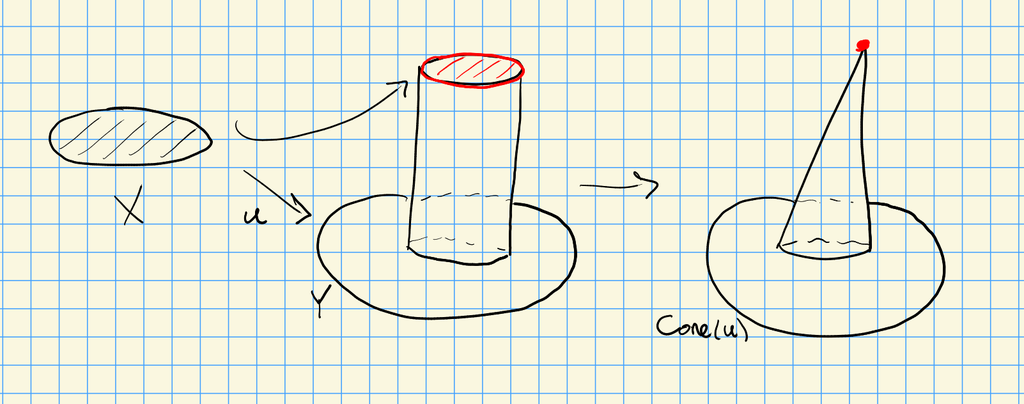

See tilting of complexes, exceptional sequences.

# 41 Monday, April 25

## 41.1 Triangulated categories

A **triangulated category** is an additive category $\mathsf{C}\in{\mathsf{Add}}\mathsf{Cat}$ with an additive autoequivalence $T: \mathsf{C}\to \mathsf{C}$ and a set of distinguished triangles $X\to Y\to Z\to TX$ satisfying

- **TR1**:
  - $X \xrightarrow{\operatorname{id}} X \to 0 \to TX$ is distinguished,
  - Any triangle isomorphic to a distinguished triangle is again distinguished,
  - For every $X \xrightarrow{u} Y$ there is a distinguished triangle $X \xrightarrow{u} Y \to Z\to X[1]$. Idea: $Z\approx Y/X$.
- **TR2**:
  - For every $X\to Y\to Z\to X[1]$, there is a triangle $Y\to Z\to X[1] \xrightarrow{Tu} Y[1]$.
- **TR3**:
  - Given 3 triangles
    $$\begin{align*}
    X&\to Y\to Z'\to
    Y&\to Z\to X'\to
    X&\to Z\to Y'\to
    \end{align*}
    there is a triangle \(Z'\to Y'\to X'\) making the relevant octahedral diagram commute.$$

[figure not shown]

> Link to Diagram

This can equivalently be expressed as a braid lemma:

[figure not shown]

> Link to Diagram

Equivalently, a 3x3 lemma holds:

[figure not shown]

> Link to Diagram

For $\mathsf{A}\in{\mathsf{Ab}}\mathsf{Cat}, \mathbf{D} {\mathsf{A}} \in {\mathsf{triang}}\mathsf{Cat}$.

For $f\in \mathsf{Ch}\mathsf{A}(X, Y)$, there is a *cone* complex ${ \mathrm{Cone} }(f) = TX \oplus Y$ with differential $d_{{ \mathrm{Cone} }(f) } = { \begin{bmatrix} {d_{X[1]}} & {0} \\ {f[1]} & {d_Y} \end{bmatrix} }$ and a *cylinder* complex ${ \mathrm{Cyl} }(f)$:

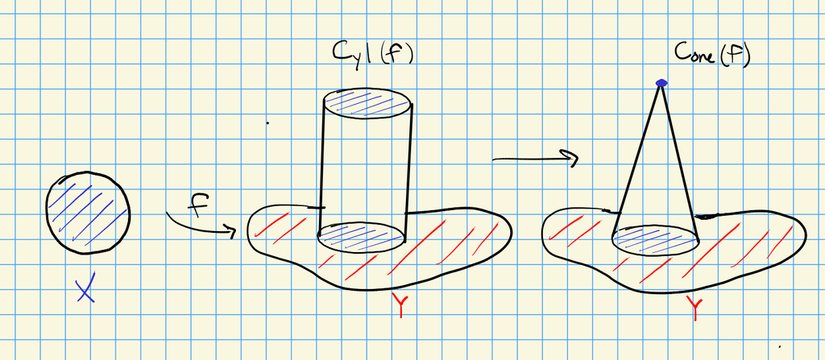

Note that $d_{{ \mathrm{Cone} }(f)} {\left[ {x_{i+1}, y_i} \right]} = {\left[ {-d_X x_{i+1}, f(x_{i+1}) + d_Y(y_i)} \right]}$, and one can check $d^2=0$.

Any distinguished triangle $X \xrightarrow{f} Y \to Z\to X[1]$ in $\mathbf{D} {\mathsf{A}}$ is isomorphic to a triangle of the form $X\to { \mathrm{Cyl} }(f) \to { \mathrm{Cone} }(f)\to X[1]$. For $\mathsf{Ch}\mathsf{A}$, define $T^nA \mathrel{\vcenter{:}}= A[n]$, so $(T^nA)_k = A[n]_k = A_{n+k}$, and ${{\partial}}_{TA} \mathrel{\vcenter{:}}=(-1)^n {{\partial}}_A$.

# 42 Wednesday, April 27

## 42.1 Cohomological Functors

Recall that for $X \xrightarrow{f} Y$, $\operatorname{cone}(f) \approx X[1] \oplus Y$ and ${ \mathrm{Cyl} }(f) \approx X \oplus X[1] \oplus Y$ with differential
$$\begin{align*}
d_{{ \mathrm{Cyl} }(f)} \mathrel{\vcenter{:}}=
\begin{bmatrix}
d_X & -1 &
\\
& d_X[1] &
\\
& f[1] & d_Y
\end{bmatrix}
\curvearrowright{\left[ {x_i, x_{i+1}, y_i} \right]} \in { \mathrm{Cyl} }(f)^i
.\end{align*}$$

> Note: I use $\approx$ above because these formulas hold levelwise, but the SESs they fit into may not be split exact, so $\operatorname{cone}(f), { \mathrm{Cyl} }(f)$ may not such direct sums.

There are related exact triples, here the first and second rows:

[figure not shown]

> Link to Diagram

Here $\beta\alpha = \operatorname{id}_Y$ and $\alpha\beta \simeq\operatorname{id}_{{ \mathrm{Cyl} }(f)}$.

A functor $H\in [\mathsf{C}, \mathsf{A}]$ with $\mathsf{C}\in {\mathsf{triang}}\mathsf{Cat}, \mathsf{A}\in {\mathsf{Ab}}\mathsf{Cat}$ (where $\mathsf{A}$ is not necessarily related to $\mathsf{C}$) is a **cohomological functor** iff every distinguished triangle $A\to B\to C\in \mathsf{C}$ is sent to an exact sequence $HA\to HB\to HC\in \mathsf{A}$.

If $H$ is cohomological, there is an associated LES
$$\begin{align*}
\cdots \to HA \to HB\to HC \to H(A[1]) \to H(B[1]) \to \cdots
.\end{align*}$$

The functor $H: \mathbf{D} {A} \to A$ where $X\mapsto H^0(X)$ is cohomological, noting that $H^i(X)$ can be written as $H^0(X[i])$.

$$\begin{align*}
\operatorname{Ext} ^i(X, Y) \mathrel{\vcenter{:}}=\mathop{\mathrm{Hom}}_{\mathsf{C}}(X, Y[1])
.\end{align*}$$

$$\begin{align*}
\operatorname{Ext} _{\mathsf{A}}^i(X, Y) \cong \operatorname{Ext} _{\mathbf{D} {\mathsf{A}} }(\iota X, \iota Y)
\end{align*}
where \(\iota: \mathsf{A} \to \mathsf{Ch}\mathsf{A}\) is given by \(\iota(A) = \cdots \to 0\to A\to 0 \to\cdots\) supported in degree zero.$$

For all $\mathsf{C}\in{\mathsf{triang}}\mathsf{Cat}$, for all $X,Y\in \mathsf{C}$ the (co)representable hom functors are cohomological:
$$\begin{align*}
h_Y &\mathrel{\vcenter{:}}=\mathop{\mathrm{Hom}}_{\mathsf{C}}({-}, Y) \qquad\text{covariant} \\
({-})^X &\mathrel{\vcenter{:}}=\mathop{\mathrm{Hom}}_{\mathsf{C}}(X, {-}) \qquad\text{contravariant}
.\end{align*}$$

The proof uses the octahedral axiom TR3. To show that applying homs yields a complex, show that the maps on homs square to zero using the following:

[figure not shown]

> Link to Diagram

## 42.2 Exceptional Collections

For $\mathsf{C}\in {\mathsf{triang}}\mathsf{Cat}$, an **exceptional collection/sequence** is a chain of morphisms
$$\begin{align*}
{\mathcal{E}}_1\to {\mathcal{E}}_2 \to\cdots\to {\mathcal{E}}_n \in \mathsf{C}
\end{align*}$$

such that

1. Self-Exts are supported only in degree zero, i.e. $\mathop{\mathrm{Hom}}({\mathcal{E}}_i, {\mathcal{E}}_i[k]) = 0$ for $k\neq 0$.
2. There are no homs in the opposite direction, i.e. $\mathop{\mathrm{Hom}}({\mathcal{E}}_j, {\mathcal{E}}_i[m]) = 0$ for $j > i$ and for any $m$.

From a paper of Valery’s: let $X$ be a smooth projective surface with $H^1({\mathcal{O}}_X) = H^2({\mathcal{O}}_X) = 0$, which cohomologically look like rational surfaces. Examples: $X$ rational with ${\left\lvert {n K_X} \right\rvert} = \emptyset$ (so “negative” canonical class), or $X$ of general type with $q=p_g=0$ and ${\left\lvert {n K_X} \right\rvert}$ big for $n \gg 0$. In these cases, there are line bundles ${\mathcal{E}}$ with $\operatorname{Ext} ^i({\mathcal{E}}, {\mathcal{E}}) = H^1({\mathcal{O}}, {\mathcal{O}}) = H^i({\mathcal{O}}_X)$ and one can use that $\operatorname{Ext} ({\mathcal{E}}_i, {\mathcal{E}}_j) = H^i({\mathcal{E}}_i \otimes{\mathcal{E}}_j^{-1})$.

If $\mathsf{C}' \leq \mathsf{C}$ is the full subcategory generated by ${\mathcal{E}}_1,\cdots, {\mathcal{E}}_n$, then $\mathsf{C}' \simeq\mathbf{D}^b (Q)$ for $Q$ a quiver. In particular, if $\left\{{{\mathcal{E}}_i}\right\}$ is a full exceptional collection, $\mathsf{C} = \mathsf{C}'$.

# 43 Friday, April 29

## 43.1 Applications of derived categories

Some major work in this area:

- Beilinson-Gelfand-Gelfand (BGG)
- Bendel-Kapranov
- Mukai
- Bendal-Orlov
- Orlov
- Kutznatsov
- Kontsevich, Fukaya (homological mirror symmetry)
- Beilinson-Bernstein-Gabber-Deligne on perverse sheaves
- Bridgeland

Results:

- BGG: $\mathbf{D}^b ({\mathsf{Coh}}{\mathbb{P}}^n) \cong \mathbf{D}^b ({\mathsf{R}{\hbox{-}}\mathsf{Mod}})$ for $R$ a certain ring.
- BK, K: same for quadrics and grassmannians.

Example: for ${\mathbb{P}}^1$, one obtains the following quiver:

[figure not shown]

> [Link to Diagram](https://q.uiver.app/?q=WzAsNCxbMCwxLCJcXE9PIl0sWzIsMSwiXFxPTygxKSJdLFswLDAsIlxcQ0MiXSxbMiwwLCJcXENDIl0sWzAsMSwiXFxDQ1xcb3BsdXMgXFxDQyIsMix7Im9mZnNldCI6M31dLFswLDEsIiIsMix7Im9mZnNldCI6LTN9XV0=)

If $X\in{\mathsf{Alg}}{\mathsf{Var}}_{/ {k}}$ admits a full exceptional collection, then the following also admit a full exceptional collection:

- Any ${\mathbb{P}}^n{\hbox{-}}$bundle $Y = {\mathbb{P}}(V) \to X$, and
- Any blowup $Y = \operatorname{Bl}_Z X$ for $Z$ a smooth subvariety.

Any rational smooth projective surface admits a full exceptional collection, by running the MMP.

Given a smooth surface admitting a full exceptional collection, is it rational? For a threefold, is it a blowup of something rational?

Given $\mathsf{T}\in {\mathsf{triang}}\mathsf{Cat}$ and $A\leq \mathsf{T}$ a full triangulated subcategory, one can define two subcategories ${}^\perp A$ and $A^\perp$:
$$\begin{align*}
A^\perp = \left\{{F {~\mathrel{\Big\vert}~}\mathop{\mathrm{Hom}}(F, A) = 1}\right\}
.\end{align*}$$

For $\mathsf{C} \in {\mathsf{triang}}\mathsf{Cat}$, one can take ${\operatorname{HH}}\mathsf{C}$. For $\mathsf{C} = \mathbf{D} (X)$, the ${\operatorname{HH}}_0 D(X) \cong {\mathbb{Z}}^n \oplus A$ as a group, for $A$ some finite torsion group. If one has a full exceptional collection, then $A = {\operatorname{HH}}_0( \left\langle{{\mathcal{E}}_1, \cdots, {\mathcal{E}}_n}\right\rangle^\perp )$. As a corollary, the length $m$ of an exceptional collection satisfies $m\leq \operatorname{rank}_{\mathbb{Z}}{\operatorname{HH}}_0 \mathbf{D} (X)$.

If $\left\{{{\mathcal{E}}_1,\cdots, {\mathcal{E}}_n}\right\}$ is an exceptional collection and $n = \operatorname{rank}_{\mathbb{Z}}{\operatorname{HH}}_0 \mathbf{D} (X)$, then this is a *full* exceptional collection.

For surfaces of general type, a special Godeaux surface produces a counterexample. There is a much easier counterexample coming from a Burnist (?) surface – generally fake ${\mathbb{P}}^2$, fake Fanos, etc. See A-Orlov, Orlov-Gorheaise, Katgerov-?, ??

Phantoms: categories with zero ${\operatorname{HH}}$, so no full exceptional collections.

## 43.2 Well-known classical results

If $X\in {\mathsf{sm}}\mathop{\mathrm{proj}}{\mathsf{Var}}$ where either $K_X$ or $-K_X$ is ample, then $X$ can be recovered from $\mathbf{D} (X)$.

Having $-K_X$ ample yields **Fano** varieties, and $K_X$ ample yields **general-type** surfaces.

If $A \in {\mathsf{Ab}}{\mathsf{Var}}$, then $\mathbf{D} (A) \cong \mathbf{D} (A {}^{ \vee })$. Such pairs are referred to as **Mukai partners**.

How to construct the equivalence $\mathbf{D} (A) \to \mathbf{D} (A {}^{ \vee })$: take the Fourier-Mukai transform. Use the Poincare bundle $P_A \to A\times A {}^{ \vee }$, and construct the functor as a push-pull over the span $(A \leftarrow_{p_1} A\times A {}^{ \vee }\to_{p_2} A {}^{ \vee })$, so
$$\begin{align*}
{\mathcal{F}}\mapsto (p_2)_* \qty{ (p_1)^* {\mathcal{F}}\otimes P_A) }
.\end{align*}$$

The next in line: K3 surfaces. An easy example: take Kummer surfaces, so $A\to A/\pm 1$ and then blow up the 16 nodes.

# 44 Monday, May 02

## 44.1 Calabi-Yau Categories

Recall that a collection ${\mathcal{E}}_i$ is *exceptional* iff $[{\mathcal{E}}_j, {\mathcal{E}}_i[n]] = 0$ if $n\geq0$ and $j > i$. If there exists a full exceptional collection, $\mathbf{D} {X} \cong \mathbf{D} {(} {\mathsf{R}{\hbox{-}}\mathsf{Mod}})$ for some $R$. Recall that a variety is *Fano* if $-K_X$ is ample.

Do full exceptional collections exist for Fano $n{\hbox{-}}$folds for $n=3$ or $4$?

Typically no.

Let
$$\begin{align*}
X_3 \mathrel{\vcenter{:}}= V(f_3(x_0,\cdots, x_5)) \subseteq {\mathbb{P}}^5
,\end{align*}
then which \(X_3\) are rational? Note that \(K_{X_3} = {\mathcal{O}}(-6+3) = {\mathcal{O}}(-3)\). Kuznatsov shows that \(H^i({\mathcal{O}}_X) = {\mathbb{C}}[0]\) and \(\operatorname{Ext} ^i({\mathcal{L}}, {\mathcal{L}}) = H^i({\mathcal{O}}_X)\). One could look for exceptional collections of line bundles, so \(\operatorname{Ext} ^i({\mathcal{L}}_j, {\mathcal{L}}_i) = H^m({\mathcal{L}}_i \otimes{\mathcal{L}}_j^{-1}) = 0\) for all \(m\). On \({\mathbb{P}}^n\), take \({\mathcal{O}}(-k)\) for \(1\leq k\leq n\) since \(K_{{\mathbb{P}}^n} = {\mathcal{O}}(-n-1)\). For \(X_3\), there is enough vanishing that \({\mathcal{O}}, {\mathcal{O}}(1), {\mathcal{O}}(2)\) are exceptional (everything below the index 3 from above). Kuznatsov shows that the “Kuznatsov component” \(K = \left\langle{{\mathcal{O}}, {\mathcal{O}}(1), {\mathcal{O}}(2)}\right\rangle^\perp\) is a Calabi-Yau category of dimension 2.$$

If $Y$ is a Calabi-Yau variety of dimension $n$, so $K_Y = 0$, there is a Serre functor
$$\begin{align*}
S: \mathbf{D}^b (Y) &\to \mathbf{D}^b (Y) \\
F &\mapsto F\otimes\omega_Y[n]
.\end{align*}
Then (probably) \(S = T^n\), a shift by \(n\). A category is a Calabi-Yau category of dimension \(n\) iff$$

- It has a Serre functor
- $S = T^n$

One can also define fractional dimension using $S^q$.

$X$ is rational iff $K = \mathbf{D}^b (Y)$ for $Y\in \mathsf{K3}$.

A technique due to Clemens-Griffith for cubic threefolds. Let $X \subseteq {\mathbb{P}}^4$ be a smooth non-nodal curve. Consider the intermediate Jacobian $J_3(X)$, which is a PPAV for any smooth 3-fold. Basic operations: blowing up a point $p$ or a curve $C$, since blowing up a surface is the identity. Blowing up a point: $J_3(\operatorname{Bl}_p X) = J_3(X)$, so it doesn’t change. For a curve, $J_3(\operatorname{Bl}_C X) = J(C) \oplus J_3(X)$. As a corollary, if $X$ is rational then $J_3(X) = \bigoplus J(C_i)$ for some curves $C_i$. For non-rationality, show it’s not the Jacobian of a curve by considering the theta divisor.

For 4-folds $X$, one can now also blow up surfaces. The intermediate cohomology carries a Hodge structure. Conjecture: $X$ is rational iff its Hodge structure looks like a K3.

Older techniques for checking rationality: see log thresholds, generally birational geometry e.g. due to Manin. E.g. groups of birational automorphism for quartic 4-folds are small. See another approach due to Mumford using torsion in cohomology.

## 44.2 T-Structures and Hearts

Note that it’s possible for $\mathsf{A},\mathsf{B}\in {\mathsf{Ab}}\mathsf{Cat}$ to satisfy $\mathbf{D} {\mathsf{A}} { \, \xrightarrow{\sim}\, }\mathbf{D} {\mathsf{B}}$.

Some examples:

- In the presence of a full exceptional collection $\mathbf{D}^b ({\mathsf{Coh}}X) { \, \xrightarrow{\sim}\, }\mathbf{D}^b ({\mathsf{R}{\hbox{-}}\mathsf{Mod}})$.
- Fourier-Mukai: $\mathbf{D}^b ({\mathsf{Coh}}A) { \, \xrightarrow{\sim}\, }\mathbf{D}^b ({\mathsf{Coh}}A {}^{ \vee })$ for dual AVs.

Start with $X\in {\mathsf{Var}}_{/ {{\mathbb{C}}}}$ Hausdorff paracompact and constructible sheaves which come with stratifications into closed subsets on which they restrict to locally constant sheaves. Note that one can realize these sheaves as pullbacks from a poset associated to the stratification. There are categories $\mathsf{Const}$ and $\mathsf{Perv}$ with $\mathbf{D}^b (\mathsf{Const}) { \, \xrightarrow{\sim}\, }\mathbf{D}^b (\mathsf{Perv})$ – here perverse sheaves are complexes of constructible sheaves with support conditions $h^j( { {{\mathcal{F}}}^{\scriptscriptstyle \bullet}} ) \leq -j$ and $h^j(D { {{\mathcal{F}}}^{\scriptscriptstyle \bullet}} ) \leq -j$ for $D$ the Verdier dual; this is a category closed under duality.

On $T{\hbox{-}}$structures: write $D = \mathbf{D} {\mathsf{A}}$, then there are subcategories

- $D^{\leq n} = D^{\leq 0}[n]$, complexes such that $H^{> n} = 0$.
- $D^{\geq n} = D^{\geq 0}[n]$, complexes such that $H^{< n} = 0$.

Then $D^{\geq 0} \cap D^{\leq 0} = A$ is a category equivalent to complexes supported in degree zero, since any such bounded complex is quasi-isomorphic to such a complex. Some properties:

- $A_0\in D^{<0}$ and $A_1 \in D^{> 1}$ satisfy $[A_0, A_1] = 0$.
- For all $C\in \mathbf{D}^b (\mathsf{A})$, there exists $A_0\to C\to A_1 \to A_0[1]$.

Note that there is a canonical truncation
$$\begin{align*}
\tau_{\leq 0}(\cdots \to C^{-1}\xrightarrow{d^0} C^0\to C^1\to \cdots) = (\cdots\to C^{-1}\to \ker d^0 \to 0)
.\end{align*}$$

## 44.3 Bridgeland stability

Take $X$ a smooth projective curve, let $D = \mathbf{D}^b ({\mathsf{Coh}}X) = \mathbf{D}^b { {\mathsf{Bun}}\qty{\operatorname{GL}_r} }$. There is a notion of a semistable sheaf (all subsheaves have smaller slopes $\mu({\mathcal{F}}) \mathrel{\vcenter{:}}=\deg {\mathcal{F}}/\operatorname{rank}{\mathcal{F}}$) and an HN filtration where the quotients are semistable and the slopes decrease. Bridgeland observed there is a central charge
$$\begin{align*}
Z: {\mathsf{Coh}}X &\to {\mathbb{C}}\\
{\mathcal{F}}&\mapsto -\deg {\mathcal{F}}+ i \operatorname{rank}{\mathcal{F}}
,\end{align*}
which can be used to recovered the heart \(\mathsf{A} = {\mathsf{Coh}}X\). Idea: vary \(Z\) to get different hearts, and \(\left\{{Z_i}\right\}\) form a complex analytic variety, and one can form a new category of tilted complexes (complexes sitting in two degrees).$$

# 45 Useful Facts

## 45.1 Category Theory

- Products: a collection of maps into factors $Y\to X_i$ is the same as a map $Y\to \prod X_i$. Products are easy to map *into*. Products have projections $\prod X_i \to X_i$.
  - Products are limits.
- Coproducts: a collection of out of factors $X_i\to Y$ is the same as a map $\coprod X_i \to Y$. Coproducts are easy to map *out* of. Coproducts have injections $X_i \to \coprod X_i$.
  - Coproducts are colimits.
- If $\mathsf{C}$ has a zero object, there is a canonical map $\coprod_{i\in I} X_i \to \prod_{j\in I} X_j$ given by assembling maps $\delta_{ij}$.
- $\colim_{i\in I}({-})$ is generally not exact, but is exact if the colimit is filtered.
  - In any case, the functor of taking stalks $({-})_x: {\mathsf{Sh}}(X; {\mathsf{Ab}}{\mathsf{Grp}}) \to {\mathsf{Ab}}{\mathsf{Grp}}$ is always exact.
- Left adjoints/colimits are characterized by morphisms on $F(x)$, and right adjoints/limits by morphisms *into* it.
- Why RAPL and LAPC:
  $$\begin{align*}
  [\colim_i L(x_i), {-}] \cong \cocolim_i [L(x_i), {-}] \cong \cocolim_i [x_i, R({-})] \cong [\colim_i x_i, R({-})] = [L(\colim_i x_i), {-}]
  .\end{align*}$$
- Right-derived functors are left Kan extensions.
- Colimits are quotients of coproducts and **receive** maps from objects (i.e. they are cocones). Taking colims is right exact. Limits send maps.

## 45.2 Tor and Ext

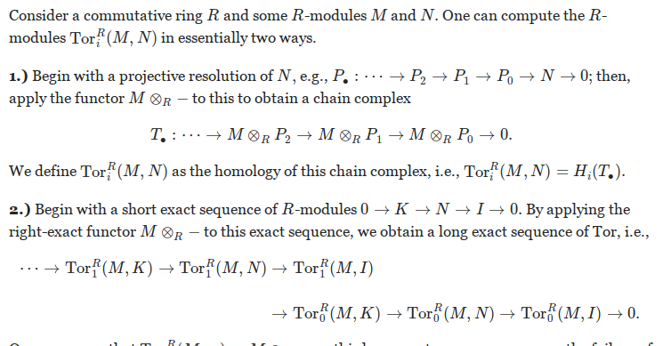

Tor:

- $\operatorname{Tor}$ commutes with arbitrary direct sums, colimits (direct limits), localization.
- If $M$ is flat over $R, \operatorname{Tor}_{i}^{R}(M \otimes A, B) \cong M \otimes_{R} \operatorname{Tor}_{i}^{R}(A, B)$.
- If $S$ is a flat $R$-algebra, $S \otimes_{R} \operatorname{Tor}_{i}^{R}(A, B) \cong \operatorname{Tor}_{i}^{S}\left(S \otimes_{R} A, S \otimes_{R} B\right)$.
- $\operatorname{Tor}_1^R(R/I, R/J) \cong {I \cap J \over IJ}$
- If $I$ is an $R{\hbox{-}}$regular sequence $I = \left\langle{x_1,\cdots, x_n}\right\rangle$, then $\operatorname{Tor}_n^R(R/I, M) = (0 :_M I)$ is a colon ideal.
- If $A\in {\mathsf{R}{\hbox{-}}\mathsf{Mod}}^\flat$ then $\operatorname{Tor}_{\geq 1}^R(A, B) = 0$.
- $\operatorname{Tor}(A, B) \cong \operatorname{Tor}(B, A)$.

# 46 Problem Set 1

## 46.1 Problem 1

Recall that:

- A topology on a set $X$ is $T_{0}$ if any two points $x, y \in X$ can be topologically distinguished (by open sets).
- A topology is an Alexandrov if an intersection of any, possibly infinite, collection of open sets is open.
- The **order topology** on a poset $(X, \leq)$ is defined in the following way: the open sets are the *upper sets*, which satisfy the property
  $$\begin{align*}
  x \in U, x \leq y \Longrightarrow y \in U
  \end{align*}
  The closed sets are lower sets, which satisfy
  \begin{align*}
  x \in Z, x \geq y \Longrightarrow y \in U
  \end{align*}$$

Prove that a topology on $X$ is an order topology $\Longleftrightarrow$ it is $T_{0}$ and Alexandrov. As a corollary conclude that any $T_{0}$ topology on a finite set is an order topology.

A topology $\tau$ on $X$ is an order topology $\Longleftrightarrow$ $\tau$ is $T_{0}$ and Alexandrov.

$\impliedby$: Suppose $X$ is a topological space and $\tau$ is a $T_0$ Alexandrov topology on $X$. For $U \subseteq X$, write ${ \operatorname{cl}} _X(U)$ for the closure in $X$ of $U$ with respect to $\tau$, define a poset $(P, \leq)$ where $P \mathrel{\vcenter{:}}= X$ with an ordering defined by
$$\begin{align*}
x\leq y \iff x\in { \operatorname{cl}} _X(y)
.\end{align*}
Regarding \(\tau\) now as a topology on \((P, \leq)\), the claim is that this is an order topology on a poset. That this ordering defines a poset is clear, since the ordering is:$$

- **Reflexive**: since $x$ is contained in its closure, $x\leq x$.
- **Antisymmetric**: if $x\leq y$ and $y\leq x$, then $x$ is a limit point of $\left\{{y}\right\}$ and vice-versa. So every neighborhood of $y$ contains $x$ and similarly every neighborhood of $x$ contains $y$. Since $X$ is $T_0$ and topologically distinguishes points, this can only occur if $x=y$.
- **Transitive**: if $x\leq y$ and $y\leq z$, then $x\in { \operatorname{cl}} _X(y)$ and $y\in { \operatorname{cl}} _X(z)$. Since ${ \operatorname{cl}} _X(z)$ is a closed set containing $y$ and ${ \operatorname{cl}} _X(y)$ is the *smallest* closed set in $X$ containing $y$, we have $x\in { \operatorname{cl}} _X(y) \subseteq { \operatorname{cl}} _X(z)$, so $x\leq z$.

$\implies$: Suppose $(X, \leq)$ is a poset with an order topology $\tau$, so $U$ is open iff whenever $x\in U$ and $x\leq y$ then $y\in U$. To see that $\tau$ defines a $T_0$ topology, let $x\neq y$ in $X$. If $x$ and $y$ are not comparable, there is nothing to show, so suppose either $x< y$ or $y< x$ – without loss of generality, relabeling if necessary, we can assume $x< y$. Now every neighborhood of $x$ contains $y$ by definition, but for example
$$\begin{align*}
U_{\geq y} \mathrel{\vcenter{:}}=\left\{{z\in X{~\mathrel{\Big\vert}~}z\geq y}\right\}
\end{align*}
is neighborhood of \(y\) not containing \(x\), topologically distinguishing \(x\) and \(y\).$$

To see that $\tau$ is Alexandrov, it suffices to show that arbitrary intersections of open sets are open. This follows from the fact that any intersection of upper sets is again an upper set – if $\left\{{ U_i}\right\}_{i\in I}$ is an arbitrary family of upper sets, set $U \mathrel{\vcenter{:}}=\cap_{i\in I} U_i$. Then if $x\in U$ with $x\leq y$, $x\in U_i$ for every $i$ and so $y\in U_i$ for every $i$, and thus $y\in U$.

If $X$ is a finite set and $\tau$ is a $T_0$ topology on $X$, then $\tau$ is an order topology.

By the exercise, it suffices to show that any finite space is Alexandrov. Let $(X, \tau)$ be a $T_0$ space and let $\left\{{U_i}\right\}_{i\in I} \subseteq \tau$ be an arbitrary collection of open sets – we’ll show $U\mathrel{\vcenter{:}}=\cap_{i\in I} U_i \in \tau$ is again open. This follows immediately, since finite intersections of open sets are open in any topology, and since $X$ is finite and $\tau \subseteq 2^X$ is finite, $I$ can only be a finite indexing set.

## 46.2 Problem 2

Recall that:

- A paracompact space is a topological space in which every open cover has an open refinement that is locally finite.
- A partition of unity of a topological space $X$ is a set $f_{\alpha}$ of continous functions $f_{\alpha}: X \rightarrow[0,1]$ such that for every point $x \in X$ there exists an open neighborhood of $x$ where all but finitely many $f_{\alpha} \equiv 0$, and such that $\sum f_{\alpha}=1$.

Prove that

- Any Hausdorff space is paracompact iff it admits a partition of unity subordinate to any open cover.
- Any metric space is paracompact.

> A sketch would suffice.

?

Metric spaces are paracompact.

Let ${\mathcal{U}}\rightrightarrows X$ be an open cover of a metric space $X$; we’ll show ${\mathcal{U}}$ admits a locally finite refinement. Without loss of generality, writing ${\mathcal{U}}= \left\{{U_j}\right\}_{j\in J}$ for some index set $J$, we can assume the $U_i$ are disjoint – this follows by invoking the axiom of choice to well-order the index set $J$ and setting \begin{align*} \tilde U_j \mathrel{\vcenter{:}}= U_j \setminus\displaystyle\bigcup_{k < j} U_k .\end{align*} Then $\tilde {\mathcal{U}}\mathrel{\vcenter{:}}=\left\{{\tilde U_j}\right\}_{j\in J}$ refines ${\mathcal{U}}$ since $\tilde U_j \subseteq U_j$, and still covers $X$. Moreover, we note that for every $x\in X$, we can now produce a *minimal* index $j(x)$ such that $x\in U_{j(x)}$.

The idea is to now refine ${\mathcal{U}}$ to a cover ${\mathcal{V}}$ by filling each disjoint annulus $U_j$ with balls of small enough radius. For ease of notation and to more clearly demonstrate the following construction, suppose $J \cong \left\{{0,1,\cdots}\right\}$ is countable. For each $n\in {\mathbb{Z}}_{\geq 0}$, let $\delta_n < {\varepsilon}_n$ be small to-be-determined real numbers depending on $n$, and define the following subsets of $X$:

$$\begin{align*}
X_{0, n} \mathrel{\vcenter{:}}=\left\{{x\in U_0 {~\mathrel{\Big\vert}~}B_{{\varepsilon}(n) }(x) \subseteq U_0 }\right\}
&&
V_{0, n} \mathrel{\vcenter{:}}=\displaystyle\bigcup_{x\in X_{0, n}} B_{\delta_n}(x) \subseteq X_{0, n} \subseteq U_0 \\
X_{1, n} \mathrel{\vcenter{:}}=\left\{{x\in U_1 {~\mathrel{\Big\vert}~}B_{{\varepsilon}(n) }(x) \subseteq U_1 }\right\} \setminus\displaystyle\bigcup_{\ell < n} V_{0, \ell}
&&
V_{1, n} \mathrel{\vcenter{:}}=\displaystyle\bigcup_{x\in X_{1, n}} B_{\delta_n}(x) \subseteq X_{1, n} \subseteq U_1 \\
X_{2, n} \mathrel{\vcenter{:}}=\left\{{x\in U_2 {~\mathrel{\Big\vert}~}B_{{\varepsilon}(n) }(x) \subseteq U_2 }\right\} \setminus\displaystyle\bigcup_{\ell < n} V_{0, \ell} \setminus\displaystyle\bigcup_{\ell < n} V_{1, n}
&&
V_{2, n} \mathrel{\vcenter{:}}=\displaystyle\bigcup_{x\in X_{2, n}} B_{\delta_n}(x) \subseteq X_{2, n} \subseteq U_2 \\
\vdots && \vdots \qquad \\
X_{j, n} \mathrel{\vcenter{:}}=\left\{{x\in U_j {~\mathrel{\Big\vert}~}B_{{\varepsilon}(n) }(x) \subseteq U_j }\right\} \setminus\displaystyle\bigcup_{k < j} \displaystyle\bigcup_{\ell < n} V_{k, \ell}
&&
V_{j, n} \mathrel{\vcenter{:}}=\displaystyle\bigcup_{x\in X_{j, n}} B_{\delta_n}(x) \subseteq X_{j, n} \subseteq U_j
.\end{align*}
Note that the last line prescribes a general formula which depends only on the ordering and not on the countability of \(J\).$$

In other words, for each fixed $j_0\in J$, we consider all of those $x\in X$ such that $j(x) = j_0$, so that for each such $x$ we have $x\in U_{j_0}$ but $x\not\in U_k$ for any $k<j_0$. For a fixed $n$, we then consider those $x\in U_{j_0}$ that are not too close to the boundary, so that a ball of radius ${\varepsilon}_n$ fits entirely in $U_{j_0}$. We then shrink these balls to a smaller radius $\delta_n$ and take their union to form an open set $V_{j_0, n}$ in the new cover, and as $n\to \infty$ these balls get smaller and fill out all of $U_{j_0}$. However, at each stage $V_{j, n}$ we remove redundancies by discarding sets $V_{k, \ell}$ for $k<j$ and $\ell < n$.

${\mathcal{V}}\mathrel{\vcenter{:}}=\left\{{V_{j, n}}\right\}_{j\in J, n\in {\mathbb{Z}}_{\geq 0}}$ is a locally finite refinement of ${\mathcal{U}}$.

There are several things that are clear from the construction:

- Each $V_{j, n}$ is open, as they are arbitrary unions of open balls in a metric space.
- ${\mathcal{V}}$ refines ${\mathcal{U}}$, since in fact $V_{j, n} \subseteq U_j$ for every $n$ and every $j$.
- ${\mathcal{V}}$ is a cover, since for any $x$ one can pick $j(x)$ minimally so that $x\in U_{j(x)}$, and since $x$ is an interior point and open balls form a basis for a metric space, for some $n$ large enough we have $x\in B_{\delta_n}(x) \subseteq V_{j(x), n}$.

So the content of this statement is that each $x\in X$ is contained in only finitely many opens from ${\mathcal{V}}$. Fix $x\in X$ and pick $j(x)$ minimally as above, so $x\in V_{j(x), n}$ for every $n$ and $j(x)$ is the first such $j$ where $x$ is added. Then $x\in B_{\delta_n}(x')$ for some $x'$ near $x$, so choose $n$ and $k$ so that $V_x \mathrel{\vcenter{:}}= B_{1\over 2^k}(x) \subset B_{\delta_n}(x) \subseteq V_{j, n}$. The claim now is that $V_x$ intersects only finitely many elements of ${\mathcal{V}}$. A proof of this follows from using the triangle inequality to show that $B_{1/2^{n+k}}(x)$ does not intersect any $V_{\beta, \ell}$ for $\ell \geq n+k$, and for $\ell < n + k$ it intersects these for at most one $\beta$, leaving only finitely many such $\ell$.

## 46.3 Problem 3

Let $A=\mathbb{Z}$ be an abelian group. Let $\mathcal{F}$ be a sheaf on $X$ such that every stalk $\mathcal{F}_{x}=A .$ Does it follow that $\mathcal{F}$ is a constant sheaf?

- Show that the answer is no in general.
- What if $X$ is an irreducible algebraic variety with Zariski topology?
- What if $X=[0,1]$ with classical topology?

There is a sheaf ${\mathcal{F}}$ on a space $X$ with stalks satisfying ${\mathcal{F}}_x = {\mathbb{C}}$ for every $x\in X$, but ${\mathcal{F}}$ is not isomorphic to the constant sheaf $\underline{{\mathbb{C}}_X}$.

Let $X = S^1$ in the Euclidean topology, $U = X\setminus\left\{{1}\right\}, Z = \left\{{1}\right\}$ and let the two inclusions be
$$\begin{align*}
j: U &\to X, \\
i: Z &\to X
.\end{align*}
Now set
\begin{align*}
{\mathcal{F}}\mathrel{\vcenter{:}}= j_! \underline{{\mathbb{C}}_U} \oplus i_* \underline{{\mathbb{C}}_Z}
\end{align*}
We can then compute the stalks:
\begin{align*}
(j_! \underline{{\mathbb{C}}_U} )_x
&= \colim_{W \ni x} (j_! \underline{{\mathbb{C}}_U} )(W) \\
&= \colim_{W \ni x}
\begin{cases}
{\mathbb{C}}& W \subseteq U
\\
0 & \text{else} .
\end{cases} \\
&= \colim
\begin{cases}
\cdots \to {\mathbb{C}}\to {\mathbb{C}}\to {\mathbb{C}}\to \cdots & x\in U
\\
0 \to 0\to 0 \to 0 \to \cdots & x\not\in U
\end{cases}\\
&=
\begin{cases}
{\mathbb{C}}& x\in U
\\
0 & x\not\in U,
\end{cases}
\\
&=
\begin{cases}
{\mathbb{C}}& x \neq \left\{{1}\right\}
\\
0 & x=\left\{{1}\right\}.
\end{cases}
\end{align*}
where we’ve used that since \(U\) is open, if \(x\in U\) then there is an open neighborhood \(W\ni x\) completely contained in \(U\), making the directed system eventually constant. Otherwise, if \(x\not\in U\), then no neighborhood of \(x\) is completely contained in \(U\), and the sections here are zero for every \(W\ni X\).$$

> Note: this uses that the colimit of an eventually constant diagram is isomorphic to whatever that constant object is, i.e. it satisfies the correct universal property.

Similarly, noting that for $W \subseteq X$,
$$\begin{align*}
i^{-1}(W) =
\begin{cases}
\left\{{1}\right\} & \left\{{1}\right\} \in W
\\
\emptyset & \left\{{1}\right\} \not\in W,
\end{cases}
\end{align*}
we have
\begin{align*}
i_* \underline{{\mathbb{C}}_Z}
&= \colim_{W\ni x} \underline{{\mathbb{C}}_Z}(i^{-1}(W)) \\
&= \colim_{W\ni x} \underline{{\mathbb{C}}_Z}\qty{
\begin{cases}
\left\{{1}\right\} & \left\{{1}\right\} \in W
\\
\emptyset & \left\{{1}\right\}\not\in W
\end{cases}
} \\
&=
\colim
\begin{cases}
{\mathbb{C}}\to {\mathbb{C}}\to \cdots & x = \left\{{1}\right\}
\\
\cdots \to 0\to 0\to \cdots & x\neq \left\{{1}\right\}
\end{cases}\\
&=
\begin{cases}
{\mathbb{C}}& x = \left\{{1}\right\}
\\
0 & x\neq \left\{{1}\right\},
\end{cases}
\end{align*}
where we’ve used that if \(U\) is open and \(x\in U\) with \(x\neq \left\{{1}\right\}\), there eventually all small enough neighborhoods \(W \ni x\) will not intersect \(X\setminus U = \left\{{1}\right\}\). Thus
\begin{align*}
{\mathcal{F}}_x =
\begin{cases}
0 \oplus {\mathbb{C}}& x = \left\{{1}\right\}
\\
{\mathbb{C}}\oplus 0 & x\neq \left\{{1}\right\},
\end{cases}
\end{align*}
and all of the stalks are one copy of \({\mathbb{C}}\), as in the constant sheaf \(\underline{{\mathbb{C}}_X}\) on \(X\). However, \({\mathcal{F}}\) and \(\underline{{\mathbb{C}}_X}\) do not have the same sections: take \(W \subseteq S^1\) to be a connected open neighborhood of \(\left\{{1}\right\}\), then
\begin{align*}
\left\{{1}\right\} \in W \implies i_* \underline{{\mathbb{C}}_Z}(W) = \underline{{\mathbb{C}}_Z}(i^{-1}(W) ) = \underline{{\mathbb{C}}_Z}(\left\{{1}\right\}) = {\mathbb{C}}
.\end{align*}
Note that \(j^{-1}(W) = W \setminus\left\{{1}\right\} = W_1 {\textstyle\coprod}W_2\) breaks into two connected components, so
\begin{align*}
j_! \underline{{\mathbb{C}}_U}(W) = \underline{{\mathbb{C}}_U}(W_1 {\textstyle\coprod}W_2) = {\mathbb{C}}{ {}^{ \scriptscriptstyle\oplus^{2} } }
,\end{align*}
so
\begin{align*}
{\mathcal{F}}(W) = {\mathbb{C}}{ {}^{ \scriptscriptstyle\oplus^{2} } } \oplus {\mathbb{C}}\neq {\mathbb{C}}= \underline{{\mathbb{C}}_X}(W) \implies {\mathcal{F}}\not\cong \underline{{\mathbb{C}}_X}
.\end{align*}$$

If $X$ is an irreducible algebraic variety or $X = [0, 1]$ in the Euclidean topology, the answer is still generally no.

The previous example shows this, noting that $S^1 \cong \operatorname{Spec}{{\mathbb{R}}[x, y] \over \left\langle{x^2 + y^2 - 1}\right\rangle}$ and $f(x, y) = x^2+y^2-1$ does not factor in ${\mathbb{R}}[x, y]$, making $S^1$ irreducible in the Zariski topology.

For $X = [0, 1]$, a modification of the previous example yields the same conclusion: set $Z = \left\{{1\over 2}\right\}$ and $U = X\setminus Z$; the same argument with the same sheaf goes through.

## 46.4 Problem 4

Let $X$ be a space with a poset topology (with increasing open sets).

- Prove that a sheaf $F$ on $X$ is the same as a collection $F_{x}$ for $x \in X$ and maps $r_{x, y}: F_{x} \rightarrow F_{y}$ for all $x \leq y$ satisfying $r_{y, z} \circ r_{x, y}=r_{x, z}$.
- Prove that for an open $U \subset X$, the set of sections $F(U)$ is $\varprojlim_{U\ni x} F_{x}$.

Let $(X, \leq)$ be a poset with the order topology, then a sheaf ${\mathcal{F}}\in {\mathsf{Sh}}(X)$ on $X$ is is equivalently a functorial assignment on the corresponding poset category
$$\begin{align*}
{\mathcal{F}}: \mathsf{Poset}(X) &\to \mathsf{C} \\
x &\mapsto {\mathcal{F}}_x
,\end{align*}
where the objects of \(\mathsf{Poset}(X)\) are elements \(x\in X\) where the hom spaces are defined as
\begin{align*}
\mathop{\mathrm{Hom}}_{\mathsf{Poset}(X)}(x, y)
\mathrel{\vcenter{:}}=
\begin{cases}
\left\{{{\operatorname{pt}}}\right\} & x\leq y
\\
\emptyset & \text{else}.
\end{cases}
\end{align*}
Here \(\mathsf{C} = {\mathsf{Ab}}{\mathsf{Grp}}, \mathsf{Ring}, {\mathsf{R}{\hbox{-}}\mathsf{Mod}}, {\mathsf{Alg}_{/k} }\), etc.$$

$\implies$: Suppose that ${\mathcal{F}}$ is a sheaf on $(X, \leq)$, and define
$$\begin{align*}
{\mathcal{G}}: \mathsf{Poset}(X) &\to \mathsf{C} \\
x &\mapsto {\mathcal{G}}_x \mathrel{\vcenter{:}}={\mathcal{F}}(U_{\geq x}) \\
(\iota_{xy}: x \to y) &\mapsto (f_{xy}: {\mathcal{G}}_x \to {\mathcal{G}}_y)
,\end{align*}
where we define \(f_{xy}\) using that
\begin{align*}
x\to y \in \mathsf{Poset}(X) \iff x\leq y \in X \implies U_{\geq y} \hookrightarrow U_{\geq x} \in {\mathsf{Open}}(X)
,\end{align*}
and since \({\mathcal{F}}\) is a contravariant functor, the latter inclusion induces an morphism
\begin{align*}
f_{xy}: {\mathcal{F}}(U_{\geq x}) \to {\mathcal{F}}(U_{\geq y}) \qquad \in \mathsf{C}
.\end{align*}
Compatibility of the \(f_{xy}\) for \({\mathcal{G}}\) follow immediately from the fact that \({\mathcal{F}}\) is a functor.$$

$\impliedby$: Given a functorial assignment
$$\begin{align*}
{\mathcal{G}}: \mathsf{Poset}(X) &\to \mathsf{C} \\
x &\mapsto {\mathcal{G}}_x
,\end{align*}
we want to construct an associated sheaf
\begin{align*}
{\mathcal{F}}: {\mathsf{Open}}(X)^{\operatorname{op}}\to \mathsf{C}
.\end{align*}
By a result from class, it suffices to specify the sheaf on a basis \({\mathcal{B}}\) for the order topology on \(X\), so let \({\mathcal{B}}\mathrel{\vcenter{:}}=\left\{{U_{\geq x}}\right\}_{x\in X}\) be the basis of up-sets. Define a presheaf by
\begin{align*}
{\mathcal{F}}^-(U_{\geq x}) \mathrel{\vcenter{:}}={\mathcal{G}}_x
,\end{align*}
and take \({\mathcal{F}}\mathrel{\vcenter{:}}=({\mathcal{F}}^-)^+\).$$

For $(X, \leq)$ a poset in the order topology, $U \subseteq X$ open, and ${\mathcal{F}}$ a sheaf on $X$,
$$\begin{align*}
F(U) \cong \varprojlim_{x\in U} {\mathcal{F}}_x
.\end{align*}$$

It suffices to show that if ${\mathcal{B}}$ is a basis for a topology, \begin{align*} {\mathcal{F}}(U) = \varprojlim_{V\in {\mathcal{B}}, V \subseteq U} {\mathcal{F}}(V) ,\end{align*} which follows because this precisely describes a continuous section of the *espace étalé* over $U \subseteq X$ as a compatible collection of sections on $U$ decomposed in a basis as $U = \cup B_i$. With this, we can then directly compute
$$\begin{align*}
{\mathcal{F}}(U)
&= \varprojlim_{V\in {\mathcal{B}}, V \subseteq U} {\mathcal{F}}(V) \\
&= \varprojlim_{V_{\geq x} \subseteq U} {\mathcal{F}}(V_{\geq x}) \qquad \text{by the definition of }{\mathcal{B}}\\
&= \varprojlim_{V_{\geq x} \subseteq U} {\mathcal{F}}_x \qquad \text{since $V_{\geq x}$ is the smallest open containing $x$}\\
&= \varprojlim_{x\in U} {\mathcal{F}}_x \qquad \text{ since } V_{\geq x} \subseteq U \implies x\in U
.\end{align*}$$

# 47 Problem Set 2

## 47.1 Problem 1

The global sections functor is left-exact.

We’ll use the fact that a sequence of sheaves is exact if and only if the induced sequence on stalks is exact. Given this, let ${\mathcal{F}}, {\mathcal{G}}, {\mathcal{H}}$ be sheaves of abelian groups on $X$, and consider the diagram induced by restriction morphisms:

[figure not shown]

> Link to Diagram

Note that we can take $U = X$ in this diagram. If the top sequence of sheaves is exact, there are isomorphisms of sheaves:

- $\ker f = 0$ and
- $\operatorname{im}f = \ker g$.

$$\begin{align*}
\ker f_X = 0
,\end{align*}
making \(f_X\) injective and yielding exactness at the first position.$$

Since the presheaf $\ker f$ is in fact a sheaf, writing $\mathbf 0$ for the sheaf $U\mapsto 0$, we have
$$\begin{align*}
\ker\qty{ {\mathcal{F}}(X) \xrightarrow{f_X} {\mathcal{G}}(X) }
= (\ker f)(X) = \mathbf{0}(X) = 0
\end{align*}$$

$$\begin{align*}
\operatorname{im}f_X = \ker g_X
,\end{align*}
yielding exactness at the middle position.$$

$\operatorname{im}f_X \subseteq \ker g_X$ follows from a diagram chase:

[figure not shown]

> Link to Diagram
- Fix $b\in \operatorname{im}f_X \subseteq {\mathcal{G}}(X)$, then by surjectivity choose a lift $a\in {\mathcal{F}}(X)$.
- Map $a$ along ${\mathcal{F}}(X)\to {\mathcal{F}}_p \to {\mathcal{G}}_p \to {\mathcal{H}}_p$; by exactness the result is zero in $C_p$.
- By commutativity of the diagram, mapping $a$ along ${\mathcal{F}}(X)\to {\mathcal{G}}(X)\to {\mathcal{H}}(X) \to {\mathcal{H}}_p$ also yields zero in $C_p$.
- Write $\tilde b \mathrel{\vcenter{:}}= g_X(b)$; since the above argument holds for all $p\in X$, $g_X(b)$ is a section of ${\mathcal{H}}$ that is zero in every stalk. Thus by the sheaf property for ${\mathcal{H}}$, the section $g_X(b)$ must be zero, and $b\in \ker g_X$.

Similarly, $\ker g_X \subseteq \operatorname{im}f_X$ follows from a diagram chase:

- Fix $b\in \ker g_X$, so the image of $g_X$ in ${\mathcal{H}}(X)$ is zero. Then its image $c_p$ along ${\mathcal{G}}(X) \to {\mathcal{H}}(X) \to {\mathcal{H}}_p$ is also zero.
- By commutativity of the right square, $g_p(b_p) = 0$ and so $b_p\in \ker g_p = \operatorname{im}f_p$ by exactness of the bottom row.
- Choose a lift $a_p\in {\mathcal{F}}_p$ along $f_p$, so $f_p(a_p) = b_p$ Since $a_p$ is a germ of ${\mathcal{F}}$, pick any global section $a\in {\mathcal{F}}(X)$ restricting to $a_p$ and making the square commute.
- Since $f_X(a)_p = f_p(a_p) = b_p$ for all $p$, by uniqueness of gluing for ${\mathcal{G}}$ we have $f_X(a) = b$ and $b\in \operatorname{im}f_X$.

Taking global sections may fail to be right-exact.

Consider the following poset and its corresponding category of open sets:

[figure not shown]

> Link to Diagram

Define the following two sheaves ${\mathcal{F}}, {\mathcal{G}}$ and a morphism between them:

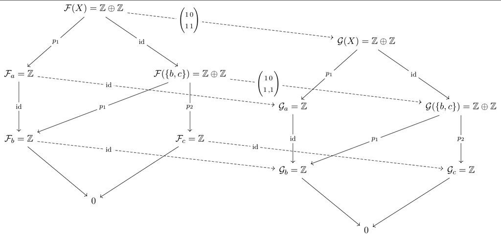

> Link to diagram

One can check that the individual diagrams for ${\mathcal{F}}$ and ${\mathcal{G}}$ commute, yielding a presheaf, and that existence and uniqueness of gluing hold for both. Moreover, all of the squares formed by the map ${\mathcal{F}}\to {\mathcal{G}}$ commute, so this does in fact yield a morphism of sheaves.

## 47.2 Problem 2

If a map $f:X\to Y$ between posets is continuous, it is order-preserving, i.e. if $x_1\leq x_2$ then $f(x_1) \leq f(x_2)$.

Continuity can be checked on a basis, so let $U_b = \left\{{y\in Y {~\mathrel{\Big\vert}~}y\geq b}\right\}$ be a basic open upper set. Then $f$ is continuous iff $f^{-1}(U_a)$ is an open set in $X$. Being open means that for every $x_0 \in f^{-1}(U_a)$, $x_1\geq x_0\implies x_1\in f^{-1}(U_a)$.
$$\begin{align*}
f \text{ is continuous }
&\iff \forall U \text{ open in } Y, \, f^{-1}(U) \text{ is open in } X \\
&\iff \forall U_a \text{ a basic open in } Y, \, f^{-1}(U_a) \text{ is open in } X \\
&\iff \forall a\in Y,\, \forall x_0 \in f^{-1}(U_a),\, x_1\geq x_0\implies x_1\in f^{-1}(U_a) \\
&\iff \forall a\in Y,\, \forall x_0 \in f^{-1}(U_a),\, x_1\geq x_0\implies f(x_1) \in U_a \\
&\iff \forall a\in Y,\, \forall x_0 \in f^{-1}(U_a),\, x_1\geq x_0\implies f(x_1) \geq a\\
&\iff \forall a\in Y,\, \forall x_0\in X \text{ s.t. } f(x_0) \geq a,\, x_1\geq x_0\implies f(x_1) \geq a
.\end{align*}
Now taking \(x_0 = f^{-1}(a)\) for \(a\in \operatorname{im}f\) yields
\begin{align*}
\implies \forall a\in \operatorname{im}f,\quad x_1 \geq f^{-1}(a) \implies f(x_1) \geq a
.\end{align*}
Relabeling \(x_1 = f^{-1}(b)\),
\begin{align*}
&\implies \forall a\in \operatorname{im}f, \quad f^{-1}(b) \geq f^{-1}(a) \implies b \geq a \\
&\implies \forall \tilde a\in f^{-1}(Y), \quad \tilde b \geq \tilde a \implies f(\tilde b) \geq f(\tilde a)
.\end{align*}$$

For ${\mathcal{F}}\in {\mathsf{Sh}}_X, {\mathcal{G}}\in {\mathsf{Sh}}_Y, {\mathcal{H}}\in {\mathsf{Sh}}_U$ with $U \subseteq X$, $X \xrightarrow{f} Y$, and $U \xhookrightarrow{j} X$,

- $f_* {\mathcal{F}}$ is no additional data
- $f^{-1}{\mathcal{G}}= \left\{{{\mathcal{G}}_{f(x_0)}, \phi_{f(x_0), f(x_1) } {~\mathrel{\Big\vert}~}x_0, x_1\in X, x_0 \leq x_1}\right\}$.
- $j_! {\mathcal{H}}= ?$

We’ll use that ${\mathcal{F}}\in {\mathsf{Sh}}(X, {\mathsf{Ab}}{\mathsf{Grp}})$ is the same as the data of $\left\{{{\mathcal{F}}_x, \phi_{xy}}\right\}$ where ${\mathcal{F}}_x$ is a collection of groups and $\phi_{xy}: {\mathcal{F}}_x\to {\mathcal{F}}_y$ are group morphisms for every $x\leq y$. Thus the values of a sheaf on posets are entirely determined by a functorial assignment of groups to the stalk at each point, i.e. an assignment of a group to each point. So it suffices to determine what the stalks of these three sheaves are.

- For $f_*{\mathcal{F}}$, noting that
  $$\begin{align*}
  (f_* {\mathcal{F}})(U_{\geq a}) = {\mathcal{F}}(f^{-1}(U_{\geq a})) = \cocolim_{x\in f^{-1}(U_{\geq a})} {\mathcal{F}}_x
  ,\end{align*}
  we see that this sheaf is completely determined by the data for \({\mathcal{F}}\).$$
- For $f^{-1}{\mathcal{G}}$, we can use the fact that for any sheaf, there is a formula on stalks:
  $$\begin{align*}
  (f^{-1}{\mathcal{G}})_p \cong {\mathcal{G}}_{f(p)}
  ,\end{align*}
  and so \(f^{-1}{\mathcal{G}}\) is the data \(\left\{{{\mathcal{G}}_x, \psi_{xy}}\right\}\) for every \(x\leq y\) with \(x,y\in \operatorname{im}f\).$$
- For $j_! {\mathcal{H}}, \cdots ?$

> Attempts to approach this: the general definition involves sheafification, which seems hard to describe in general. On the other hand, I haven’t been able to work out what the sheaf space for a poset should look like.

## 47.3 Problem 3

Let ${\mathcal{F}}\in {\mathsf{Sh}}(X)$ and let $\text{Ét}({\mathcal{F}}) \xrightarrow{\pi} X$ be its corresponding sheaf space, so ${\mathcal{F}}= \mathop{\mathrm{Sec}}_{\text{cts}}(\pi)$, and let ${\mathcal{G}}= \mathop{\mathrm{Sec}}(\pi)$. Then
$$\begin{align*}
{\mathcal{G}}= \prod_{x\in X} x_* {\mathcal{F}}_x
\end{align*}
where \(x: \left\{{x}\right\} \hookrightarrow X\) is the inclusion of a point and \({\mathcal{F}}\in {\mathsf{Sh}}(\left\{{x}\right\})\) is regarded as a sheaf on a one-point space.$$

We’ll use the fact that as a set, $\text{Ét}({\mathcal{F}}) = \coprod_{x\in X} {\mathcal{F}}_x$ is the coproduct of all of the stalks of ${\mathcal{F}}$. We can compute the sections of this sheaf as follows:
$$\begin{align*}
{\mathcal{G}}(U)
&= \qty{ \prod_{x\in X} x_* {\mathcal{F}}_x}(U) \\
&= \prod_{x\in X} (x_* {\mathcal{F}}_x)(U) \\
&= \prod_{x\in X} {\mathcal{F}}_x(x^{-1}(U)) \\
&= \prod_{x\in X} {\mathcal{F}}_x\qty{
\begin{cases}
\left\{{x}\right\} & x\in U
\\
\emptyset & x\not\in U.
\end{cases}
} \\
&= \prod_{x\in X}
\begin{cases}
{\mathcal{F}}_x & x\in U
\\
0 & x\not\in U.
\end{cases} \\
&= \prod_{x\in U} {\mathcal{F}}_x
.\end{align*}
We can now simply regard \({\mathcal{G}}(U)\) as the set of set-valued functions \(s: U\to \coprod_{x\in U} {\mathcal{F}}_x \subseteq \text{Ét}({\mathcal{F}})\) by setting \(s(x) = \pi_x\qty{\prod_{x\in U} {\mathcal{F}}_x}\) to be the \(x{\hbox{-}}\)coordinate in the direct product, where \(\pi_x: \prod_{x\in U}{\mathcal{F}}_x \to {\mathcal{F}}_x\) is projection onto the \(x{\hbox{-}}\)coordinate.$$

On the other hand, the data of a set-valued section $s \in \mathop{\mathrm{Sec}}( \text{Ét}({\mathcal{F}}) \xrightarrow{\pi} U)$ is the following: for every $x\in X$, a choice of an element
$$\begin{align*}
s(x) \in \pi^{-1}(x) = {\mathcal{F}}_x \subseteq \text{Ét}({\mathcal{F}})
,\end{align*}
with no other compatibility conditions, which is precisely the same as the set-valued functions specified by \({\mathcal{G}}(U)\) above.$$

The stalks ${\mathcal{G}}_p$ are given by
$$\begin{align*}
{\mathcal{G}}_p = \colim_{U\ni p} \prod_{x\in U} {\mathcal{F}}_x
,\end{align*}
the direct limit of the product of stalks of \({\mathcal{F}}\) along neighborhoods of \(p\).$$

$$\begin{align*}
{\mathcal{G}}_p
&\mathrel{\vcenter{:}}=\colim_{U\ni p} {\mathcal{G}}(U) \\
&\mathrel{\vcenter{:}}=\colim_{U\ni p} \qty{ \prod_{x\in X} (\iota_x)_* {\mathcal{F}}_x }(U) \\
&= \colim_{U\ni p} \prod_{x\in X} \qty{ (\iota_x)_* {\mathcal{F}}_x} (U) \\
&\mathrel{\vcenter{:}}=\colim_{U\ni p} \prod_{x\in X} {\mathcal{F}}_x(\iota_x^{-1}(U)) \\
&= \colim_{U\ni p} \prod_{x\in X} {\mathcal{F}}_x\qty{
\begin{cases}
\left\{{x}\right\} & x\in U
\\
\emptyset & \text{else}.
\end{cases}
} \\
&= \colim_{U\ni p} \prod_{x\in X} \qty{
\begin{cases}
{\mathcal{F}}_x & x\in U
\\
0 & \text{else}.
\end{cases}
} \\
&= \colim_{U\ni p} \prod_{x\in U} {\mathcal{F}}_x
.\end{align*}$$

There is an injective morphism of sheaves ${\mathcal{F}}\hookrightarrow{\mathcal{G}}$.

For every open $U \subseteq X$, define a map of sets on the function spaces:
$$\begin{align*}
\Psi_U: \mathop{\mathrm{Sec}}_{\text{cts}}(\text{Ét}({\mathcal{F}}) \xrightarrow{\pi} U) &\to \mathop{\mathrm{Sec}}(\text{Ét}({\mathcal{F}}) \xrightarrow{\pi} U) \\
f &\mapsto f
,\end{align*}
which does nothing more than a forgetful map that regards a continuous section as a set-valued section. This is evidently an injective map of sets, since if \(f_1, f_2\) are continuous sections and \(f_1 = f_2\) as set-valued functions, they continue to be equal when regarded as continuous sections, so \(\Psi_U(f_1) = \Psi_U(f_2) \implies f_1 = f_2\).$$

These $\Psi_U$ assemble to a morphism of sheaves $\Psi: {\mathcal{F}}\to {\mathcal{G}}$, and since $(\ker \Psi)^- = \mathbf{0}$ vanishes as a presheaf and the kernel presheaf is a sheaf, we have $\ker \Psi = \mathbf{0}$.

# 48 Problem Set 3

## 48.1 Problem 1

Let $I$ be an index category, $\mathcal{A}$ an abelian category, and $\mathcal{A}^{I}$ be the category of functors $F: I \rightarrow \mathcal{A}$. Prove that the functor
$$\begin{align*}
\cocolim_{i \in I}: \mathcal{A}^{I} \rightarrow \mathcal{A}, \quad F \mapsto \cocolim_{i \in I} F_{i}
\end{align*}
is left exact. (By duality, the functor \(\colim_{i \in I}\) is right exact.)$$

What is this functor in the case when $I$ is a poset and $F_{i}$ is a collection of stalks on the space $X=I$ with poset topology?

It suffices to show that $\cocolim_{i\in I}$ is a right adjoint functor, and right adjoints are left exact by general homological algebra.

There is an adjunction
$$\begin{align*}
\adjunction{\Delta}{\cocolim_{i\in I}}{\mathsf{A}}{\mathsf{A}^{\mathsf{I}}}
,\end{align*}
where \(\Delta\) is the diagonal functor:
\begin{align*}
\Delta: \mathsf{A} &\to \mathsf{A}^{\mathsf{I}} \\
X &\mapsto \Delta_X \\
(X \xrightarrow{f} Y) &\mapsto (\Delta_X \xrightarrow{\eta_f } \Delta_Y)
\end{align*}
where$$

- The constant functor $\Delta_X: \mathsf{I} \to \mathsf{C}$ is defined on objects $i\in \mathsf{I}$ as $\Delta_X(i) \mathrel{\vcenter{:}}= X$ and on morphisms $i\xrightarrow{\iota_{ij}} j$ as $\Delta_f(\iota_{ij}) = X \xrightarrow{\operatorname{id}_X} X$.
- $\eta_f$ is a natural transformation of functors with components given by $f$:

[figure not shown]

> Link to Diagram

Why this claim is true: this follows immediately from the fact that there is a natural isomorphism
$$\begin{align*}
\mathop{\mathrm{Hom}}_{\mathsf{A}}(X, \lim F) { \, \xrightarrow{\sim}\, }\mathop{\mathrm{Hom}}_{\mathsf{A}^{\mathsf{I}}}(\Delta_X, F)
,\end{align*}
i.e. maps from an object \(X\) into the limit of \(F\) are equivalent to natural transformations between the constant functor \(\Delta_X\) and \(F\). This follows from the fact that a morphism \(X\to \lim F\) in \(\mathsf{A}\) is the data of a family of compatible maps \(\left\{{f_i}\right\}_{i\in \mathsf{I}}\) over the essential image of \(F\):$$

[figure not shown]

> Link to Diagram

On the other hand, a natural transformation $\Delta_X \to F$ is precisely the same data:

[figure not shown]

> Link to Diagram

If $\mathsf{I} = {\mathsf{Open}}(X)$ where $X$ is given the order topology and $F: {\mathsf{Open}}{X} \to \mathsf{A}$ is a functor specified by stalks, $\lim$ sends $F$ to the universal object $\lim F$ living over the essential image of $F$ in $\mathsf{A}$:

[figure not shown]

> Link to Diagram

The object corresponding to global sections $F(X) \in \mathsf{A}$ seems to also satisfies this universal property, so a conjecture would be that this construction recovers $\lim F \cong F(X) \mathrel{\vcenter{:}}={{\Gamma}\qty{X; F} }$.

## 48.2 Problem 2

In the category of abelian groups compute $\operatorname{Tor}_{i}^{\mathbb{Z}}\left(\mathbb{Z}_{n}, M\right)$, the left derived functors of $N \mapsto N \otimes_{\mathbb{Z}}M$.

$$\begin{align*}
\operatorname{Tor}^{{\mathbb{Z}}}_1({\mathbb{Z}}/n{\mathbb{Z}}, M) \cong \ker(M \xrightarrow{\times n} M)
\cong \left\{{m\in M {~\mathrel{\Big\vert}~}nm = 0_M}\right\}
,\end{align*}
which is the kernel of multiplication by \(n\), and \(\operatorname{Tor}^{i>1}_{{\mathbb{Z}}}({\mathbb{Z}}/n{\mathbb{Z}}, M) = 0\).$$

Why this is true: in ${\mathsf{R}{\hbox{-}}\mathsf{Mod}}$, free implies flat, and $\operatorname{Tor}$ is balanced and can thus be resolved in either variable, so this can be computed by tensoring a free resolution of ${\mathbb{Z}}/n{\mathbb{Z}}$ and using the long exact sequence in $\operatorname{Tor}$:

[figure not shown]

> Link to Diagram

In the resulting long exact sequence, since ${\mathbb{Z}}$ is free, thus flat, thus tor-acyclic, the first two columns vanish in degrees $d\geq 1$. As a result, in degrees $d\geq 2$, the terms $\operatorname{Tor}_d^{\mathbb{Z}}({\mathbb{Z}}/n{\mathbb{Z}}, M)$ are surrounded by zeros and thus zero, meaning that only $\operatorname{Tor}_1$ survives. By exactness, $\operatorname{Tor}_1({\mathbb{Z}}/n{\mathbb{Z}}, M)$ is isomorphic to the kernel of the next map in the sequence, which is precisely $\ker(M \xrightarrow{\times n} M)$ after applying the canonical isomorphism
$$\begin{align*}
{\mathbb{Z}}\otimes_{\mathbb{Z}}M &\to M \\
n \otimes m &\mapsto nm
.\end{align*}$$

## 48.3 Problem 3

Let $k$ be a field and $R=k[x, y]$. In the category of $R$-modules compute

- $\operatorname{Ext}_R^{n}(R, m)$
- $\operatorname{Ext}_R^{n}(m, R)$, and
- $\operatorname{Tor}^R_{n}(m, m)$,

where $m=(x, y)$ is the maximal ideal at the origin.

Compute $\operatorname{Ext} _R(m, R)$ as ${\mathbb{R}}\mathop{\mathrm{Hom}}(m, {-})$ applied to $R$ proceeds similarly: using the same resolution, applying covariant $\mathop{\mathrm{Hom}}_R(m, {-})$ yields
$$\begin{align*}
0 \to \mathop{\mathrm{Hom}}_R(m, R) \to 0 \to \cdots
,\end{align*}
and taking homology yields
\begin{align*}
\operatorname{Ext} _R^0(m, R) \cong \mathop{\mathrm{Hom}}_R(m, R) \qquad \operatorname{Ext} _R^{>0}(m, R) = 0
.\end{align*}$$

For the $\operatorname{Tor}$ calculation, we can use the Koszul resolution of $m$:
$$\begin{align*}
0 \to k[x, y] \xrightarrow{\cdot {\left[ {x, y} \right]} }
k[x, y] \oplus k[x,y] \xrightarrow{ \cdot { \, {}^{t}{ \left( {\left[ {-y, x} \right]} \right) } } } \left\langle{x, y}\right\rangle \to 0
,\end{align*}
so the differentials are \(t\mapsto {\left[ {tx, ty} \right]}\) and \({\left[ {u, v} \right]} \mapsto -uy + vx\) respectively. More succinctly, this resolution is
\begin{align*}
0 \to R \xrightarrow{d_1} R{ {}^{ \scriptscriptstyle\oplus^{2} } } \xrightarrow{d_2} m \to 0
,\end{align*}
so we can delete \(m\) and apply \(({-})\otimes_R m\) to obtain
\begin{align*}
0 \to R\otimes_R m \xrightarrow{d_1 \otimes\operatorname{id}_m} R{ {}^{ \scriptscriptstyle\oplus^{2} } }\otimes_R m \to 0\\
\end{align*}
which simplifies to
\begin{align*}
{ {C}_{\scriptscriptstyle \bullet}} \mathrel{\vcenter{:}}= 0 \to m \xrightarrow{\tilde d_1 \mathrel{\vcenter{:}}={\left[ {x, y} \right]}} m \oplus m \to 0 \\
\end{align*}
and thus we can compute \(\operatorname{Tor}\) as the homology of this complex. We have
\begin{align*}
\operatorname{Tor}_0^R(m,m)&=
H^0({ {C}_{\scriptscriptstyle \bullet}} ) \\
&= \operatorname{coker}\tilde d_1 \\
&= {m \oplus m \over xm \oplus ym} \\
&\cong {m\over xm} \oplus {m\over ym} \\
&= {\left\langle{x, y}\right\rangle \over \left\langle{x^2, y}\right\rangle } \oplus {\left\langle{x, y}\right\rangle \over \left\langle{x, y^2}\right\rangle} \\
&= \left\{{f(x, y) \mathrel{\vcenter{:}}= c_1 x \in k[x,y] {~\mathrel{\Big\vert}~}c_1\in k }\right\} \oplus \left\{{g(x, y) \mathrel{\vcenter{:}}= c_1 y \in k[x,y] {~\mathrel{\Big\vert}~}c_1\in k }\right\} \\
&\cong k \oplus k
\\ \\
\operatorname{Tor}_1^R(m,m)&=
H^1({ {C}_{\scriptscriptstyle \bullet}} ) \\
&= \ker \tilde d_1 \\
&= \left\{{t\in \left\langle{x,y}\right\rangle {~\mathrel{\Big\vert}~}{\left[ {tx, ty} \right]} = {\left[ {0, 0} \right]} }\right\} \\
&= 0 \\ \\ \\
\operatorname{Tor}{\geq 2}^R(m,m)&=
H^{\geq 2} ({ {C}_{\scriptscriptstyle \bullet}} ) \\
&= 0
.\end{align*}$$

## 48.4 Problem 4

Let $0 \rightarrow F^{\prime} \rightarrow F \rightarrow F^{\prime \prime} \rightarrow 0$ be a short exact triple of sheaves and assume that $F^{\prime}$ is flasque. Prove that the sequence
$$\begin{align*}
0 \rightarrow \Gamma\left(F^{\prime}\right) \rightarrow \Gamma(F) \rightarrow \Gamma\left(F^{\prime \prime}\right) \rightarrow 0
\end{align*}
of the spaces of global sections is exact.$$

Flasque sheaves are $F{\hbox{-}}$acyclic for the functor global sections functor $F({-}) \mathrel{\vcenter{:}}={{\Gamma}\qty{X; {-}} }$.

Proved in class.

Applying the functor ${{\Gamma}\qty{X; {-}} }$ to the given short exact sequence of sheaves produces a long exact sequence of abelian groups in its right-derived functors. Using the claim above, we have ${\mathbb{R}}^i {{\Gamma}\qty{X; {\mathcal{F}}'} } = 0$ for $i\geq 1$, and thus we have the following:

[figure not shown]

> Link to Diagram

In particular, since ${\mathbb{R}}^1 {{\Gamma}\qty{X; {\mathcal{F}}'} } = 0$, the first row forms the desired short exact sequence. As a corollary, we also obtain ${\mathbb{R}}^i {{\Gamma}\qty{X; {\mathcal{F}}} } \cong {\mathbb{R}}^i {{\Gamma}\qty{X; {\mathcal{F}}''} }$ for all $i\geq 1$.

First, we’ll modify the notation slightly and give names to the maps involved. We’ll use the following convention for restrictions of sheaf morphisms to opens and stalks:

[figure not shown]

> Link to Diagram

Given $c\in C(X)$, our goal is to produce a $b\in B(X)$ such that $g(b) = c$, and the strategy will be to use surjectivity at stalks to produce a maximal section of $B$ mapping to $c$, and argue that it must be a section over all of $X$. This will proceed by showing that if a lift is not maximal, sections over open sets that are missed can be extended using that $A$ is flasque, contradicting maximality.

Write ${ \left.{{c}} \right|_{{x}} }$ for the image of $c$ in the stalk $C_x$; by surjectivity of $g_x: B_x \twoheadrightarrow C_x$ we can find a germ $b_x$ with $g_x(b_x) = c_x$. The germ lifts to some set $U\ni x$ and some $b\in B(U)$ with $b\mapsto { \left.{{c}} \right|_{{U}} }$ under ${ \left.{{F}} \right|_{{U}} }: B(U) \to C(U)$. So define a poset of all such lifts:
$$\begin{align*}
P \mathrel{\vcenter{:}}=\left\{{ (U, b \in B(U)) {~\mathrel{\Big\vert}~}{ \left.{{F}} \right|_{{U}} }(b) = { \left.{{c}} \right|_{{U}} } }\right\} \\
\qquad \text{ where } (U_1, b_1) \leq (U_2, b_2) \iff U_1 \subseteq U_2 \text{ and} { \left.{{b_2}} \right|_{{U_1}} } = b_1
.\end{align*}
As noted above, \(P\) is nonempty, and every chain \(\left\{{(U_i, b_i)}\right\}_{i\in I}\) has an upper bound given by \((\tilde U, \tilde b)\) where \(\tilde U \mathrel{\vcenter{:}}=\cup_{i\in I} U_i\) and \(\tilde b\) is the unique glued section of \(B\) restricting to all of the \(b_i\), which exists by the sheaf property for \(B\). Thus Zorn’s lemma applies, and (reusing notation) we can assume \((U, b)\) is maximal with respect to this property.$$

The claim is that $U$ must be all of $X$. Toward a contradiction, suppose not – then pick any $x\in X\setminus U$, and again using surjectivity on stalks at $x$, produce an open set $V\ni x$ and a section $b'\in B(V)$ with ${ \left.{{G}} \right|_{{V}} }(b') = { \left.{{c}} \right|_{{V}} }$. Now on the overlap $W\mathrel{\vcenter{:}}= U \cap V$, both $b$ and $b'$ map to ${ \left.{{c}} \right|_{{W}} }$, and so
$$\begin{align*}
{ \left.{{G}} \right|_{{W}} }({ \left.{{b}} \right|_{{W}} } - { \left.{{b'}} \right|_{{W}} }) = { \left.{{c}} \right|_{{W}} } { \left.{{c}} \right|_{{W}} } = 0 \implies b-b'\in \ker { \left.{{G}} \right|_{{W}} } = \operatorname{im}{ \left.{{F}} \right|_{{W}} }
,\end{align*}
where we’ve used exactness in the middle spot in the exact sequence \(A(W) \to B(W)\to C(W)\). So there is some \(\alpha \in A(W)\) with \({ \left.{{F}} \right|_{{W}} }(\alpha) = { \left.{{b}} \right|_{{W}} } - { \left.{{b'}} \right|_{{W}} }\), and since \(A\) is flasque this can be extended to a global section \(\tilde\alpha\in A(X)\). Write \(\tilde \beta \mathrel{\vcenter{:}}= F(\tilde \alpha) \in B(X)\) with \({ \left.{{\tilde \beta}} \right|_{{W}} } = { \left.{{b}} \right|_{{W}} }- { \left.{{b'}} \right|_{{W}} }\) in \(B(W)\). We can now glue \(\tilde \beta\) to a section over \(U \cup V\) which extends the original section \(b\): setting \(\widehat{b} \mathrel{\vcenter{:}}=\tilde \beta + b'\) yields
\begin{align*}
{ \left.{{\widehat{b}}} \right|_{{W}} } = \qty{{ \left.{{b}} \right|_{{W}} } - { \left.{{b'}} \right|_{{W}} }} + b' = { \left.{{b}} \right|_{{W}} }
,\end{align*}
so this section over \(U \cup V\) agrees with \(b\) on the overlap \(W = U \cap V\), and thus by existence and uniqueness of gluing (using the sheaf property of \(B\)) \(\widehat{b} \in B(U \cup V)\) is a section extending \(b\) over a set that strictly contains \(U\). This contradicts the maximality of the pair \((U, b)\).$$

## 48.5 Problem 5

For a sheaf $F$ on $X$, let
$$\begin{align*}
S(F)=\prod_{x \in X}\left(i_{x}\right)_{*} F_{x}, \quad i_{x}: x \rightarrow X
\end{align*}
be the sheaf of all, possibly discontinuous section of the étale space of \(F\). The canonical flasque resolution of \(F\) is
\begin{align*}
\underline{S}(F) \mathrel{\vcenter{:}}= 0 \rightarrow F \to S\left(F_{0}\right) \rightarrow S\left(F_{1}\right) \rightarrow S\left(F_{2}\right) \rightarrow \ldots
\end{align*}
where \(F_{0}=F\) and \(F_{i}\) are defined inductively as \(F_{i+1}=S\left(F_{i}\right) / F_{i}\). Some books define cohomology groups \(\mathbf{H}^{n}(X, F)\) as the cohomology groups of the complex
\begin{align*}
0 \rightarrow \Gamma\left(S\left(F_{0}\right)\right) \rightarrow \Gamma\left(S\left(F_{1}\right)\right) \rightarrow \Gamma\left(S\left(F_{2}\right)\right) \rightarrow \ldots
\end{align*}
Prove that they coincide with the cohomology defined by other means by showing that this gives an exact \(\delta\)-functor and that \(\mathbf{H}^{n}\) are effaceable for \(n>0\) through the following steps:$$

1. A homomorphism $F \rightarrow G$ induces a canonical homomorphism of resolutions $\underline{S}(F) \rightarrow \underline{S}(G) .$
2. A short exact triple $0 \rightarrow F^{\prime} \rightarrow F \rightarrow F^{\prime \prime} \rightarrow 0$ induces a short exact triple of complexes $0 \rightarrow \underline{S}\left(F^{\prime}\right) \rightarrow \underline{S}(F) \rightarrow \underline{S}\left(F^{\prime \prime}\right) \rightarrow 0$.
3. Applying $\Gamma$ to it gives a short exact triple of complexes, i.e. $0 \rightarrow S\left(F_{n}^{\prime}\right) \rightarrow$ $S\left(F_{n}\right) \rightarrow S\left(F_{n}^{\prime \prime}\right) \rightarrow 0$ is exact. (You can assume the previous problem.)
4. $\left(\mathbf{H}^{n}\right)$ is an exact $\delta$-functor.
5. For $n>0, \mathbf{H}^{n}(F) \rightarrow \mathbf{H}^{n}(S(F))$ is the zero map.

Conclude by Grothendieck’s universality theorem.

This follows readily from the fact that a morphism $f: F\to G$ of sheaves on $X$ induces group morphisms $f_x: F_x \to G_x$ on stalks for every $x\in X$. Letting $y\in X$ be arbitrary, there is a morphism
$$\begin{align*}
\phi_{y}: \prod_{x\in X} F_x \xrightarrow{\pi_y} F_y \xrightarrow{f_y} G_y
\end{align*}
where \(\pi_y\) is the canonical projection out of the product. By the universal property of the product, the \(\phi_y\) assemble to a morphism
\begin{align*}
S(f): \prod_{x\in X} F_x\to \prod_{y\in X} G_y
.\end{align*}$$

So there is a morphism $S(F_0) \to S(G_0)$ at the first stage of the complex. This induces a morphism on the quotient sheaves $S(F_0)/F_0 \to S(G_0)/G_0$, and thus by the same argument as above, a morphism on the second stage $S(S(F_0)/F_0) \to S(S(G_0)/G_0)$, i.e. a morphism $S(F_1) \to S(G_1)$. Continuing inductively yields levelwise morphisms $S(F_i) \to S(G_i)$. The claim is that these assemble to a chain map

[figure not shown]

> Link to Diagram

To see this is true, it is enough to show that the first square commutes, i.e. that applying $S({-})$ to a morphism of sheaves produces a commuting square. This is because every other square has a factorization as indicated, where the square in red naturally commutes since it involves canonically induced maps on quotients/cokernels, and the other half of the square arises by applying the $S$ construction to some morphism of sheaves.

However, this square can be readily seen to commute using the following: first regard the sections of ${\mathcal{F}}$ as continuous sections of its espace étale $\text{Ét}_F \xrightarrow{\pi} X$ and regarding sections of $S(F)$ as arbitrary (potentially discontinuous) sections of $\pi$. Then ${\mathcal{F}}\leq S(F)$ is clearly a subsheaf and $F\to S(F)$ is an inclusion of spaces of sections.

By part 1, it is clear there are morphisms $\underline{S}(F') \to \underline{S}(F) \to \underline{S}(F'')$ of complexes of sheaves, yielding a double complex:

[figure not shown]

> Link to Diagram

It suffices to show injectivity, exactness, and surjectivity respectively along each horizontal row. Exactness is a local condition, so it suffices to show exactness on stalks.

For any open $U$, the following sequence at the first stage of the complex is exact:
$$\begin{align*}
0\to S(F')(U) \to S(F)(U) \to S(F'')(U)\to 0
.\end{align*}$$

This follows because $S(F')(U) = \prod_{x\in U} F'_x$ and similarly for $F, F''$, and so if $f: F' \to F$ is injective on sheaves, then $f_x: F_x' \to F_x$ is injective on stalks.

Our double complex is now the following:

[figure not shown]

> Link to Diagram

To see that
$$\begin{align*}
0\to S(F_k') \to S(F_k) \to S(F_k'')\to 0
\end{align*}
is exact for all \(k\), we can truncate this complex:$$

[figure not shown]

> Link to Diagram

The row highlighted in red is exact by the Nine Lemma, regarding each row as a chain complex, and since applying $S({-})$ is exact, by applying this to the top row we obtain

[figure not shown]

> Link to Diagram

The remaining rows are exact by repeating this argument inductively, and regarding the columns as complexes, we obtain the desired exact sequences of complexes by deleting the first row.

Note: there may be a typo in the statement of this problem, so what I will show is that the following sequence of complexes is exact:
$$\begin{align*}
0
\to {{\Gamma}\qty{X; \underline{S}(F')} }
\to {{\Gamma}\qty{X; \underline{S}(F)} }
\to {{\Gamma}\qty{X; \underline{S}(F'')} }
\to 0
.\end{align*}$$

Take the double complex from part (2) and apply the functor ${{\Gamma}\qty{X; {-}} }$ to obtain the following double complex:

[figure not shown]

> Link to Diagram

Here the bottom row continues in the long exact sequence for the right-derived functors of ${{\Gamma}\qty{X; {-}} }$, i.e. sheaf cohomology. Since the desired sequence of complexes involved truncating this double complex by deleting the first row, consider everything from row two upward. That these levelwise maps assemble to a map of complexes is just a consequence of functoriality of ${{\Gamma}\qty{X;{-}} }$, and left exactness preserves the zeros in the left-most column, so it suffices to show that the right-most column (highlighted in red) is zero as claimed.

However, this follows from the previous problem if the sheaves $S(F_n')$ are all flasque. This is immediate since they are sheaves of discontinuous sections, and such a section on $U$ can always be extended to a global section by simply assigning any other values on $X\setminus U$ – any choice works, since no compatibility (e.g. continuity) is required.

It is a general theorem in homological algebra that a short exact sequence of chain complexes induces a long exact sequence in cohomology. In this case, if we take the vertical homology of the above double complex, by the snake lemma there are connecting morphisms:

[figure not shown]

> Link to Diagram

This holds because flasque sheaves are $F{\hbox{-}}$acyclic for $F({-}) = {{\Gamma}\qty{X; {-}} }$, so we can conclude that $\mathbf{H}^n(S(F)) = 0$ for $n > 0$ since the sheaves $S(F)$ are always flasque for any sheaf $F$.

> Note: I realized at the last minute that this argument may not actually work, since this $\mathbf{H}^n$ a priori has nothing to do with ${\mathbb{R}}\Gamma(X;{-})$ computed via injective resolutions.

# 49 Bibliography